# Summary Report

14 April, 2024

## Method

The systematic search was conducted on 14 April, 2024 across ClinicalTrials.Gov, ISRCTN, EudraCT, JRCT, IRCT, ANZCTR, ICTRP registries to identify registered trials with keyword(s) (Oncology OR Cancer OR Tumors). AND (Bayesian). Additionally, PubMed was searched to supplement the trial records. Further, additional trials identified from publications were queried against the registries to obtain full trial records. Trial records were systematically screened based on with variable constraint(s) on StudyType of “Interventional” .

## Results

[interactive chart not shown]

**Figure 1 PRISMA flow diagram of the clinical trial selection**

We retrieved a total of 560 records from our databases searches, including 89 trials identified from PubMed. After excluding 95 duplicate records and 221 trials from the previous review. 244 unique records were screened. Out of these, 18 records were filtered conditionally, leaving 226 for full-record evaluation. Subsequent full-record screening excluded 0 studies deemed not relevant. 226 new trials were added to the review.221 trials from the previous review were included. For this review, we found a total of 447 trials meeting the eligibility criteria (refer to Figure 1 PRISMA flow diagram).

## Discussion

**Table 1 Summary of trial characteristics of the included trials**

|  | Early Phase (N=391) | Late Phase (N=27) | Missing (N=29) | Overall (N=447) |
| --- | --- | --- | --- | --- |
| Phase |  |  |  |  |
| Early Phase 1 | 5 (1.3%) | 0 (0%) | 0 (0%) | 5 (1.1%) |
| Phase 1 | 168 (43.0%) | 0 (0%) | 0 (0%) | 168 (37.6%) |
| Phase 1/2 | 85 (21.7%) | 0 (0%) | 0 (0%) | 85 (19.0%) |
| Phase 2 | 133 (34.0%) | 0 (0%) | 0 (0%) | 133 (29.8%) |
| Phase 2/3 | 0 (0%) | 3 (11.1%) | 0 (0%) | 3 (0.7%) |
| Phase 3 | 0 (0%) | 18 (66.7%) | 0 (0%) | 18 (4.0%) |
| Phase 4 | 0 (0%) | 6 (22.2%) | 0 (0%) | 6 (1.3%) |
|  | 0 (0%) | 0 (0%) | 29 (100%) | 29 (6.5%) |
| Assignment |  |  |  |  |
|  | 15 (3.8%) | 6 (22.2%) | 5 (17.2%) | 26 (5.8%) |
| Crossover | 3 (0.8%) | 1 (3.7%) | 0 (0%) | 4 (0.9%) |
| Factorial | 1 (0.3%) | 2 (7.4%) | 3 (10.3%) | 6 (1.3%) |
| Parallel | 100 (25.6%) | 14 (51.9%) | 8 (27.6%) | 122 (27.3%) |
| Sequential | 60 (15.3%) | 2 (7.4%) | 1 (3.4%) | 63 (14.1%) |
| Single Group | 212 (54.2%) | 2 (7.4%) | 12 (41.4%) | 226 (50.6%) |
| Blinding |  |  |  |  |
|  | 8 (2.0%) | 4 (14.8%) | 4 (13.8%) | 16 (3.6%) |
| Blinded | 16 (4.1%) | 8 (29.6%) | 8 (27.6%) | 32 (7.2%) |
| Open-label | 367 (93.9%) | 15 (55.6%) | 17 (58.6%) | 399 (89.3%) |
| Randomization |  |  |  |  |
|  | 203 (51.9%) | 3 (11.1%) | 13 (44.8%) | 219 (49.0%) |
| Non-Randomized | 118 (30.2%) | 1 (3.7%) | 2 (6.9%) | 121 (27.1%) |
| Randomized | 70 (17.9%) | 23 (85.2%) | 14 (48.3%) | 107 (23.9%) |
| InterventionPurpose |  |  |  |  |
|  | 8 (2.0%) | 3 (11.1%) | 8 (27.6%) | 19 (4.3%) |
| Basic Science | 1 (0.3%) | 0 (0%) | 1 (3.4%) | 2 (0.4%) |
| Diagnostic | 2 (0.5%) | 1 (3.7%) | 2 (6.9%) | 5 (1.1%) |
| Other | 3 (0.8%) | 1 (3.7%) | 2 (6.9%) | 6 (1.3%) |
| Prevention | 3 (0.8%) | 4 (14.8%) | 1 (3.4%) | 8 (1.8%) |
| Supportive Care | 4 (1.0%) | 1 (3.7%) | 6 (20.7%) | 11 (2.5%) |
| Treatment | 370 (94.6%) | 17 (63.0%) | 8 (27.6%) | 395 (88.4%) |
| Health Services Research | 0 (0%) | 0 (0%) | 1 (3.4%) | 1 (0.2%) |
| Gender |  |  |  |  |
| Female | 21 (5.4%) | 2 (7.4%) | 3 (10.3%) | 26 (5.8%) |
| Male | 11 (2.8%) | 4 (14.8%) | 0 (0%) | 15 (3.4%) |
| Male, Female | 359 (91.8%) | 21 (77.8%) | 26 (89.7%) | 406 (90.8%) |
| AgeGroup |  |  |  |  |
|  | 302 (77.2%) | 16 (59.3%) | 14 (48.3%) | 332 (74.3%) |
| Adults | 9 (2.3%) | 1 (3.7%) | 7 (24.1%) | 17 (3.8%) |
| All ages | 11 (2.8%) | 1 (3.7%) | 0 (0%) | 12 (2.7%) |
| Child | 2 (0.5%) | 0 (0%) | 0 (0%) | 2 (0.4%) |
| Mixed | 67 (17.1%) | 9 (33.3%) | 6 (20.7%) | 82 (18.3%) |
| Elderly | 0 (0%) | 0 (0%) | 1 (3.4%) | 1 (0.2%) |
| Not Specified | 0 (0%) | 0 (0%) | 1 (3.4%) | 1 (0.2%) |
| Participant |  |  |  |  |
| Healthy volunteer | 8 (2.0%) | 1 (3.7%) | 3 (10.3%) | 12 (2.7%) |
| Patient | 383 (98.0%) | 26 (96.3%) | 22 (75.9%) | 431 (96.4%) |
| Healthy volunteer, Patient | 0 (0%) | 0 (0%) | 1 (3.4%) | 1 (0.2%) |
| Other | 0 (0%) | 0 (0%) | 2 (6.9%) | 2 (0.4%) |
| Service user | 0 (0%) | 0 (0%) | 1 (3.4%) | 1 (0.2%) |
| RecruitmentStatus |  |  |  |  |
|  | 5 (1.3%) | 4 (14.8%) | 0 (0%) | 9 (2.0%) |
| Completed | 118 (30.2%) | 13 (48.1%) | 5 (17.2%) | 136 (30.4%) |
| No longer recruiting | 59 (15.1%) | 2 (7.4%) | 8 (27.6%) | 69 (15.4%) |
| Not yet recruiting | 12 (3.1%) | 0 (0%) | 0 (0%) | 12 (2.7%) |
| Recruiting | 138 (35.3%) | 5 (18.5%) | 13 (44.8%) | 156 (34.9%) |
| Stopped | 48 (12.3%) | 2 (7.4%) | 1 (3.4%) | 51 (11.4%) |
| Suspended | 4 (1.0%) | 0 (0%) | 0 (0%) | 4 (0.9%) |
| Unknown | 7 (1.8%) | 1 (3.7%) | 2 (6.9%) | 10 (2.2%) |
| TrialDuration |  |  |  |  |
| Mean [SD] | 1640 [1130] | 2040 [2260] | 1130 [834] | 1630 [1210] |
| Median [Q25, Q75] | 1340 [834, 2150] | 1200 [929, 2430] | 1100 [557, 1280] | 1280 [826, 2110] |
| Min, Max | 0, 7920 | 183, 9500 | 144, 3380 | 0, 9500 |
| Missing | 2 (0.5%) | 2 (7.4%) | 0 (0%) | 4 (0.9%) |
| International |  |  |  |  |
| No | 307 (78.5%) | 11 (40.7%) | 23 (79.3%) | 341 (76.3%) |
| Yes | 84 (21.5%) | 16 (59.3%) | 6 (20.7%) | 106 (23.7%) |
| SponsorType |  |  |  |  |
| Commercial | 132 (33.8%) | 9 (33.3%) | 2 (6.9%) | 143 (32.0%) |
| Non-commercial | 80 (20.5%) | 5 (18.5%) | 16 (55.2%) | 101 (22.6%) |
| Non-Commercial | 2 (0.5%) | 3 (11.1%) | 0 (0%) | 5 (1.1%) |
| Other | 177 (45.3%) | 9 (33.3%) | 11 (37.9%) | 197 (44.1%) |
|  | 0 (0%) | 1 (3.7%) | 0 (0%) | 1 (0.2%) |

[1] Blinding is not included in ICTRP registry. [2] Randomization is not included in ICTRP registry. [3] InterventionPurpose is not included in JRCT, ICTRP registries. [4] Participant is not included in IRCT, ICTRP registries. [5] RecruitmentStatus is not included in ISRCTN registry. [6] TrialDuration is not included in JRCT, ICTRP registries. [7] SponsorType is not included in JRCT, IRCT, ICTRP registries. [8] ICTRP includes 18 major registries and any trial record not retrieved directly from ClinicalTrials.Gov, ISRCTN, EudraCT, JRCT, IRCT, ANZCTR, ICTRP was retrieved through ICTRP.

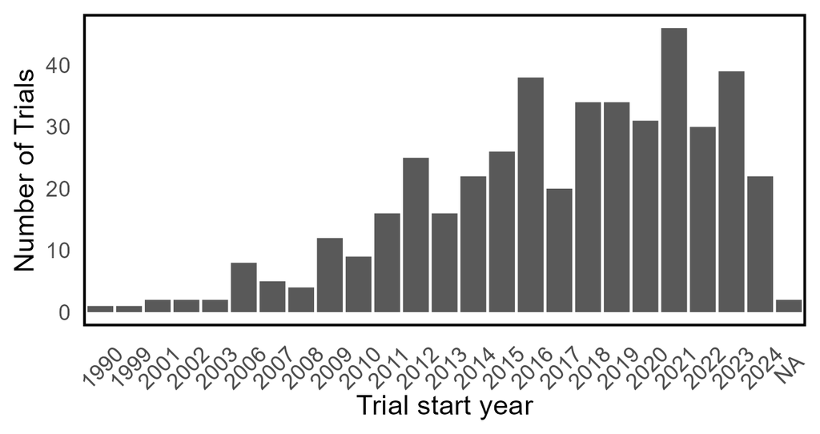

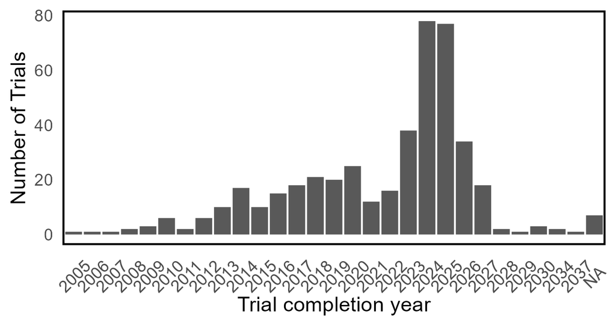

**Figure 2 a) Histogram of included clinical trials by recruitment start year, and b) by trial completion year. If an actual year is not available, the expected/target year is used.**

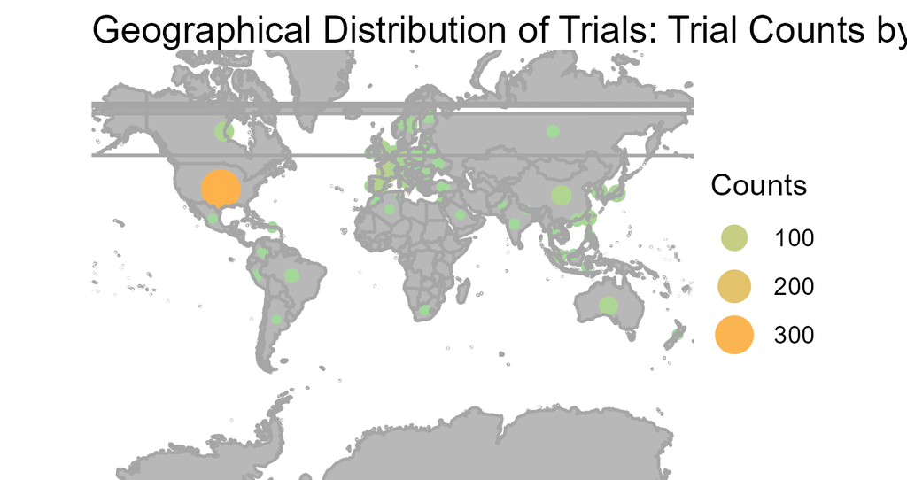

**Figure 3 Geographical distribution of the included clinical trials**

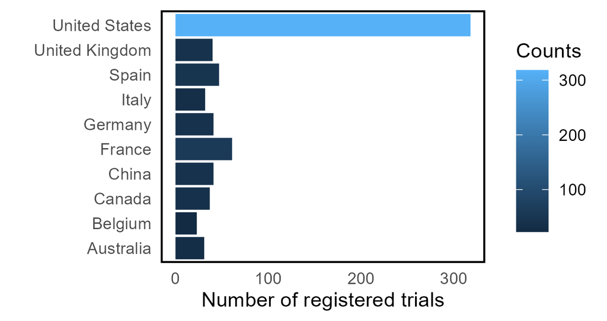

**Figure 4 Top 10 countries of the most included clinical trials**

## Appendix 1: What’s new

In this review update, 226 new trials were added to the review. The updated summary of trial characteristics is presented in Table 1. For comparison, Table A1 below outlines the corresponding information from the previous review.

**Table A1 Summary of trial characteristics from the previous review**

|  | Early Phase (N=211) | Late Phase (N=6) | Missing (N=4) | Overall (N=221) |
| --- | --- | --- | --- | --- |
| Phase |  |  |  |  |
| Early Phase 1 | 4 (1.9%) | 0 (0%) | 0 (0%) | 4 (1.8%) |
| Phase 1 | 68 (32.2%) | 0 (0%) | 0 (0%) | 68 (30.8%) |
| Phase 1/2 | 46 (21.8%) | 0 (0%) | 0 (0%) | 46 (20.8%) |
| Phase 2 | 93 (44.1%) | 0 (0%) | 0 (0%) | 93 (42.1%) |
| Phase 2/3 | 0 (0%) | 2 (33.3%) | 0 (0%) | 2 (0.9%) |
| Phase 3 | 0 (0%) | 3 (50.0%) | 0 (0%) | 3 (1.4%) |
| Phase 4 | 0 (0%) | 1 (16.7%) | 0 (0%) | 1 (0.5%) |
|  | 0 (0%) | 0 (0%) | 4 (100%) | 4 (1.8%) |
| Assignment |  |  |  |  |
|  | 5 (2.4%) | 0 (0%) | 0 (0%) | 5 (2.3%) |
| Parallel | 59 (28.0%) | 2 (33.3%) | 1 (25.0%) | 62 (28.1%) |
| Sequential | 20 (9.5%) | 1 (16.7%) | 0 (0%) | 21 (9.5%) |
| Single Group | 127 (60.2%) | 2 (33.3%) | 3 (75.0%) | 132 (59.7%) |
| Crossover | 0 (0%) | 1 (16.7%) | 0 (0%) | 1 (0.5%) |
| Blinding |  |  |  |  |
|  | 3 (1.4%) | 0 (0%) | 0 (0%) | 3 (1.4%) |
| Blinded | 5 (2.4%) | 2 (33.3%) | 0 (0%) | 7 (3.2%) |
| Open-label | 203 (96.2%) | 4 (66.7%) | 4 (100%) | 211 (95.5%) |
| Randomization |  |  |  |  |
|  | 113 (53.6%) | 2 (33.3%) | 3 (75.0%) | 118 (53.4%) |
| Non-Randomized | 65 (30.8%) | 0 (0%) | 1 (25.0%) | 66 (29.9%) |
| Randomized | 33 (15.6%) | 4 (66.7%) | 0 (0%) | 37 (16.7%) |
| InterventionPurpose |  |  |  |  |
| Diagnostic | 1 (0.5%) | 0 (0%) | 1 (25.0%) | 2 (0.9%) |
| Other | 1 (0.5%) | 0 (0%) | 1 (25.0%) | 2 (0.9%) |
| Prevention | 1 (0.5%) | 1 (16.7%) | 0 (0%) | 2 (0.9%) |
| Supportive Care | 3 (1.4%) | 0 (0%) | 0 (0%) | 3 (1.4%) |
| Treatment | 205 (97.2%) | 5 (83.3%) | 2 (50.0%) | 212 (95.9%) |
| Gender |  |  |  |  |
| Female | 11 (5.2%) | 0 (0%) | 0 (0%) | 11 (5.0%) |
| Male | 5 (2.4%) | 1 (16.7%) | 0 (0%) | 6 (2.7%) |
| Male, Female | 195 (92.4%) | 5 (83.3%) | 4 (100%) | 204 (92.3%) |
| AgeGroup |  |  |  |  |
|  | 168 (79.6%) | 4 (66.7%) | 2 (50.0%) | 174 (78.7%) |
| Adults | 4 (1.9%) | 0 (0%) | 0 (0%) | 4 (1.8%) |
| All ages | 9 (4.3%) | 0 (0%) | 0 (0%) | 9 (4.1%) |
| Mixed | 30 (14.2%) | 2 (33.3%) | 2 (50.0%) | 34 (15.4%) |
| Participant |  |  |  |  |
| Healthy volunteer | 5 (2.4%) | 0 (0%) | 0 (0%) | 5 (2.3%) |
| Patient | 206 (97.6%) | 6 (100%) | 4 (100%) | 216 (97.7%) |
| RecruitmentStatus |  |  |  |  |
| Completed | 83 (39.3%) | 4 (66.7%) | 2 (50.0%) | 89 (40.3%) |
| No longer recruiting | 43 (20.4%) | 0 (0%) | 1 (25.0%) | 44 (19.9%) |
| Recruiting | 46 (21.8%) | 2 (33.3%) | 0 (0%) | 48 (21.7%) |
| Stopped | 34 (16.1%) | 0 (0%) | 0 (0%) | 34 (15.4%) |
| Suspended | 1 (0.5%) | 0 (0%) | 0 (0%) | 1 (0.5%) |
| Unknown | 4 (1.9%) | 0 (0%) | 1 (25.0%) | 5 (2.3%) |
| TrialDuration |  |  |  |  |
| Mean [SD] | 2000 [1160] | 1540 [939] | 1190 [1400] | 1980 [1170] |
| Median [Q25, Q75] | 1830 [1170, 2600] | 1230 [851, 2500] | 659 [527, 1320] | 1830 [1140, 2580] |
| Min, Max | 0, 7920 | 560, 2580 | 183, 3270 | 0, 7920 |
| Missing | 2 (0.9%) | 1 (16.7%) | 0 (0%) | 3 (1.4%) |
| International |  |  |  |  |
| No | 163 (77.3%) | 2 (33.3%) | 4 (100%) | 169 (76.5%) |
| Yes | 48 (22.7%) | 4 (66.7%) | 0 (0%) | 52 (23.5%) |
| SponsorType |  |  |  |  |
| Commercial | 60 (28.4%) | 2 (33.3%) | 0 (0%) | 62 (28.1%) |
| Non-commercial | 31 (14.7%) | 1 (16.7%) | 1 (25.0%) | 33 (14.9%) |
| Other | 120 (56.9%) | 3 (50.0%) | 3 (75.0%) | 126 (57.0%) |

[1] Blinding is not included in ICTRP registry. [2] Randomization is not included in ICTRP registry. [3] InterventionPurpose is not included in JRCT, ICTRP registries. [4] Participant is not included in IRCT, ICTRP registries. [5] RecruitmentStatus is not included in ISRCTN registry. [6] TrialDuration is not included in JRCT, ICTRP registries. [7] SponsorType is not included in JRCT, IRCT, ICTRP registries. [8] ICTRP includes 18 major registries and any trial record not retrieved directly from ClinicalTrials.Gov, ISRCTN, EudraCT, JRCT, IRCT, ANZCTR, ICTRP was retrieved through ICTRP.

## Appendix 2: Included registered clinical trials

Trial ID

Country

Phase

Population

Intervention

Primary Outcome

Design

Operational

PubMed ID

New

NCT04774068

United States

Phase 1

Patient  
Recurrent Anaplastic Large Cell Lymphoma, Recurrent Mature T-Cell and NK-Cell Non-Hodgkin Lymphoma, Recurrent Primary Cutaneous T-Cell Non-Hodgkin Lymphoma, Recurrent Transformed Mycosis Fungoides, Refractory Anaplastic Large Cell Lymphoma, Refractory Mature T-Cell and NK-Cell Non-Hodgkin Lymphoma, Refractory Primary Cutaneous T-Cell Non-Hodgkin Lymphoma, Refractory Transformed Mycosis Fungoides, T-Cell Non-Hodgkin Lymphoma  
Male, Female

Drug: Parsaclisib(EXPERIMENTAL)  
Drug: Romidepsin(EXPERIMENTAL)

Maximum tolerated dose (MTD) of parsaclisib

Sample size: 20  
Open-label  
Single Group

Sponsor: Walter Hanel  
Trial status: Ongoing

Y

NCT04783168

United States

NA

Patient  
Lung Carcinoma  
Male, Female

Other: Best Practice(ACTIVE_COMPARATOR)  
Other: Quality-of-Life Assessment(ACTIVE_COMPARATOR)  
Other: Questionnaire Administration(ACTIVE_COMPARATOR)  
Other: Best Practice(ACTIVE_COMPARATOR)  
Other: Medical Device Usage and Evaluation(ACTIVE_COMPARATOR)  
Other: Quality-of-Life Assessment(ACTIVE_COMPARATOR)  
Other: Questionnaire Administration(ACTIVE_COMPARATOR)  
Other: Best Practice(EXPERIMENTAL)  
Other: Health Promotion and Education(EXPERIMENTAL)  
Other: Medical Device Usage and Evaluation(EXPERIMENTAL)  
Other: Quality-of-Life Assessment(EXPERIMENTAL)  
Other: Questionnaire Administration(EXPERIMENTAL)

Clavien-Dindo postoperative morbidity (POM) score

Sample size: 240  
Randomized  
Blinded  
Parallel

Sponsor: M.D. Anderson Cancer Center  
Trial status: Ongoing

Y

NCT04481204

United States

Phase 2

Patient  
Borderline Resectable Pancreatic Adenocarcinoma, Locally Advanced Pancreatic Ductal Adenocarcinoma, Resectable Pancreatic Ductal Adenocarcinoma  
Male, Female

Drug: Fluorouracil(ACTIVE_COMPARATOR)  
Drug: Irinotecan(ACTIVE_COMPARATOR)  
Drug: Leucovorin(ACTIVE_COMPARATOR)  
Drug: Oxaliplatin(ACTIVE_COMPARATOR)  
Drug: Cisplatin(ACTIVE_COMPARATOR)  
Drug: Fluorouracil(ACTIVE_COMPARATOR)  
Drug: Gemcitabine(ACTIVE_COMPARATOR)  
Drug: Irinotecan(ACTIVE_COMPARATOR)  
Drug: Leucovorin(ACTIVE_COMPARATOR)  
Drug: Nab-paclitaxel(ACTIVE_COMPARATOR)  
Drug: Oxaliplatin(ACTIVE_COMPARATOR)  
Drug: Fluorouracil(ACTIVE_COMPARATOR)  
Drug: Irinotecan(ACTIVE_COMPARATOR)  
Drug: Leucovorin(ACTIVE_COMPARATOR)  
Drug: Oxaliplatin(ACTIVE_COMPARATOR)  
Radiation: Radiation Therapy(ACTIVE_COMPARATOR)  
Drug: Cisplatin(ACTIVE_COMPARATOR)  
Drug: Fluorouracil(ACTIVE_COMPARATOR)  
Drug: Gemcitabine(ACTIVE_COMPARATOR)  
Drug: Irinotecan(ACTIVE_COMPARATOR)  
Drug: Leucovorin(ACTIVE_COMPARATOR)  
Drug: Nab-paclitaxel(ACTIVE_COMPARATOR)  
Drug: Oxaliplatin(ACTIVE_COMPARATOR)  
Radiation: Radiation Therapy(ACTIVE_COMPARATOR)  
Drug: Fluorouracil(ACTIVE_COMPARATOR)  
Drug: Irinotecan(ACTIVE_COMPARATOR)  
Drug: Leucovorin(ACTIVE_COMPARATOR)  
Drug: Oxaliplatin(ACTIVE_COMPARATOR)  
Radiation: Radiation Therapy(ACTIVE_COMPARATOR)  
Drug: Cisplatin(ACTIVE_COMPARATOR)  
Drug: Fluorouracil(ACTIVE_COMPARATOR)  
Drug: Gemcitabine(ACTIVE_COMPARATOR)  
Drug: Irinotecan(ACTIVE_COMPARATOR)  
Drug: Leucovorin(ACTIVE_COMPARATOR)  
Drug: Nab-paclitaxel(ACTIVE_COMPARATOR)  
Drug: Oxaliplatin(ACTIVE_COMPARATOR)  
Radiation: Radiation Therapy(ACTIVE_COMPARATOR)

Major pathological response rate  
Disease control rate

Sample size: 105  
Randomized  
Open-label  
Parallel

Sponsor: M.D. Anderson Cancer Center  
Trial status: Ongoing

34980020

Y

NCT06239272

United States

Phase ½

Patient  
Non-rhabdomyosarcoma, Adipocytic Neoplasm, Liposarcoma  
Male, Female

Procedure: Surgical resection(EXPERIMENTAL)  
Radiation: Proton beam radiation therapy(EXPERIMENTAL)  
Procedure: Surgical resection(EXPERIMENTAL)  
Radiation: Proton beam radiation therapy(EXPERIMENTAL)  
Procedure: Surgical resection(EXPERIMENTAL)  
Radiation: Proton beam radiation therapy(EXPERIMENTAL)  
Drug: Pazopanib(EXPERIMENTAL)  
Drug: Ifosfamide(EXPERIMENTAL)  
Drug: Doxorubicin(EXPERIMENTAL)  
Procedure: Surgical resection(EXPERIMENTAL)  
Radiation: Proton beam radiation therapy(EXPERIMENTAL)  
Drug: Pazopanib(EXPERIMENTAL)  
Drug: Ifosfamide(EXPERIMENTAL)  
Drug: Doxorubicin(EXPERIMENTAL)  
Procedure: Surgical resection(EXPERIMENTAL)  
Radiation: Proton beam radiation therapy(EXPERIMENTAL)  
Drug: Pazopanib(EXPERIMENTAL)  
Drug: Ifosfamide(EXPERIMENTAL)  
Drug: Doxorubicin(EXPERIMENTAL)  
Procedure: Surgical resection(EXPERIMENTAL)  
Radiation: Proton beam radiation therapy(EXPERIMENTAL)  
Drug: Pazopanib(EXPERIMENTAL)  
Drug: Ifosfamide(EXPERIMENTAL)  
Drug: Doxorubicin(EXPERIMENTAL)  
Drug: Selinexor(EXPERIMENTAL)

Event-free survival (EFS)  
Maximum tolerated dose (MTD) and/or the recommended phase 2 dosage (RP2D)

Sample size: 139  
Non-Randomized  
Open-label  
Factorial

Sponsor: St. Jude Children’s Research Hospital  
Trial status: Ongoing

Y

NCT04889729

Italy

NA

Patient  
Myelodysplastic Syndromes  
Male, Female

Improving MDS classification  
Prediction of probability of overall survival (months between diagnosis and death or end of follow up) for patients with MDS  
Prediction of probability of leukemia free surivival (months from diagnosis to progression to acute leukemia or end of follow up) for patients with MDS

Sample size: 13284

Sponsor: Istituto Clinico Humanitas  
Trial status: Ongoing

33539200, 24656536, 27069254, 24935723, 23065505, 16186598, 23980065, 22740453, 25721895, 24136165, 21995386, 21909114, 24030381, 22331955, 27276561, 28092685, 30304655, 8668867, 23913655, 29930011, 21998214, 24325356, 31582393, 31040863, 29858584, 24220272, 24372512, 30635634, 25139356, 27601546, 28177873

Y

NCT04573140

United States

Phase 1

Patient  
Adult Glioblastoma  
Male, Female

Biological: Autologous total tumor mRNA and pp65 full length (fl) lysosomal associated membrane protein (LAMP) mRNA loaded DOTAP liposome vaccine administered intravenously (RNA loaded lipid particles, RNA-LPs)(EXPERIMENTAL)

Manufacturing feasibility  
Safety of RNA-LP vaccine  
Determination of Maximum Tolerated Dose

Sample size: 28  
Open-label  
Single Group

Sponsor: University of Florida  
Trial status: Ongoing

34101090

Y

NCT05847569

United States

Phase 2

Patient  
Recurrent Multiple Myeloma, Refractory Multiple Myeloma  
Male, Female

Biological: Belantamab Mafodotin(ACTIVE_COMPARATOR)  
Procedure: Biospecimen Collection(ACTIVE_COMPARATOR)  
Procedure: Bone Marrow Aspirate(ACTIVE_COMPARATOR)  
Procedure: Bone Marrow Biopsy(ACTIVE_COMPARATOR)  
Procedure: Computed Tomography(ACTIVE_COMPARATOR)  
Procedure: Magnetic Resonance Imaging(ACTIVE_COMPARATOR)  
Procedure: Positron Emission Tomography(ACTIVE_COMPARATOR)  
Biological: Belantamab Mafodotin(EXPERIMENTAL)  
Procedure: Biospecimen Collection(EXPERIMENTAL)  
Procedure: Bone Marrow Aspirate(EXPERIMENTAL)  
Procedure: Bone Marrow Biopsy(EXPERIMENTAL)  
Procedure: Computed Tomography(EXPERIMENTAL)  
Procedure: Magnetic Resonance Imaging(EXPERIMENTAL)  
Procedure: Positron Emission Tomography(EXPERIMENTAL)

Grade ¾ keratopathy-free rate

Sample size: 62  
Randomized  
Open-label  
Parallel

Sponsor: Mayo Clinic  
Trial status: Ongoing

Y

NCT04521946

Phase 1

Healthy volunteer  
Anaplastic Ependymoma, Atypical Teratoid/Rhabdoid Tumor, Central Nervous System Germ Cell Tumor, Choroid Plexus Carcinoma, Intracranial Myeloid Sarcoma, Malignant Brain Neoplasm, Malignant Glioma, Medulloblastoma, Primitive Neuroectodermal Tumor, Recurrent Anaplastic Ependymoma, Recurrent Atypical Teratoid/Rhabdoid Tumor, Recurrent Malignant Brain Neoplasm, Recurrent Malignant Glioma, Recurrent Medulloblastoma, Recurrent Primitive Neuroectodermal Tumor  
Male, Female

Drug: Etoposide(EXPERIMENTAL)  
Drug: Fludarabine Phosphate(EXPERIMENTAL)  
Procedure: Hematopoietic Cell Transplantation(EXPERIMENTAL)  
Biological: Lapine T-Lymphocyte Immune Globulin(EXPERIMENTAL)  
Drug: Melphalan(EXPERIMENTAL)  
Drug: Mycophenolate Mofetil(EXPERIMENTAL)  
Drug: Tacrolimus(EXPERIMENTAL)  
Drug: Thiotepa(EXPERIMENTAL)

Transplant-related mortality  
Rate of grade III or higher organ toxicity attributable to conditioning

Sample size: 0  
Open-label  
Single Group

Sponsor: M.D. Anderson Cancer Center  
Trial status: Stopped

Y

NCT04915612

United States

Phase 1

Patient  
Acute Myeloid Leukemia Arising From Previous Myelodysplastic Syndrome, Recurrent Acute Myeloid Leukemia, Refractory Acute Myeloid Leukemia, Secondary Acute Myeloid Leukemia  
Male, Female

Drug: Gemtuzumab Ozogamicin(EXPERIMENTAL)  
Drug: Liposome-encapsulated Daunorubicin-Cytarabine(EXPERIMENTAL)

Maximum tolerated dose  
Incidence of adverse events

Sample size: 18  
Open-label  
Single Group

Sponsor: M.D. Anderson Cancer Center  
Trial status: Ongoing

Y

NCT06225804

United States  
China

Phase 1

Patient  
Non-Small Cell Lung Cancer  
Male, Female

Drug: ABSK112(EXPERIMENTAL)

Incidence of DLT  
AEs  
AESIs  
SAEs

Sample size: 164  
Open-label  
Sequential

Sponsor: Abbisko Therapeutics Co, Ltd  
Trial status: Ongoing

Y

NCT04535401

United States

Phase 1

Patient  
Advanced Colorectal Carcinoma, Advanced Digestive System Carcinoma, Advanced Gastric Carcinoma, Advanced Gastroesophageal Junction Adenocarcinoma, Clinical Stage III Gastric Cancer AJCC v8, Clinical Stage III Gastroesophageal Junction Adenocarcinoma AJCC v8, Clinical Stage IV Gastric Cancer AJCC v8, Clinical Stage IV Gastroesophageal Junction Adenocarcinoma AJCC v8, Metastatic Colorectal Carcinoma, Metastatic Digestive System Carcinoma, Metastatic Gastric Carcinoma, Metastatic Gastroesophageal Junction Adenocarcinoma, Stage III Colorectal Cancer AJCC v8, Stage IV Colorectal Cancer AJCC v8  
Male, Female

Procedure: Biopsy(EXPERIMENTAL)  
Procedure: Biospecimen Collection(EXPERIMENTAL)  
Procedure: Diagnostic Imaging(EXPERIMENTAL)  
Drug: Elimusertib(EXPERIMENTAL)  
Drug: Fluorouracil(EXPERIMENTAL)  
Drug: Irinotecan Hydrochloride(EXPERIMENTAL)  
Drug: Leucovorin Calcium(EXPERIMENTAL)

Maximum tolerated dose (MTD) of elimusertib (BAY 1895344) in combination with irinotecan, fluorouracil, and leucovorin (FOLFIRI)

Sample size: 90  
Open-label  
Single Group

Sponsor: National Cancer Institute (NCI)  
Trial status: Ongoing

Y

NCT04713046

United States

Phase ½

Patient  
HPV 16+ Recurrent or Metastatic Cancer  
Male, Female

Biological: Non-myeloablative allogeneic bone marrow transplant from related donors vaccinated against HPV16(EXPERIMENTAL)  
Biological: CD8 reduced peripheral blood cells taken from related donors vaccinated against HPV16(EXPERIMENTAL)

Safety as assessed by the National Cancer Institute (NCI) Common Terminology Criteria for Adverse Events (CTCAE) version 5.0  
Maximum Tolerated Dose (MTD) of Allogeneic CD4+ T cell Infusion

Sample size: 24  
Randomized  
Open-label  
Parallel

Sponsor: Sidney Kimmel Comprehensive Cancer Center at Johns Hopkins  
Trial status: Ongoing

Y

NCT04754672  
09150171910017  
NL7248

Netherlands

NA

Patient  
Colorectal Cancer, Chemotherapeutic Toxicity, Survivorship, Lifestyle  
Male, Female

Behavioral: Continuous aerobic and resistance exercise intervention(EXPERIMENTAL)  
Behavioral: Continuous aerobic and aerobic interval exercise intervention(EXPERIMENTAL)  
NA(NO_INTERVENTION)

Chemotherapy dose modifications  
Progression free survival

Sample size: 228  
Randomized  
Open-label  
Parallel

Sponsor: Radboud University Medical Center  
Trial status: Ongoing

Y

NCT05975944

China

Phase ½

Patient  
Extensive-stage Small Cell Lung Cancer  
Male, Female  
Age group: Mixed

Drug: Selinexor，Olaparib(EXPERIMENTAL)

MTD  
ORR

Sample size: 49  
Open-label  
Single Group

Sponsor: Tianjin Medical University Cancer Institute and Hospital  
Trial status: Ongoing

33493586

Y

NCT06076291

China

Phase 1

Patient  
Advanced Solid Tumors  
Male, Female

Drug: SG1827(EXPERIMENTAL)

Incidence of Treatment-Emergent Adverse Events  
MTD/MAD/ RP2D

Sample size: 122  
Open-label  
Single Group

Sponsor: Hangzhou Sumgen Biotech Co., Ltd.  
Trial status: Ongoing

Y

NCT05691491

United States

Phase ½

Patient  
Advanced Malignant Solid Neoplasm, Advanced Microsatellite Stable Colorectal Carcinoma, Hematopoietic and Lymphatic System Neoplasm, Metastatic Malignant Solid Neoplasm, Metastatic Microsatellite Stable Colorectal Carcinoma, Stage III Colorectal Cancer AJCC v8, Stage IV Colorectal Cancer AJCC v8  
Male, Female

Procedure: Biopsy(EXPERIMENTAL)  
Procedure: Biospecimen Collection(EXPERIMENTAL)  
Procedure: Computed Tomography(EXPERIMENTAL)  
Procedure: Magnetic Resonance Imaging(EXPERIMENTAL)  
Drug: Temozolomide(EXPERIMENTAL)  
Drug: Tuvusertib(EXPERIMENTAL)

Dose limiting toxicity and the maximum tolerated dose

Sample size: 58  
Open-label  
Sequential

Sponsor: National Cancer Institute (NCI)  
Trial status: Ongoing

Y

NCT05477576

United States  
Belgium  
Brazil  
Canada  
France  
Netherlands  
Spain

Phase 3

Patient  
GEP-NET, Gastroenteropancreatic Neuroendocrine Tumor, Gastroenteropancreatic Neuroendocrine Tumor Disease, Neuroendocrine Tumors, Carcinoid, Carcinoid Tumor, Pancreatic NET  
Male, Female

Drug: RYZ101(EXPERIMENTAL)  
Drug: RYZ101(ACTIVE_COMPARATOR)  
Drug: Everolimus 10 mg(ACTIVE_COMPARATOR)  
Drug: Sunitinib 37.5 MG(ACTIVE_COMPARATOR)  
Drug: Octreotide LAR 60 MG Injection(ACTIVE_COMPARATOR)  
Drug: Lanreotide 120Mg Sa Susp Inj Syringe(ACTIVE_COMPARATOR)

Phase 1b: RP3D  
Phase 3: PFS as determined by BICR

Sample size: 288  
Randomized  
Open-label  
Parallel

Sponsor: RayzeBio, Inc.  
Trial status: Ongoing

Y

NCT04751929

United States

Phase 2

Patient  
Prostate Cancer, Metastatic Castration-resistant Prostate Cancer  
Male

Drug: Abemaciclib(EXPERIMENTAL)  
Drug: Abemaciclib(EXPERIMENTAL)  
Drug: Atezolizumab(EXPERIMENTAL)  
Drug: Atezolizumab(EXPERIMENTAL)  
Drug: Abemaciclib(EXPERIMENTAL)  
Drug: Atezolizumab(EXPERIMENTAL)

6-month Progression free survival (PFS) rate  
Objective response rate (ORR)  
Rate of Dose Limiting Toxicity (DLT)  
Rate of Adverse Events

Sample size: 75  
Randomized  
Open-label  
Parallel

Sponsor: Dana-Farber Cancer Institute  
Trial status: Ongoing

Y

NCT05169944

United States

Phase 1

Patient  
Brain Cancer, Malignant Brain Tumor, Recurrent Brain Tumor, Progressive Malignant Brain Tumor, Brain Tumor, Pediatric, Brain Tumor Adult  
Male, Female

Drug: Magrolimab(EXPERIMENTAL)

Recommended Phase 2 Dose (RP2D)  
Proportion of participants with treatment-emergent adverse events

Sample size: 24  
Open-label  
Single Group

Sponsor: University of California, San Francisco  
Trial status: Suspended

Y

NCT05411094

United States  
Canada

Phase 1

Patient  
Locally Advanced Pancreatic Carcinoma, Stage II Pancreatic Cancer AJCC v8, Stage III Pancreatic Cancer AJCC v8, Unresectable Pancreatic Carcinoma  
Male, Female

Procedure: Biopsy(EXPERIMENTAL)  
Procedure: Biospecimen Collection(EXPERIMENTAL)  
Procedure: Diagnostic Imaging(EXPERIMENTAL)  
Biological: Durvalumab(EXPERIMENTAL)  
Drug: Olaparib(EXPERIMENTAL)  
Radiation: Radiation Therapy(EXPERIMENTAL)

Dose-limiting toxicities (DLTs) for olaparib in combination with durvalumab and radiation

Sample size: 18  
Open-label  
Single Group

Sponsor: National Cancer Institute (NCI)  
Trial status: Suspended

Y

NCT01119560

United States  
Canada

NA

Healthy volunteer  
Neuroblastoma  
Male, Female

Other: Cytology Specimen Collection Procedure  
Other: Laboratory Biomarker Analysis  
Other: Questionnaire Administration

Genetic polymorphisms involved in folate, vitamin A, and related metabolic and transport pathways with the risk of neuroblastoma (NB)  
Gene-exposure interactions, with primary interest on folate, vitamin A, and choline intake, on the risk of NB  
Gene-environment interactions  
Genetic effects within NB subgroups defined by age at diagnosis and a Children?s Oncology group classification schema based on age, MYCN oncogene status, histology, and deoxyribonucleic acid (DNA) ploidy

Sample size: 576

Sponsor: Children’s Oncology Group  
Trial status: Completed

Y

NCT05707676

China

Phase 1

Patient  
Solid Tumor  
Male, Female  
Age group: Mixed

Drug: LB4330(EXPERIMENTAL)  
Drug: LB4330(EXPERIMENTAL)

MTD/RP2D  
DLT occurrence and frequency (dose escalation phase)  
AE, SAE occurrence and frequency (according to NCI CTCAE 5.0)

Sample size: 66  
Non-Randomized  
Open-label  
Sequential

Sponsor: L & L biopharma Co., Ltd., Shanghai China  
Trial status: Ongoing

Y

NCT06217094

Phase 1

Patient  
Hepatocellular Carcinoma  
Male, Female  
Age group: Mixed

Drug: NP-101(EXPERIMENTAL)

Maximum tolerated dose

Sample size: 18  
Open-label  
Sequential

Sponsor: University of Florida  
Trial status: Ongoing

Y

NCT05422794

United States

Phase 1

Patient  
Anatomic Stage III Breast Cancer AJCC v8, Anatomic Stage IV Breast Cancer AJCC v8, Locally Advanced Triple-Negative Breast Carcinoma, Metastatic Triple-Negative Breast Carcinoma, Unresectable Triple-Negative Breast Carcinoma  
Male, Female

Drug: BET Bromodomain Inhibitor ZEN-3694(EXPERIMENTAL)  
Procedure: Biospecimen Collection(EXPERIMENTAL)  
Procedure: Computed Tomography(EXPERIMENTAL)  
Procedure: Magnetic Resonance Imaging(EXPERIMENTAL)  
Drug: Nab-paclitaxel(EXPERIMENTAL)  
Biological: Pembrolizumab(EXPERIMENTAL)  
Drug: BET Bromodomain Inhibitor ZEN-3694(EXPERIMENTAL)  
Procedure: Biopsy(EXPERIMENTAL)  
Procedure: Biospecimen Collection(EXPERIMENTAL)  
Procedure: Computed Tomography(EXPERIMENTAL)  
Procedure: Magnetic Resonance Imaging(EXPERIMENTAL)  
Drug: Nab-paclitaxel(EXPERIMENTAL)  
Biological: Pembrolizumab(EXPERIMENTAL)

Maximum tolerated dose (MTD) of ZEN003694 (ZEN-3694) used in combination with pembrolizumab and nab-paclitaxel  
Recommended phase 2 dose (RP2D) of ZEN003694 (ZEN-3694) used in combination with pembrolizumab and nab-paclitaxel  
Incidence of adverse events

Sample size: 57  
Non-Randomized  
Open-label  
Sequential

Sponsor: National Cancer Institute (NCI)  
Trial status: Ongoing

Y

NCT04301362

Portugal

NA

Patient  
Cancer, Thromboembolism, Thrombosis, Biomarkers  
Male, Female

Occurrence of symptomatic or incidental VTE

Sample size: 600

Sponsor: Centro Hospitalar de Vila Nova de Gaia/Espinho, E.P.E.  
Trial status: Unknown

Y

NCT05687682

Taiwan

Phase 1

Patient  
Advanced Solid Tumor  
Male, Female

Biological: AM-928(EXPERIMENTAL)  
Biological: AM-928(EXPERIMENTAL)  
Biological: AM-928(EXPERIMENTAL)  
Biological: AM-928(EXPERIMENTAL)  
Biological: AM-928(EXPERIMENTAL)  
Biological: AM-928(EXPERIMENTAL)  
Biological: AM-928(EXPERIMENTAL)

The maximum tolerated dose (MTD)  
The incidence of dose-limiting toxicity (DLT)

Sample size: 38  
Non-Randomized  
Open-label  
Sequential

Sponsor: AcadeMab Biomedical Inc.  
Trial status: Ongoing

Y

NCT04666220

Italy

NA

Patient  
Renal Cell Carcinoma, Adrenal Carcinoma  
Male, Female

Other: VETC evaluation  
Other: VETC evaluation

VETC in RCC and AC.

Sample size: 180

Sponsor: Humanitas Clinical and Research Center  
Trial status: Unknown

19487818, 21512545, 25711742, 21593862, 31206715, 30506570, 18712609, 22626276, 28120493, 24321522, 24768112, 17215529, 30347044, 20100962, NULL, NULL, NULL, NULL, 36568334, NULL, NULL, NULL, NULL, NULL, NULL, NULL, NULL, NULL, NULL, 19826129, 15681528, NULL, 12459628, 25794004, 12368197, 19442788

Y

NCT05209074

United States

Phase 1

Patient  
Pancreatic Ductal Adenocarcinoma, Resectable Pancreatic Cancer  
Male, Female  
Age group: Mixed

Drug: Ivosidenib(EXPERIMENTAL)  
Drug: mFOLFIRINOX(EXPERIMENTAL)

Maximum-tolerated dose (MTD) or Recommended Phase 2 dose (RP2D)

Sample size: 16  
Open-label  
Single Group

Sponsor: Case Comprehensive Cancer Center  
Trial status: Ongoing

Y

NCT04883957

China

Phase 1

Patient  
Mature B-cell Malignancies  
Male, Female

Drug: BGB-11417(EXPERIMENTAL)  
Drug: BGB-11417(EXPERIMENTAL)  
Drug: BGB-11417(EXPERIMENTAL)

MTD Of BGB-11417 As Recommended By The Bayesian Logistic Regression Model Or The MAD  
RP2D Of BGB-11417  
Incidence And Severity Of Treatment-emergent Adverse Events, Serious Adverse Events, Adverse Events (AEs) Leading To Discontinuation, And Dose-Limiting Toxicities (DLTs)  
Incidence And Severity Of Tumor Lysis Syndrome-relevant Events

Sample size: 64  
Non-Randomized  
Open-label  
Parallel

Sponsor: BeiGene  
Trial status: Ongoing

Y

NCT06313957

China

Phase 1

Patient  
Relapsed/Refractory B-cell Non-Hodgkin Lymphoma  
Male, Female

Biological: LUCAR-20SP cells(EXPERIMENTAL)

Dose-limiting toxicity (DLT) rate  
Incidence, severity, and type of treatment-emergent adverse events (TEAEs)  
Recommended Phase 2 Dose (RP2D) regimen finding  
Pharmacokinetics in peripheral blood  
Pharmacokinetics in bone marrow

Sample size: 42  
Open-label  
Single Group

Sponsor: Peking University Cancer Hospital & Institute  
Trial status: Ongoing

Y

NCT05718882

China

NA

Patient  
Liver Cancer, Hepatocellular Carcinoma, Resistant Cancer  
Male, Female  
Age group: Mixed

Drug: Lenvatinib Oral Product Plus VIC1911(EXPERIMENTAL)

Progression free survival

Sample size: 30  
Open-label  
Single Group

Sponsor: RenJi Hospital  
Trial status: Ongoing

Y

NCT05868174

Australia

Phase 1

Patient  
Solid Tumor, Adult, Advanced Solid Tumor, Advanced Renal Cell Carcinoma  
Male, Female

Diagnostic Test: 89Zr-TLX250(EXPERIMENTAL)  
Combination Product: 177Lu-TLX250 and Peposertib(EXPERIMENTAL)

Safety parameter Dose Limited Toxicity (DLT)  
Safety parameter Laboratory Examinations  
Safety parameter Vital signs  
Safety parameter ECG  
Safety parameter Adverse Events and Treatment-Related Adverse Events  
Disease impact causing changes in Eastern Cooperative Oncology Group (ECOG) Performance scale.

Sample size: 36  
Open-label  
Sequential

Sponsor: Telix Pharmaceuticals (Innovations) Pty Limited  
Trial status: Ongoing

Y

NCT03499782

China

NA

Patient  
Cholangiocarcinoma, Gall Bladder Carcinoma, Biliary System Disorder  
Male, Female  
Age group: Mixed

Death from biliary tract carcinoma

Sample size: 10000

Sponsor: Xinhua Hospital, Shanghai Jiao Tong University School of Medicine  
Trial status: Unknown

Y

NCT04559230

United States

Phase 2

Patient  
Glioblastoma  
Male, Female

Drug: Sacituzumab Govitecan(EXPERIMENTAL)

Progression free survival

Sample size: 40  
Open-label  
Single Group

Sponsor: The University of Texas Health Science Center at San Antonio  
Trial status: Ongoing

Y

NCT04748848  
2020-005341-16

United States  
Belgium  
France  
Spain

Phase 1

Patient  
Leukemia, Myeloid  
Male, Female

Drug: CC-90011(EXPERIMENTAL)  
Drug: Venetoclax(EXPERIMENTAL)  
Drug: Azacitidine(EXPERIMENTAL)  
Drug: Azacitidine(EXPERIMENTAL)  
Drug: Venetoclax(EXPERIMENTAL)  
Drug: Venetoclax(EXPERIMENTAL)  
Drug: Azacitidine(EXPERIMENTAL)  
Drug: CC-90011(EXPERIMENTAL)

Adverse Events (AEs)  
Recommended Phase 2 dose (RP2D)

Sample size: 1  
Randomized  
Open-label  
Sequential

Sponsor: Celgene  
Trial status: Stopped

Y

NCT06198426

Australia

Phase ½

Patient  
Solid Tumor  
Male, Female  
Age group: Mixed

Drug: IBI3004(EXPERIMENTAL)

Adverse events (AEs)

Sample size: 106  
Open-label  
Sequential

Sponsor: Innovent Biologics (Suzhou) Co. Ltd.  
Trial status: Ongoing

Y

NCT05393466

Phase ½

Patient  
Non-small Cell Lung Carcinoma  
Male, Female

Drug: BPI-361175(EXPERIMENTAL)  
Drug: BPI-361175(EXPERIMENTAL)  
Drug: BPI-361175(EXPERIMENTAL)

The percentage of patients with adverse events and serious adverse events graded per National Cancer Institute Common Terminology Criteria for Adverse Events and dose limiting toxicities for BPI 361175  
Efficacy of BPI-361175

Sample size: 30  
Non-Randomized  
Open-label  
Sequential

Sponsor: Xcovery Holdings, Inc.  
Trial status: Ongoing

Y

NCT04732065

United States  
Switzerland

Phase 1

Patient  
Diffuse Midline Glioma (DMG), Glioblastoma, Recurrent Ependymoma, Recurrent Malignant Central Nervous System Neoplasm, Spinal Cord Glioma, World Health Organization (WHO) Grade III Glioma, CNS Tumor, Central Nervous System Tumor  
Male, Female  
Age group: Mixed

Drug: ONC206(EXPERIMENTAL)  
Drug: ONC206(EXPERIMENTAL)  
Radiation: Standard of Care Radiation Therapy(EXPERIMENTAL)  
Drug: ONC206(EXPERIMENTAL)  
Radiation: Standard of Care Radiation Therapy(EXPERIMENTAL)  
Drug: ONC206(EXPERIMENTAL)

Proportion of participants with dose-limiting toxicities (DLT)  
Maximum tolerated dose (MTD) of ONC206

Sample size: 256  
Non-Randomized  
Open-label  
Parallel

Sponsor: Sabine Mueller, MD, PhD  
Trial status: Ongoing

35157764

Y

NCT04588922

United States  
China

Phase ½

Patient  
Hematologic Malignancies  
Male, Female

Drug: GFH009(EXPERIMENTAL)  
Drug: GFH009(EXPERIMENTAL)  
Drug: GFH009, venetoclax, azacitidine(EXPERIMENTAL)

Safety and Tolerability of GFH009: Dose Limiting Toxicities (DLTs)  
Safety and Tolerability of GFH009: adverse events (AEs)

Sample size: 135  
Non-Randomized  
Open-label  
Sequential

Sponsor: Genfleet Therapeutics (Shanghai) Inc.  
Trial status: Ongoing

Y

NCT02324062

United States

NA

Patient  
Hereditary Breast and Ovarian Cancer  
Male, Female

Other: Questionnaires  
Other: Blood Draw and Baseline Questionnaire  
Other: Questionnaires  
Other: Blood Draw and Baseline Questionnaire  
Other: Questionnaires  
Other: Blood Draw and Baseline Questionnaire  
Other: Blood Draw and Baseline Questionnaire

Develop Hereditary Cancer panel repository

Sample size: 1511

Sponsor: University of Southern California  
Trial status: Completed

Y

NCT06194929

United States

Phase ½

Patient  
Melanoma  
Male, Female

Drug: Defactinib(EXPERIMENTAL)  
Drug: Avutometinib(EXPERIMENTAL)  
Drug: Defactinib(EXPERIMENTAL)  
Drug: Avutometinib(EXPERIMENTAL)  
Drug: Encorafenib(EXPERIMENTAL)  
Drug: Defactinib(EXPERIMENTAL)  
Drug: Avutometinib(EXPERIMENTAL)  
Drug: Encorafenib(EXPERIMENTAL)

Response rate defined as Partial Response (PR) + Complete Response (CR) using Response Assessment in Neuro-Oncology Brain Metastases (RANO-BM) criteria of all measurable target lesions present at the time of enrollment on trial.  
Frequency of dose limiting toxicities (DLTs).The frequency of adverse events (AEs) and serious adverse events (SAEs) characterized by type, severity (as defined by the NIH CTCAE, version 5.0), seriousness, duration, and relationship to study treatment.  
Response rate defined as Partial Response (PR) + Complete Response (CR) using Response Assessment in Neuro-Oncology Brain Metastases (RANO-BM) criteria of all measurable target lesions present at the time of enrollment on trial.

Sample size: 33  
Non-Randomized  
Open-label  
Parallel

Sponsor: University of Utah  
Trial status: Ongoing

Y

NCT05898373

Phase ½

Patient  
Salivary Gland Cancer  
Male, Female

Drug: vedicitumomab (Edisil, RC48）(EXPERIMENTAL)  
Drug: vedicitumomab in combination with pyrrolizidine(EXPERIMENTAL)  
Drug: RC48 in combination with a platinum-based chemotherapeutic agent(EXPERIMENTAL)  
Drug: RC48 in combination with teraplizumab(EXPERIMENTAL)

ORR

Sample size: 120  
Randomized  
Blinded  
Crossover

Sponsor: Peking Union Medical College  
Trial status: Ongoing

Y

NCT05507827

United States

Phase 1

Patient  
Lymphoid Leukemia  
Male, Female  
Age group: Mixed

Drug: Allogeneic donor-derived T-cells transduced with bivalent lentiviral vector (CD19/CD22-BBz) chimeric antigen receptor (CAR)(EXPERIMENTAL)  
Drug: Treg CD34+HSPC (Orca-T)(EXPERIMENTAL)

Number of patients who received donor CD19/CD22-CAR T cells  
Assessment of the donors safety CD19/CD22-CAR T cells plus the Orca-T graft

Sample size: 18  
Open-label  
Single Group

Sponsor: Dr. Melody Smith, MD, MS  
Trial status: Ongoing

Y

NCT00954473

United States

NA

Patient  
Localized Osteosarcoma, Metastatic Osteosarcoma, Recurrent Osteosarcoma  
Male, Female

Other: laboratory biomarker analysis

Hardy-Weinberg equilibrium on all SNPs  
SNPs associated with OS  
Gene-gene interactions  
Survival outcomes  
Whole-exome variant loci

Sample size: 1000

Sponsor: Children’s Oncology Group  
Trial status: Completed

Y

NCT05009927

France

Phase 2

Patient  
Metastatic Gastrointestinal Stromal Tumor (GIST), C-KIT Mutation, Advanced Gastrointestinal Stromal Tumor (GIST)  
Male, Female

Drug: Imatinib tablets(EXPERIMENTAL)  
NA(NO_INTERVENTION)

Progression-free-rate at 6 months (PFR 6m)

Sample size: 50  
Randomized  
Open-label  
Parallel

Sponsor: Centre Leon Berard  
Trial status: Ongoing

Y

NCT05294731

China

Phase 1

Patient  
B-cell Malignancy, Non-Hodgkin Lymphoma, Mantle Cell Lymphoma, Chronic Lymphocytic Leukemia/Small Lymphocytic Lymphoma, Waldenström Macroglobulinemia, Marginal Zone Lymphoma, Follicular Lymphoma, DLBCL Unclassifiable, Richter’s Transformation  
Male, Female

Drug: BGB-16673(EXPERIMENTAL)  
Drug: BGB-16673(EXPERIMENTAL)  
Drug: BGB-16673(EXPERIMENTAL)

Number of participants with adverse events (AEs)  
Maximum tolerated dose (MTD) of BGB-16673  
Recommended Phase 2 dose (RP2D) of BGB-16673

Sample size: 116  
Randomized  
Open-label  
Parallel

Sponsor: BeiGene  
Trial status: Ongoing

Y

NCT05394831

United States  
Korea, Republic of  
Thailand

Phase ½

Patient  
EGFR Mutant Advanced Non-small Cell Lung Cancer  
Male, Female

Drug: JIN-A02(EXPERIMENTAL)

Maximum Tolerable Dose (MTD)  
Adverse Events (AE) rate  
Serious Adverse Events (SAE) rate  
Dose Limiting Toxicity (DLT)

Sample size: 150  
Open-label  
Sequential

Sponsor: J Ints Bio  
Trial status: Ongoing

Y

NCT04293835

China

NA

Patient  
Rectal Cancer  
Male, Female

Diagnostic Test: Whether to have intestinal-related disease

the height of sigmoid take-off

Sample size: 835

Sponsor: Peking University Third Hospital  
Trial status: Completed

30973385

Y

NCT04430725

United States

NA

Patient  
Lung Non-Small Cell Carcinoma, Metastatic Colorectal Carcinoma, Metastatic Sarcoma, Stage I Lung Cancer AJCC v8, Stage IA1 Lung Cancer AJCC v8, Stage IA2 Lung Cancer AJCC v8, Stage IA3 Lung Cancer AJCC v8, Stage IB Lung Cancer AJCC v8, Stage II Lung Cancer AJCC v8, Stage IIA Lung Cancer AJCC v8, Stage IIB Lung Cancer AJCC v8, Stage III Lung Cancer AJCC v8, Stage IIIA Lung Cancer AJCC v8, Stage IIIB Lung Cancer AJCC v8, Stage IIIC Lung Cancer AJCC v8, Stage IV Colorectal Cancer AJCC v8, Stage IV Lung Cancer AJCC v8, Stage IVA Colorectal Cancer AJCC v8, Stage IVA Lung Cancer AJCC v8, Stage IVB Colorectal Cancer AJCC v8, Stage IVB Lung Cancer AJCC v8, Stage IVC Colorectal Cancer AJCC v8  
Male, Female

Procedure: Computed Tomography with Contrast  
Procedure: Microwave Ablation  
Other: Questionnaire Administration  
Procedure: Wedge Excision

Time to local recurrence per treated nodule

Sample size: 120

Sponsor: M.D. Anderson Cancer Center  
Trial status: Ongoing

Y

NCT05367076

Canada

NA

Patient  
Pediatric Brain Tumor, Cognitive Impairment  
Male, Female  
Age group: Mixed

Behavioral: Web-based Aerobic Exercise Program(EXPERIMENTAL)

Feasibility of the exercise program: The probability that 30 eligible patients will be recruited  
Feasibility of the exercise program: The probability that a recruited participant will attend ≥60% of exercise training sessions  
Feasibility of the exercise program: The probability that a recruited participant will complete all study procedures  
Feasibility of the exercise program: The probability that instructors will adhere to the web-based platform to deliver exercise training  
Feasibility of the exercise program: The probability that instructors will develop a therapeutic alliance with the participants  
Feasibility of the web-based platform: The probability that instructors will rate the platform as acceptable  
Feasibility of the web-based platform: The probability that instructors will rate the platform as relevant  
Feasibility of the web-based platform: The probability that instructors will rate the platform as efficient

Sample size: 30  
Open-label  
Single Group

Sponsor: The Hospital for Sick Children  
Trial status: Ongoing

Y

NCT04631029

United States

Phase 1

Patient  
Extensive Stage Lung Small Cell Carcinoma, Malignant Solid Neoplasm, Metastatic Malignant Neoplasm in the Brain  
Male, Female

Biological: Atezolizumab(EXPERIMENTAL)  
Drug: Carboplatin(EXPERIMENTAL)  
Drug: Entinostat(EXPERIMENTAL)  
Drug: Etoposide(EXPERIMENTAL)

Number of Participants With Dose Limiting Toxicities  
Number of Participants Experiencing Grade 3 and 4 Adverse Events  
Number of Participants Who Received 3 or More Cycles of the Combination of Entinostat, Atezolizumab, Carboplatin, and Etoposide

Sample size: 3  
Open-label  
Single Group

Sponsor: National Cancer Institute (NCI)  
Trial status: Completed

Y

NCT04697576

United States

Phase 1

Patient  
Clinical Stage I Cutaneous Melanoma AJCC v8, Clinical Stage IA Cutaneous Melanoma AJCC v8, Clinical Stage IB Cutaneous Melanoma AJCC v8, Clinical Stage II Cutaneous Melanoma AJCC v8, Clinical Stage IIA Cutaneous Melanoma AJCC v8, Clinical Stage IIB Cutaneous Melanoma AJCC v8, Clinical Stage IIC Cutaneous Melanoma AJCC v8, Clinical Stage IV Cutaneous Melanoma AJCC v8, Metastatic Melanoma  
Male, Female  
Age group: Mixed

Biological: Quadrivalent Inactivated Influenza Vaccine(EXPERIMENTAL)  
Procedure: Resection(EXPERIMENTAL)  
Biological: Ipilimumab(EXPERIMENTAL)  
Biological: Nivolumab(EXPERIMENTAL)  
Biological: Pembrolizumab(EXPERIMENTAL)  
Biological: Quadrivalent Inactivated Influenza Vaccine(EXPERIMENTAL)  
Biological: Nivolumab + Relatlimab(EXPERIMENTAL)

Incidence of adverse events (AEs)  
Maximum tolerated dose (MTD) in Cohorts #1 and #2

Sample size: 36  
Non-Randomized  
Open-label  
Parallel

Sponsor: Carlo Contreras  
Trial status: Ongoing

Y

NCT05744739

United States

Phase 1

Patient  
Acute Myeloid Leukemia  
Male, Female

Procedure: Biospecimen Collection(EXPERIMENTAL)  
Drug: Tomivosertib(EXPERIMENTAL)

Determine the dose of maximum pharmacologic activity (MPA) of tomivosertib

Sample size: 15  
Open-label  
Single Group

Sponsor: Northwestern University  
Trial status: Ongoing

Y

NCT04479696

United States

NA

Healthy volunteer  
Glioblastoma, WHO Grade II Glioma, WHO Grade III Glioma  
Male, Female

Other: Educational Intervention(EXPERIMENTAL)  
Other: Questionnaire Administration(EXPERIMENTAL)  
Other: Survey Administration(EXPERIMENTAL)  
Other: Video(EXPERIMENTAL)  
Other: Educational Intervention(ACTIVE_COMPARATOR)  
Other: Questionnaire Administration(ACTIVE_COMPARATOR)

Changes in patient S-Anxiety subscale score of the State-Trait Anxiety Inventory (STAI)

Sample size: 102  
Randomized  
Open-label  
Parallel

Sponsor: M.D. Anderson Cancer Center  
Trial status: Ongoing

Y

NCT05123534

United States

Phase 2

Patient  
Diffuse Intrinsic Pontine Glioma, Diffuse Midline Glioma  
Male, Female

Combination Product: SONALA-001 (ALA) and MR-Guided Focused Ultrasound device (MRgFUS)(EXPERIMENTAL)  
Combination Product: SONALA-001 (ALA) and MR-Guided Focused Ultrasound device (MRgFUS)(EXPERIMENTAL)  
Combination Product: SONALA-001 (ALA) and MR-Guided Focused Ultrasound device (MRgFUS)(EXPERIMENTAL)  
Combination Product: SONALA-001 (ALA) and MR-Guided Focused Ultrasound device (MRgFUS)(EXPERIMENTAL)  
Combination Product: SONALA-001 (ALA) and MR-Guided Focused Ultrasound device (MRgFUS)(EXPERIMENTAL)

To evaluate the safety and tolerability of SDT in DIPG subjects to generate data that will aid in the design of a larger Phase 2b trial.  
To determine the Maximum Tolerated Dose (MTD) or Recommended Phase 2 Dose (RP2D) of MR-Guided Focused Ultrasound (MRgFUS) energy in combination with SONALA-001 (SDT) in subjects with DIPG.

Sample size: 40  
Non-Randomized  
Open-label  
Sequential

Sponsor: SonALAsense, Inc.  
Trial status: Ongoing

Y

NCT06129734

United States

Phase ½

Patient  
Myeloid Malignancy, Acute Myeloid Leukemia  
Male, Female

Drug: Venetoclax(EXPERIMENTAL)  
Drug: Decitabine(EXPERIMENTAL)

Safety as measured by dose limiting toxicities  
Feasibility as measured by the rate of participants receiving planned treatment

Sample size: 20  
Open-label  
Single Group

Sponsor: Benjamin Tomlinson  
Trial status: Ongoing

Y

NCT05990634

Sweden

NA

Patient  
Melanoma (Skin)  
Male, Female

Device: LifeChamps Platform(EXPERIMENTAL)

Analytical models  
Usability assessment

Sample size: 20  
Open-label  
Single Group

Sponsor: Region Stockholm  
Trial status: Ongoing

Y

NCT04678921

United States

Phase 1

Patient  
Solid Tumor, Metastatic Cancer, Advanced Cancer  
Male, Female  
Age group: Mixed

Drug: TJ210001(EXPERIMENTAL)  
Drug: TJ210001(EXPERIMENTAL)  
Drug: TJ210001(EXPERIMENTAL)  
Drug: TJ210001(EXPERIMENTAL)

Incidence and Severity of Adverse Events  
Maximum Tolerated Dose

Sample size: 16  
Non-Randomized  
Open-label  
Sequential

Sponsor: I-Mab Biopharma Co. Ltd.  
Trial status: Completed

Y

NCT04879121

United States

Phase 2

Patient  
Locally Advanced Malignant Solid Neoplasm, Metastatic Malignant Solid Neoplasm  
Male, Female

Drug: Larotrectinib Sulfate(EXPERIMENTAL)

Overall response

Sample size: 13  
Open-label  
Single Group

Sponsor: M.D. Anderson Cancer Center  
Trial status: Ongoing

Y

NCT05488821

China

Phase 1

Patient  
Advanced Solid Tumors Harboring MAPK Pathway Alterations  
Male, Female

Drug: QLH11906(EXPERIMENTAL)

MTD/MAD  
RP2D

Sample size: 40  
Open-label  
Single Group

Sponsor: Qilu Pharmaceutical Co., Ltd.  
Trial status: Ongoing

Y

NCT05804864

China

Phase 1

Patient  
Advanced Solid Tumors  
Male, Female  
Age group: Mixed

Drug: KM501(EXPERIMENTAL)

Maximum tolerated dose (MTD) (for Part 1a)  
Recommended phase 2 dose (RP2D) (if has) (Part 1a)  
Number of participants with treatment-related adverse events （Part 1a）  
Objective response rate (ORR) (Part 1b)

Sample size: 96  
Open-label  
Single Group

Sponsor: Xuanzhu Biopharmaceutical Co., Ltd.  
Trial status: Ongoing

Y

NCT06268379

Australia

NA

Patient  
Colon Cancer, Model Disease  
Male, Female  
Age group: Mixed

OS  
RFS

Sample size: 2475

Sponsor: Cabrini Health  
Trial status: Completed

33538338, 32133645, 31730633, 34360026, NULL

Y

NCT04359784

United States

Phase 2

Patient  
B-Cell Non-Hodgkin Lymphoma  
Male, Female

Biological: Anakinra(EXPERIMENTAL)  
Procedure: X-Ray Imaging(EXPERIMENTAL)  
Procedure: Positron Emission Tomography(EXPERIMENTAL)  
Procedure: Computed Tomography(EXPERIMENTAL)  
Procedure: Bone Marrow Aspiration(EXPERIMENTAL)  
Procedure: Bone Marrow Biopsy(EXPERIMENTAL)  
Procedure: Lumbar Puncture(EXPERIMENTAL)  
Procedure: Biospecimen Collection(EXPERIMENTAL)

Absence of any grade cytokine release syndrome (CRS)

Sample size: 25  
Open-label  
Single Group

Sponsor: Fred Hutchinson Cancer Center  
Trial status: Ongoing

Y

NCT03096821

Austria

NA

Patient  
Relapsed Hematologic Malignancy  
Male, Female

Drug: ngFDS selected treatment

progression-free survival

Sample size: 143

Sponsor: Medical University of Vienna  
Trial status: Completed

29153976

Y

NCT05950464

United States

Phase 1

Patient  
Endometrial Carcinoma, Endometrial Clear Cell Adenocarcinoma, Endometrial Endometrioid Adenocarcinoma, Endometrial Low Grade Endometrioid Adenocarcinoma, Ovarian Clear Cell Adenocarcinoma, Ovarian Endometrioid Adenocarcinoma, Ovarian High Grade Serous Adenocarcinoma, Ovarian Low Grade Endometrioid Adenocarcinoma, Platinum-Resistant Ovarian Carcinoma  
Female

Drug: BET Bromodomain Inhibitor ZEN-3694(EXPERIMENTAL)  
Procedure: Biopsy(EXPERIMENTAL)  
Procedure: Biospecimen Collection(EXPERIMENTAL)  
Procedure: Computed Tomography(EXPERIMENTAL)  
Procedure: Electrocardiography(EXPERIMENTAL)  
Procedure: Magnetic Resonance Imaging(EXPERIMENTAL)  
Drug: Tuvusertib(EXPERIMENTAL)  
Procedure: X-Ray Imaging(EXPERIMENTAL)

Dose-limiting toxicities (DLTs) (Part I)  
DLTs (Part II)  
Measurements for gammaH2AX (PART II)  
Incidence of adverse events (Part I and II)

Sample size: 60  
Open-label  
Sequential

Sponsor: National Cancer Institute (NCI)  
Trial status: Ongoing

Y

NCT04607590

United States

NA

Healthy volunteer  
Esophageal Carcinoma, Lung Carcinoma, Malignant Head and Neck Neoplasm, Malignant Solid Neoplasm  
Male, Female

Procedure: Quality-of-Life Assessment  
Other: Questionnaire Administration  
Procedure: Yoga  
Procedure: Quality-of-Life Assessment  
Other: Questionnaire Administration  
Procedure: Yoga  
Other: Best Practice  
Procedure: Quality-of-Life Assessment  
Other: Questionnaire Administration  
Procedure: Yoga

The patient 6-minute walk test (6-MWT) over the 6-month follow up (6-MFU)

Sample size: 600

Sponsor: M.D. Anderson Cancer Center  
Trial status: Ongoing

Y

NCT05495464

United States

Early Phase 1

Patient  
Lymphoma, Mantle Cell Lymphoma  
Male, Female

Drug: Acalabrutinib(EXPERIMENTAL)  
Drug: Rituximab(EXPERIMENTAL)  
Drug: Cyclophosphamide(EXPERIMENTAL)  
Drug: Fludarabine Phosphate(EXPERIMENTAL)  
Other: Brexucabtagene Autoleucel(EXPERIMENTAL)  
Drug: Cyclophosphamide(EXPERIMENTAL)  
Drug: Fludarabine Phosphate(EXPERIMENTAL)

Incidence of adverse events

Sample size: 20  
Open-label  
Single Group

Sponsor: M.D. Anderson Cancer Center  
Trial status: Ongoing

Y

NCT05011721

France

NA

Patient  
Breast Cancer  
Female  
Age group: Mixed

Device: Activity tracker(EXPERIMENTAL)

Describe physical activity profiles in breast cancer patients under 70 years of age treated by neoadjuvant chemotherapy  
Describe heart rate profiles in breast cancer patients under 70 years of age treated by neoadjuvant chemotherapy  
Describe sleep profiles in breast cancer patients under 70 years of age treated by neoadjuvant chemotherapy  
Identify digital profiles (physical activity, heart rate, sleep) in breast cancer patients under 70 years of age treated by neoadjuvant chemotherapy

Sample size: 300  
Open-label  
Single Group

Sponsor: Institut Curie  
Trial status: Ongoing

35509030

Y

NCT05156203

Taiwan

Phase 1

Patient  
Advanced Solid Tumor, Lymphoma  
Male, Female

Drug: T-1301 Capsules(EXPERIMENTAL)

Maximum tolerated dose (MTD)  
Recommended phase 2 dose (RP2D)  
Frequency, types, severity and relationship to study drug of adverse events (AEs)

Sample size: 30  
Open-label  
Sequential

Sponsor: Taivex Therapeutics Corporation  
Trial status: Ongoing

Y

NCT03979079

France

NA

Patient  
Prostate Cancer  
Male

Number of Participants With Clinical Failure After Initiation of Radiotherapy

Sample size: 2384

Sponsor: Institut Bergonié  
Trial status: Completed

27587597

Y

NCT06154343

China

Phase 1

Patient  
HER2 Expressing or Mutated Advanced Malignant Solid Tumors  
Male, Female

Drug: GQ1005(EXPERIMENTAL)  
Drug: GQ1005(EXPERIMENTAL)

Incidence and Severity of Adverse Events (AEs)  
Dose Limiting Toxicities (DLTs)  
Maximal Tolerance Dose (MTD) or recommended phase II dose (RP2D)

Sample size: 150  
Non-Randomized  
Open-label  
Sequential

Sponsor: GeneQuantum Healthcare (Suzhou) Co., Ltd.  
Trial status: Ongoing

Y

NCT04493203

United States

Phase 2

Patient  
Advanced Melanoma, Unresectable Melanoma  
Male, Female

Drug: Nivolumab(EXPERIMENTAL)  
Drug: Axitinib(EXPERIMENTAL)

Overall Response Rate (ORR)

Sample size: 31  
Open-label  
Single Group

Sponsor: Yana Najjar  
Trial status: Ongoing

Y

NCT06056323

United States

Phase ½

Patient  
Solid Tumor, Adult  
Male, Female

Drug: HB0045 Drug Product(EXPERIMENTAL)

Phase I: The incidence of Dose-Limiting Toxicities (DLTs) in patients receiving HB0045  
Phase I: Maximum Tolerated Dose(MTD)  
Phase II: Objective response rate (ORR)

Sample size: 71  
Open-label  
Sequential

Sponsor: Shanghai Huaota Biopharmaceutical Co., Ltd.  
Trial status: Ongoing

Y

NCT05180695

France

Phase ½

Patient  
Advanced Soft-tissue Sarcoma, Metastatic Soft-tissue Sarcoma  
Male, Female

Drug: Pazopanib(EXPERIMENTAL)  
Drug: HDM201(EXPERIMENTAL)  
Drug: Pazopanib(EXPERIMENTAL)  
Drug: HDM201(EXPERIMENTAL)

for dose escalation part: the Maximum tolerated dose (MTD) of HDM201 given in combination with a fixed dose of pazopanib.  
Expansion part: preliminary data on efficacy of the combination in 2 parallel, independent cohorts of Soft-tissue sarcomas according to Murine double minute 2 (MDM2) status: amplified and non-amplified.

Sample size: 58  
Non-Randomized  
Open-label  
Sequential

Sponsor: Centre Leon Berard  
Trial status: Ongoing

Y

NCT05634395

France

NA

Patient  
Breast Cancer  
Female

Device: Activity tracker(EXPERIMENTAL)

Describe physical activity profiles in breast cancer patients over 70 years of age  
Describe sleep profiles in breast cancer patients over 70 years of age  
Identify digital profiles (physical activity, sleep) in breast cancer patients over 70 years of age

Sample size: 200  
Open-label  
Single Group

Sponsor: Institut Curie  
Trial status: Ongoing

Y

NCT05102214

Australia

Phase ½

Patient  
Locally Advanced or Metastatic Solid Tumors, Non-small Cell Lung Cancer  
Male, Female

Drug: HLX301(EXPERIMENTAL)  
Drug: HLX301(EXPERIMENTAL)  
Drug: HLX301(EXPERIMENTAL)  
Drug: HLX301(EXPERIMENTAL)  
Drug: HLX301(EXPERIMENTAL)  
Drug: HLX301(EXPERIMENTAL)

Phase 1a: Safety assessments in patients receiving the trial drug  
Phase 1a: The proportion of patients experiencing dose limiting toxicity (DLT) events  
Phase 1a: The maximum tolerated dose (MTD) of HLX301  
Phase 1b: Recommended phase 2 dose (RP2D)  
Phase 2: Objective response rate (ORR) defined as achieving a complete response or partial response as determined by the investigator according to RECIST v1.1  
Phase 2: Disease control rate (DCR) defined as achieving the complete response, partial response, or stable disease as determined by the investigator according to RECIST v1.1  
Phase 2: Duration of response (DOR) defined as the time from the first occurrence of a documented ORR to disease progression, as determined by the investigator according to RECIST v1.1

Sample size: 150  
Non-Randomized  
Open-label  
Sequential

Sponsor: Shanghai Henlius Biotech  
Trial status: Ongoing

35522941

Y

NCT05788081

Australia

Phase 2

Patient  
Follicular Lymphoma Stage II, Follicular Lymphoma Stage III, Follicular Lymphoma Stage IV  
Male, Female

Drug: BMS-986369(EXPERIMENTAL)  
Drug: Rituximab(EXPERIMENTAL)  
Drug: BMS-986369(EXPERIMENTAL)  
Drug: Nivolumab 10 MG/ML(EXPERIMENTAL)  
Drug: Rituximab(EXPERIMENTAL)

Proportion of patients who achieve a complete metabolic response in the absence of prohibitive toxicity with induction rituximab, BMS-986369 with or without nivolumab comprising 8 cycles of therapy with each cycle delivered every 4 weeks.

Sample size: 40  
Randomized  
Open-label  
Parallel

Sponsor: Olivia Newton-John Cancer Research Institute  
Trial status: Ongoing

Y

NCT05691504

United States

Phase 1

Patient  
Advanced Endometrial Carcinoma, Metastatic Endometrial Carcinoma, Metastatic Fallopian Tube Carcinoma, Metastatic Platinum-Resistant Ovarian Carcinoma, Metastatic Primary Peritoneal Carcinoma, Recurrent Endometrial Carcinoma, Recurrent Fallopian Tube Carcinoma, Recurrent Platinum-Resistant Ovarian Carcinoma, Recurrent Primary Peritoneal Carcinoma, Stage III Uterine Corpus Cancer AJCC v8, Stage IV Uterine Corpus Cancer AJCC v8  
Female

Procedure: Biopsy(EXPERIMENTAL)  
Procedure: Biospecimen Collection(EXPERIMENTAL)  
Drug: Cobimetinib(EXPERIMENTAL)  
Procedure: Computed Tomography(EXPERIMENTAL)  
Procedure: Echocardiography(EXPERIMENTAL)  
Procedure: Magnetic Resonance Imaging(EXPERIMENTAL)  
Procedure: Multigated Acquisition Scan(EXPERIMENTAL)  
Drug: Pelcitoclax(EXPERIMENTAL)

Maximum tolerable dose  
Recommended phase 2 dose  
Incidence of dose-limiting toxicities (DLTs)

Sample size: 42  
Open-label  
Single Group

Sponsor: National Cancer Institute (NCI)  
Trial status: Ongoing

Y

NCT05521204

China

Phase 2

Patient  
Myeloproliferative Neoplasm, Acute Leukemia  
Male, Female

Drug: Olverembatinib(EXPERIMENTAL)

Overall Response Rate

Sample size: 20  
Open-label  
Single Group

Sponsor: The First Affiliated Hospital of Soochow University  
Trial status: Ongoing

Y

NCT05136846

United States

Phase 1

Patient  
Locally Advanced Lung Non-Small Cell Carcinoma, Stage II Lung Cancer AJCC v8, Stage IIA Lung Cancer AJCC v8, Stage IIB Lung Cancer AJCC v8, Stage III Lung Cancer AJCC v8, Stage IIIA Lung Cancer AJCC v8, Stage IIIB Lung Cancer AJCC v8, Stage IIIC Lung Cancer AJCC v8, Unresectable Lung Non-Small Cell Carcinoma  
Male, Female

Drug: Carboplatin(EXPERIMENTAL)  
Biological: Durvalumab(EXPERIMENTAL)  
Drug: Paclitaxel(EXPERIMENTAL)  
Drug: Papaverine(EXPERIMENTAL)  
Radiation: Radiation Therapy(EXPERIMENTAL)  
Drug: Pemetrexed(EXPERIMENTAL)

Maximally tolerated dose (MTD) of papaverine (PPV) in combination with chemoradiation treatment (CRT)

Sample size: 28  
Open-label  
Single Group

Sponsor: Ohio State University Comprehensive Cancer Center  
Trial status: Ongoing

Y

NCT05023772

United States

NA

Patient  
Neoplasm Metastasis, Spinal Cord Diseases, Spinal Cord Compression, Spinal Cord Tumor, Spine Metastases  
Male, Female

Procedure: Stereotactic Laser Ablation(EXPERIMENTAL)  
Radiation: Stereotactic Radiosurgery(EXPERIMENTAL)  
Diagnostic Test: MRI guided laser ablation(EXPERIMENTAL)

Local Tumor Control Rate

Sample size: 60  
Open-label  
Single Group

Sponsor: Henry Ford Health System  
Trial status: Ongoing

Y

NCT04975919

United States

Phase 2

Patient  
Recurrent Acute Biphenotypic Leukemia, Recurrent Acute Myeloid Leukemia, Refractory Acute Biphenotypic Leukemia, Refractory Acute Myeloid Leukemia  
Male, Female

Drug: Decitabine and Cedazuridine(EXPERIMENTAL)  
Drug: Venetoclax(EXPERIMENTAL)

Overall response rate (ORR)  
Incidence of adverse events

Sample size: 20  
Open-label  
Single Group

Sponsor: M.D. Anderson Cancer Center  
Trial status: Ongoing

Y

NCT04835519

China

Phase ½

Patient  
Acute Myeloid Leukemia, Relapse Leukemia, Refractory Acute Myeloid Leukemia  
Male, Female  
Age group: All ages

Biological: chimeric antigen receptor T cell(EXPERIMENTAL)

Incidence and type of dose-limiting toxicity (DLT)  
Incidence and severity of adverse events (AE)

Sample size: 25  
Open-label  
Single Group

Sponsor: Beijing Boren Hospital  
Trial status: Ongoing

Y

NCT04866056

China

Phase ½

Patient  
Myelodysplastic Syndromes, Myeloproliferative Neoplasms, Myelofibrosis  
Male, Female

Drug: Jaktinib(EXPERIMENTAL)  
Drug: azacitidine(EXPERIMENTAL)

Objective response rate (complete remission+partial remission+marrow compete remission +cytogenetic complete remission + hematological improvement) in patients with Myelodysplastic Syndromes  
Objective response rate (complete remission+cytogenetic complete remission+partial remission+clinical improvement) in patients with myelodysplastic syndromes/myeloproliferative neoplasms

Sample size: 1  
Open-label  
Single Group

Sponsor: Suzhou Zelgen Biopharmaceuticals Co.,Ltd  
Trial status: Stopped

Y

NCT06316856

Phase ½

Patient  
T-Cell Acute Lymphocytic Leukemia, Acute Lymphoblastic Leukemia, in Relapse, Refractory Acute Lymphoblastic Leukemia  
Male, Female  
Age group: All ages

Drug: Autologous CD5 CAR T-cells(EXPERIMENTAL)  
Drug: Previous stem-cell transplantation (SCT) donor-derived CD5 CAR T-cells(EXPERIMENTAL)  
Drug: Newly matched donor-derived CD5 CAR T-cells(EXPERIMENTAL)

Phase 1-The incidence and type of dose-limiting toxicity (DLT)  
Phase 1-The incidence and severity of adverse events (AEs)  
Phase 2-Antitumor effect

Sample size: 54  
Non-Randomized  
Open-label  
Parallel

Sponsor: Beijing GoBroad Hospital  
Trial status: Ongoing

Y

NCT04530552

United States

Phase 2

Patient  
Localized Prostate Carcinoma, Prostate Adenocarcinoma, Stage I Prostate Cancer AJCC v8, Stage II Prostate Cancer AJCC v8  
Male

Drug: Apalutamide(EXPERIMENTAL)  
Procedure: Biospecimen Collection(EXPERIMENTAL)  
Other: Quality-of-Life Assessment(EXPERIMENTAL)

Change in prostate specific antigen (PSA) levels

Sample size: 40  
Open-label  
Single Group

Sponsor: National Cancer Institute (NCI)  
Trial status: Ongoing

Y

NCT05857332

China

Phase 1

Patient  
Locally Advanced Unresectable or Metastatic Solid Tumors  
Male, Female

Drug: SG1906(EXPERIMENTAL)

Incidence of Treatment-Emergent Adverse Events  
MTD/MAD/ RP2D

Sample size: 60  
Open-label  
Single Group

Sponsor: Hangzhou Sumgen Biotech Co., Ltd.  
Trial status: Ongoing

Y

NCT02608307

United States

NA

Healthy volunteer  
Cancer, Brain Tumor, Solid Tumor, Leukemia, Lymphoma  
Male, Female

Part Worths

Sample size: 25

Sponsor: St. Jude Children’s Research Hospital  
Trial status: Stopped

Y

NCT06223256

China

Phase 1

Patient  
Advanced Solid Tumor  
Male, Female

Drug: NBL-028(EXPERIMENTAL)

Dose-limiting toxicity（DLT）  
Incidence and severity of adverse events (AE) and serious adverse events (SAE) Incidence, nature, and severity of adverse events will be graded according to the NCI CTCAE v5.0  
Maximum Tolerated Dose（MTD） of NBL-028  
Recommended Phase 2 dose（RP2D）

Sample size: 270  
Open-label  
Single Group

Sponsor: NovaRock Biotherapeutics, Ltd  
Trial status: Ongoing

Y

NCT04585932

United States

Phase 2

Patient  
Biochemically Recurrent Prostate Carcinoma, Metastatic Prostate Carcinoma, Oligometastatic Prostate Carcinoma, Stage IV Prostate Cancer AJCC v8, Stage IVA Prostate Cancer AJCC v8, Stage IVB Prostate Cancer AJCC v8  
Male

Drug: Apalutamide(ACTIVE_COMPARATOR)  
Drug: Degarelix(ACTIVE_COMPARATOR)  
Drug: Leuprolide Acetate(ACTIVE_COMPARATOR)  
Other: Quality-of-Life Assessment(ACTIVE_COMPARATOR)  
Other: Questionnaire Administration(ACTIVE_COMPARATOR)  
Drug: Apalutamide(EXPERIMENTAL)  
Drug: Degarelix(EXPERIMENTAL)  
Drug: Leuprolide Acetate(EXPERIMENTAL)  
Other: Quality-of-Life Assessment(EXPERIMENTAL)  
Other: Questionnaire Administration(EXPERIMENTAL)  
Radiation: Radiation Therapy(EXPERIMENTAL)

Time to prostate specific antigen (PSA) recurrence

Sample size: 0  
Randomized  
Open-label  
Parallel

Sponsor: M.D. Anderson Cancer Center  
Trial status: Stopped

Y

NCT04555837

United States

Phase ½

Patient  
Head and Neck Squamous Cell Carcinoma, Malignant Solid Neoplasm  
Male, Female

Drug: Alisertib(EXPERIMENTAL)  
Biological: Pembrolizumab(EXPERIMENTAL)

Maximum tolerated dose (Phase I)  
(Overall response rate [ORR]) (Phase II)  
Progression free survival (PFS) (Phase II)

Sample size: 24  
Open-label  
Single Group

Sponsor: M.D. Anderson Cancer Center  
Trial status: Ongoing

Y

NCT05036577

China

Phase 1

Patient  
Primary Central Nervous System Lymphoma  
Male, Female  
Age group: Mixed

Drug: Orelabrutinib(EXPERIMENTAL)  
Drug: Rituximab(EXPERIMENTAL)  
Drug: Methotrexate (MTX)(EXPERIMENTAL)  
Drug: Dexamethasone(EXPERIMENTAL)

define the Maximum tolerated dose (MTD) contour of Orelabrutinib and MTX

Sample size: 15  
Open-label  
Single Group

Sponsor: Huashan Hospital  
Trial status: Ongoing

Y

NCT04555577

United States

Phase 1

Patient  
Glioblastoma, Gliosarcoma  
Male, Female

Drug: Peposertib(EXPERIMENTAL)  
Radiation: Radiation Therapy(EXPERIMENTAL)  
Drug: Temozolomide(EXPERIMENTAL)  
Drug: Peposertib(EXPERIMENTAL)  
Radiation: Radiation Therapy(EXPERIMENTAL)  
Procedure: Resection(EXPERIMENTAL)  
Drug: Temozolomide(EXPERIMENTAL)

Maximum tolerated dose (MTD) (Stage I)  
Ability of Peposertib (M3814) to cross the blood brain barrier (Stage II)

Sample size: 29  
Non-Randomized  
Open-label  
Sequential

Sponsor: M.D. Anderson Cancer Center  
Trial status: Ongoing

Y

NCT06161493

United States

Phase 1

Patient  
Ovarian Cancer, Recurrent Solid Tumors  
Male, Female

Drug: ZEN003694(EXPERIMENTAL)  
Drug: Niraparib(EXPERIMENTAL)

Treatment-related Adverse Events (AE) and Serious Adverse Events (SAE)  
Maximum Tolerated Dose (MTD) / Recommended Phase 2 Dose (RP2D)

Sample size: 26  
Open-label  
Single Group

Sponsor: Haider Mahdi  
Trial status: Ongoing

Y

NCT04834778

United States

Phase 1

Patient  
Renal Cell Carcinoma, Gastric Cancer, Metastatic Breast Cancer, Small-cell Lung Cancer, Other Solid Tumors  
Male, Female

Drug: HC-5404-FU(EXPERIMENTAL)  
Drug: HC-5404-FU(EXPERIMENTAL)  
Drug: HC-5404-FU(EXPERIMENTAL)  
Drug: HC-5404-FU(EXPERIMENTAL)  
Drug: HC-5404-FU(EXPERIMENTAL)  
Drug: HC-5404-FU(EXPERIMENTAL)  
Drug: HC-5404-FU(EXPERIMENTAL)  
Drug: HC-5404-FU(EXPERIMENTAL)

Determination of MTD of HC-5404-FU  
Occurrence of dose-limiting toxicities (DLTs)  
Incidence and severity of treatment-emergent adverse events (TEAEs) and treatment related TEAEs according to National Cancer Institute Common Terminology Criteria for Adverse Events (NCI CTCAE) v 5.0  
Incidence of TEAEs leading to premature discontinuation  
Incidence of significant laboratory abnormalities, based on hematology, serum chemistry, and urinalysis test results  
Incidence of abnormalities observed in 12 lead ECG parameters  
Incidence of abnormalities observed in vital signs measurements and physical examinations

Sample size: 23  
Non-Randomized  
Open-label  
Sequential

Sponsor: HiberCell, Inc.  
Trial status: Completed

Y

NCT05917145

United States

Phase 1

Patient  
Glioblastoma  
Male, Female

Drug: WSD0628(EXPERIMENTAL)  
Drug: WSD0628(EXPERIMENTAL)  
Drug: WSD0628(EXPERIMENTAL)

Determine the maximum tolerated dose of WSD0628 in combination with radiation therapy for patients with recurrent high-grade glioma.  
Determine the recommended phase 2 dose of WSD0628 in combination with radiation therapy for patients with recurrent high-grade glioma.

Sample size: 67  
Non-Randomized  
Open-label  
Parallel

Sponsor: Mayo Clinic  
Trial status: Ongoing

Y

NCT05012371

United States

Phase 2

Patient  
Advanced Clear Cell Renal Cell Carcinoma, Metastatic Clear Cell Renal Cell Carcinoma, Stage III Renal Cell Cancer AJCC v8, Stage IV Renal Cell Cancer AJCC v8  
Male, Female

Drug: Everolimus(EXPERIMENTAL)  
Drug: Lenvatinib(EXPERIMENTAL)  
Other: Questionnaire Administration(EXPERIMENTAL)  
Drug: Cabozantinib(ACTIVE_COMPARATOR)  
Other: Questionnaire Administration(ACTIVE_COMPARATOR)

Progression-Free Survival (PFS)

Sample size: 90  
Randomized  
Open-label  
Parallel

Sponsor: M.D. Anderson Cancer Center  
Trial status: Ongoing

Y

NCT05806671

China

Phase 2

Patient  
Breast Cancer  
Male, Female

Drug: Dalpiciclib(EXPERIMENTAL)  
Drug: Pyrotinib(EXPERIMENTAL)  
Drug: Fulvestrant(EXPERIMENTAL)

Progression-Free Survival (PFS) as Assessed by the Investigator

Sample size: 30  
Open-label  
Single Group

Sponsor: Tianjin Medical University Cancer Institute and Hospital  
Trial status: Ongoing

Y

NCT05989828

United States

Phase 1

Patient  
Triple Negative Breast Cancer  
Female

Biological: Aldesleukin(EXPERIMENTAL)  
Biological: Anti-HLA-A2/NY-ESO-1 TCR-transduced Autologous T Lymphocytes(EXPERIMENTAL)  
Procedure: Biopsy(EXPERIMENTAL)  
Procedure: Biospecimen Collection(EXPERIMENTAL)  
Procedure: Computed Tomography(EXPERIMENTAL)  
Drug: Cyclophosphamide(EXPERIMENTAL)  
Procedure: Echocardiography(EXPERIMENTAL)  
Drug: Fludarabine(EXPERIMENTAL)  
Procedure: Leukapheresis(EXPERIMENTAL)  
Procedure: Magnetic Resonance Imaging(EXPERIMENTAL)  
Procedure: Mammogram(EXPERIMENTAL)  
Procedure: Multigated Acquisition Scan(EXPERIMENTAL)  
Procedure: Ultrasound Imaging(EXPERIMENTAL)

Maximum tolerated dose (MTD) of anti-HLA-A2/NY-ESO-1 T-cell receptor (TCR)-transduced autologous T lymphocytes (A2-ESO-1 TCR-engineered T cells)  
Incidence of dose-limiting toxicities

Sample size: 20  
Open-label  
Single Group

Sponsor: University of Southern California  
Trial status: Ongoing

Y

NCT05561751

United States

Phase 2

Patient  
Multiple Myeloma  
Male, Female

Drug: GPC-100(EXPERIMENTAL)  
Drug: Propranolol(EXPERIMENTAL)  
Drug: GPC-100(EXPERIMENTAL)  
Drug: Propranolol(EXPERIMENTAL)  
Drug: G-CSF(EXPERIMENTAL)

The PK profile of GPC-100 of PK parameter Cmax

Sample size: 40  
Randomized  
Open-label  
Single Group

Sponsor: GPCR Therapeutics, Inc.  
Trial status: Ongoing

Y

NCT05095207

United States

Phase ½

Healthy volunteer  
Breast Cancer, Metastasis  
Female  
Age group: Mixed

Drug: Abemaciclib(EXPERIMENTAL)  
Drug: Bicalutamide(EXPERIMENTAL)

The Dose-Limiting Toxicity (DLT) and Recommended Phase II Dose (RP2D)

Sample size: 60  
Open-label  
Single Group

Sponsor: Icahn School of Medicine at Mount Sinai  
Trial status: Ongoing

Y

NCT04789486

United States

Phase ½

Patient  
Non-small Cell Lung Cancer, Advanced Pancreatic Adenocarcinoma, Unresectable Pancreatic Cancer, Ductal Adenocarcinoma of the Pancreas  
Male, Female

Drug: AGuIX(EXPERIMENTAL)  
Radiation: Radiotherapy(EXPERIMENTAL)  
Drug: AGuIX(EXPERIMENTAL)  
Radiation: Radiotherapy(EXPERIMENTAL)  
Radiation: Radiotherapy(EXPERIMENTAL)

Maximum tolerated dose (MTD) Phase 1  
Compare Local Control at 12 months of Maximum tolerated dose MTD - Phase 2

Sample size: 100  
Randomized  
Open-label  
Parallel

Sponsor: Dana-Farber Cancer Institute  
Trial status: Ongoing

Y

NCT05627063

United States  
China

Phase 1

Patient  
Solid Tumor  
Male, Female

Drug: ABSK121-NX(EXPERIMENTAL)

Incidence of DLT  
Incidence and severity of adverse events (AEs)

Sample size: 169  
Open-label  
Sequential

Sponsor: Abbisko Therapeutics Co, Ltd  
Trial status: Ongoing

Y

NCT05787496

United States

Phase 1

Patient  
Relapsed or Refractory Acute Myeloid Leukemia, Relapsed or Refractory Chronic Myelomonocytic Leukemia, Relapsed or Refractory Myelodysplastic Syndrome  
Male, Female

Drug: NC525(EXPERIMENTAL)

To evaluate the frequency, duration, and severity of treatment-emergent adverse events [Safety and Tolerability].  
To evaluate dose-limiting toxicities (DLTs) of NC525.  
Define a recommended Phase 2 dose (RP2D) of NC525  
Define a minimally active dose (MAD) of NC525  
Define a pharmacologically active dose (PAD) of NC525  
Define a maximum tolerated dose (MTD) of NC525

Sample size: 63  
Open-label  
Single Group

Sponsor: NextCure, Inc.  
Trial status: Ongoing

Y

NCT05608252

United States

Phase ½

Patient  
Breast Cancer, Hormone Receptor-positive Breast Cancer, Hormone Receptor Positive HER-2 Negative Breast Cancer  
Male, Female

Drug: VS-6766(EXPERIMENTAL)  
Drug: Abemaciclib(EXPERIMENTAL)  
Drug: Fulvestrant(EXPERIMENTAL)  
Drug: VS-6766(EXPERIMENTAL)  
Drug: Abemaciclib(EXPERIMENTAL)  
Drug: Fulvestrant(EXPERIMENTAL)

Phase 1 Maximum tolerated dose (MTD)  
Phase 1 Recommended Phase II Dose (RP2D)  
Phase 2 Clinical benefit rate (CBR)

Sample size: 63  
Non-Randomized  
Open-label  
Sequential

Sponsor: Adrienne G. Waks  
Trial status: Ongoing

Y

NCT04485559

United States

Phase 1

Patient  
Recurrent World Health Organization (WHO) Grade II Glioma, Low-grade Glioma, High Grade Glioma  
Male, Female  
Age group: Mixed

Drug: Everolimus(EXPERIMENTAL)  
Drug: Trametinib(EXPERIMENTAL)

Maximum tolerated dose (MTD) of trametinib in combination with everolimus for both continuous and intermittent dosing schedules  
Incidence of adverse events for both continuous and intermittent dosing schedules  
Dose limiting toxicities (DLTs) of the combination for both continuous and intermittent dosing schedules  
Recommended phase 2 dose (RP2D)  
Maximum Concentration (Cmax) of trametinib and everolimus  
Area Under the Curve (AUC) of trametinib and everolimus

Sample size: 50  
Open-label  
Single Group

Sponsor: University of California, San Francisco  
Trial status: Ongoing

Y

NCT05776875

United States

Phase 2

Patient  
Hepatocellular Carcinoma, BCLC Stage B Hepatocellular Carcinoma  
Male, Female

Drug: Atezolizumab Injection(EXPERIMENTAL)  
Drug: Bevacizumab(EXPERIMENTAL)  
Combination Product: Transarterial chemoembolization(EXPERIMENTAL)

Grade 3 or higher Treatment Related Adverse Events

Sample size: 24  
Open-label  
Single Group

Sponsor: Yale University  
Trial status: Ongoing

31310573, 30592986, 26314788, 30880998, 28544595, 25758828, 20175033

Y

NCT04745949

United States

Phase 2

Patient  
Ann Arbor Stage I Primary Mediastinal (Thymic) Large B-Cell Lymphoma, Ann Arbor Stage II Primary Mediastinal (Thymic) Large B-Cell Lymphoma, Ann Arbor Stage III Primary Mediastinal (Thymic) Large B-Cell Lymphoma, Ann Arbor Stage IV Primary Mediastinal (Thymic) Large B-Cell Lymphoma  
Male, Female

Drug: Brentuximab Vedotin(EXPERIMENTAL)  
Drug: Cyclophosphamide(EXPERIMENTAL)  
Drug: Doxorubicin(EXPERIMENTAL)  
Biological: Nivolumab(EXPERIMENTAL)  
Drug: Prednisone(EXPERIMENTAL)  
Other: Quality-of-Life Assessment(EXPERIMENTAL)  
Biological: Rituximab(EXPERIMENTAL)

Complete response rate

Sample size: 40  
Open-label  
Single Group

Sponsor: M.D. Anderson Cancer Center  
Trial status: Ongoing

Y

NCT04479306

United States

Phase 1

Patient  
Recurrent Lung Non-Small Cell Carcinoma, Stage IIIB Lung Cancer AJCC v8, Stage IV Lung Cancer AJCC v8, Stage IVA Lung Cancer AJCC v8, Stage IVB Lung Cancer AJCC v8  
Male, Female

Drug: Alisertib(EXPERIMENTAL)  
Drug: Osimertinib(EXPERIMENTAL)  
Drug: Osimertinib(EXPERIMENTAL)  
Drug: Sapanisertib(EXPERIMENTAL)

Recommended phase 2 dose (RP2D) of osimertinib and alisertib combination (Arm A)  
RP2D of osimertinib and sapanisertib combination (Arm B)  
Dose-limiting toxicity (DLT)  
Incidence of adverse events

Sample size: 37  
Non-Randomized  
Open-label  
Crossover

Sponsor: M.D. Anderson Cancer Center  
Trial status: Completed

Y

NCT04758442

Canada

NA

Patient  
Vancomycin, Hematologic Malignancies, Febrile Neutropenia  
Male, Female

Other: Additional blood sample(EXPERIMENTAL)

Pharmacokinetic Parameters : Volume of Distribution  
Pharmacokinetic Parameters : Vancomycin clearance

Sample size: 40  
Open-label  
Single Group

Sponsor: Ciusss de L’Est de l’Île de Montréal  
Trial status: Unknown

21258094, 20466269, 19106348, NULL, 16323118, 24663023, 29762865, 32020531, 22149255, 24165176, 30877327, 21521799, 16304155, 28025029, 21947388, 26311080, 30156005

Y

NCT06023641

United States

Phase ½

Patient  
Rhabdomyosarcoma  
Male, Female

Drug: Vincristine(EXPERIMENTAL)  
Drug: Dactinomycin(EXPERIMENTAL)  
Drug: Cyclophosphamide(EXPERIMENTAL)  
Procedure: Surgical Resection(EXPERIMENTAL)  
Procedure: Proton beam radiation or external beam radiation or brachytherapy(EXPERIMENTAL)  
Drug: Vincristine(EXPERIMENTAL)  
Drug: Dactinomycin(EXPERIMENTAL)  
Drug: Cyclophosphamide(EXPERIMENTAL)  
Procedure: Surgical Resection(EXPERIMENTAL)  
Procedure: Proton beam radiation or external beam radiation or brachytherapy(EXPERIMENTAL)  
Drug: Liposomal irinotecan(EXPERIMENTAL)  
Drug: Vinorelbine(EXPERIMENTAL)  
Drug: Filgrastim, peg-filgrastim(EXPERIMENTAL)  
Drug: Vincristine(EXPERIMENTAL)  
Drug: Dactinomycin(EXPERIMENTAL)  
Drug: Cyclophosphamide(EXPERIMENTAL)  
Procedure: Surgical Resection(EXPERIMENTAL)  
Procedure: Proton beam radiation or external beam radiation or brachytherapy(EXPERIMENTAL)  
Drug: Liposomal irinotecan(EXPERIMENTAL)  
Drug: Vinorelbine(EXPERIMENTAL)  
Drug: Temozolomide(EXPERIMENTAL)  
Drug: Filgrastim, peg-filgrastim(EXPERIMENTAL)

Maximum tolerated doses (MTDs)  
Event-free survival (EFS)  
Local recurrence rate (LRR)

Sample size: 100  
Non-Randomized  
Open-label  
Single Group

Sponsor: St. Jude Children’s Research Hospital  
Trial status: Ongoing

Y

NCT04601935

China

Phase 1

Patient  
Relapsed/Refractory Multiple Myeloma  
Male, Female

Biological: LCAR-BCX cells product(EXPERIMENTAL)

Number of Participants With Adverse Events

Sample size: 34  
Open-label  
Single Group

Sponsor: Weijun Fu  
Trial status: Ongoing

Y

NCT05753722

United States

Phase 1

Patient  
Advanced or Metastatic Solid Tumors  
Male, Female

Biological: PRTH-101(EXPERIMENTAL)  
Biological: PRTH-101(EXPERIMENTAL)  
Biological: Pembrolizumab(EXPERIMENTAL)

Evaluate the Adverse Events (AEs), including Serious Adverse Events (SAEs), that occur in patients treated with PRTH-101  
Maximum Tolerated Dose  
Pharmacokinetic (PK) profile of PRTH-101 alone and in combination with pembrolizumab  
Pharmacokinetic (PK) profile of PRTH-101 alone and in combination with pembrolizumab  
Pharmacokinetic (PK) profile of PRTH-101 alone and in combination with pembrolizumab  
Pharmacokinetic (PK) profile of PRTH-101 alone and in combination with pembrolizumab  
Pharmacokinetic (PK) profile of PRTH-101 alone and in combination with pembrolizumab  
Pharmacokinetic (PK) profile of PRTH-101 alone and in combination with pembrolizumab  
Pharmacokinetic (PK) profile of PRTH-101 alone and in combination with pembrolizumab  
Pharmacokinetic (PK) profile of PRTH-101 alone and in combination with pembrolizumab  
Pharmacokinetic (PK) profile of PRTH-101 alone and in combination with pembrolizumab  
Anti-tumor activity of PRTH-101 alone and in combination with pembrolizumab

Sample size: 270  
Non-Randomized  
Open-label  
Sequential

Sponsor: Incendia Therapeutics  
Trial status: Ongoing

Y

NCT05784441  
2023-506259-97

United States  
Australia

Phase 1

Patient  
Relapsed or Refractory B Cell Non-Hodgkin Lymphoma  
Male, Female

Drug: JNJ-90009530(EXPERIMENTAL)

Calculate the Occurence of Adverse Events  
Determine Recommended Phase 2 dose (RP2D)

Sample size: 92  
Open-label  
Single Group

Sponsor: Janssen Research & Development, LLC  
Trial status: Ongoing

Y

NCT04615013

United States

Phase 1

Patient  
Cervical Esophagus Adenocarcinoma, Clinical Stage II Esophageal Adenocarcinoma AJCC v8, Clinical Stage IIA Esophageal Adenocarcinoma AJCC v8, Clinical Stage IIB Esophageal Adenocarcinoma AJCC v8, Clinical Stage III Esophageal Adenocarcinoma AJCC v8, Gastroesophageal Junction Adenocarcinoma, Pathologic Stage II Esophageal Adenocarcinoma AJCC v8, Pathologic Stage IIA Esophageal Adenocarcinoma AJCC v8, Pathologic Stage IIB Esophageal Adenocarcinoma AJCC v8, Pathologic Stage III Esophageal Adenocarcinoma AJCC v8, Pathologic Stage IIIA Esophageal Adenocarcinoma AJCC v8, Pathologic Stage IIIB Esophageal Adenocarcinoma AJCC v8, Thoracic Esophagus Adenocarcinoma  
Male, Female

Drug: Capecitabine(EXPERIMENTAL)  
Drug: Carboplatin(EXPERIMENTAL)  
Drug: Docetaxel(EXPERIMENTAL)  
Drug: Fluorouracil(EXPERIMENTAL)  
Other: Hafnium Oxide-containing Nanoparticles NBTXR3(EXPERIMENTAL)  
Radiation: Intensity-Modulated Radiation Therapy(EXPERIMENTAL)  
Drug: Leucovorin(EXPERIMENTAL)  
Drug: Oxaliplatin(EXPERIMENTAL)  
Drug: Paclitaxel(EXPERIMENTAL)

Incidence of dose limiting toxicities (DLTs)  
Maximum tolerated dose and recommended phase 2 dose (RP2D)

Sample size: 24  
Open-label  
Single Group

Sponsor: M.D. Anderson Cancer Center  
Trial status: Ongoing

Y

NCT05586841

China

Phase 1

Patient  
HR+/HER2- Advanced Breast Cancer  
Female

Drug: Dalpiciclib(EXPERIMENTAL)  
Drug: Chidamide(EXPERIMENTAL)

Maximum Tolerated Dose (MTD) of Dalpiciclib + Chidamide

Sample size: 30  
Open-label  
Single Group

Sponsor: Beijing 302 Hospital  
Trial status: Ongoing

Y

NCT06209619

United States

Phase 1

Patient  
B-Cell Non-Hodgkin Lymphoma-Recurrent, Diffuse Large B-Cell Lymphoma-Recurrent, Follicular Lymphoma-Recurrent, High Grade B-Cell Lymphoma-Recurrent, Primary Mediastinal Large B-Cell Lymphoma-Recurrent, Transformed Indolent B-Cell Non-Hodgkin Lymphoma to Diffuse Large B-Cell Lymphoma-Recurrent, B-Cell Non-Hodgkin Lymphoma-Refractory, Diffuse Large B-Cell Lymphoma-Refractory, Follicular Lymphoma-Refractory, High Grade B-Cell Lymphoma-Refractory, Primary Mediastinal Large B-Cell Lymphoma-Refractory, Transformed Indolent B-Cell Non-Hodgkin Lymphoma to Diffuse Large B-Cell Lymphoma-Refractory  
Male, Female

Procedure: Biopsy(EXPERIMENTAL)  
Procedure: Biospecimen Collection(EXPERIMENTAL)  
Procedure: Computed Tomography(EXPERIMENTAL)  
Drug: Golcadomide(EXPERIMENTAL)  
Procedure: Positron Emission Tomography(EXPERIMENTAL)  
Biological: Rituximab(EXPERIMENTAL)

Incidence of adverse events  
Maximum tolerated dose

Sample size: 18  
Open-label  
Single Group

Sponsor: Nathan Denlinger  
Trial status: Ongoing

Y

NCT06270706

United States

Phase 1

Patient  
Metastatic Solid Tumor  
Male, Female

Drug: PLN-101095(EXPERIMENTAL)  
Drug: Pembrolizumab(EXPERIMENTAL)  
Drug: PLN-101095(EXPERIMENTAL)  
Drug: Pembrolizumab(EXPERIMENTAL)

Proportion of participants with treatment-emergent adverse events and serious adverse events per CTCAE Version 5.0.  
Number of participants with a Dose Limiting Toxicity (DLT) defined as toxicities that meet predefined severity criteria, assess as having a suspected relationship to study drug, unrelated to disease, inter-current illness, or concomitant medications.

Sample size: 77  
Non-Randomized  
Open-label  
Sequential

Sponsor: Pliant Therapeutics, Inc.  
Trial status: Ongoing

Y

NCT06144385

China

Phase 1

Patient  
Liver Carcinoma, Hepatic Cell Carcinoma  
Male, Female  
Age group: Mixed

Biological: CAR-GPC3 T cells(EXPERIMENTAL)

Rate of dose-limiting toxicities (DLTs)  
Rate and severity of adverse events (AEs) and severe adverse events (SAEs)  
Rate and severity of clinically-significant abnormalities in laboratory testings

Sample size: 20  
Open-label  
Single Group

Sponsor: Shanghai Ming Ju Biotechnology Co., Ltd.  
Trial status: Ongoing

Y

NCT06327685

United States

Phase 1

Patient  
Systemic Mastocytosis With an Associated Hematologic Neoplasm  
Male, Female

Drug: Avapritinib(EXPERIMENTAL)  
Drug: Decitabine(EXPERIMENTAL)  
Combination Product: Decitabine/Cedazuridine(EXPERIMENTAL)  
Drug: Avapritinib(EXPERIMENTAL)  
Drug: Decitabine(EXPERIMENTAL)  
Combination Product: Decitabine/Cedazuridine(EXPERIMENTAL)

Recommended phase 2 dose (RP2D)

Sample size: 34  
Non-Randomized  
Open-label  
Sequential

Sponsor: H. Lee Moffitt Cancer Center and Research Institute  
Trial status: Ongoing

Y

NCT04724018

United States

Phase 1

Patient  
Urothelial Cancer, Metastatic Urothelial Carcinoma, Metastatic Urothelial Carcinoma of the Renal Pelvis and Ureter, Bladder Cancer  
Male, Female

Drug: Sacituzumab Govitecan (SG)(EXPERIMENTAL)  
Drug: Enfortumab vedotin-ejfv (EV)(EXPERIMENTAL)

Maximum Tolerated Dose (MTD) of Sacituzumab Govitecan (SG) and Enfortumab vedotin-ejfv (EV) in Combination  
Dose-limiting toxicity (DLT) of Sacituzumab Govitecan (SG) and Enfortumab Vedotin in combination

Sample size: 24  
Open-label  
Single Group

Sponsor: Dana-Farber Cancer Institute  
Trial status: Ongoing

Y

NCT05057013  
2020-005891-36

United Kingdom

Phase ½

Patient  
Bladder Cancer, Triple Negative Breast Cancer, Castration-resistant Prostate Cancer, Cervical Cancer, RAS Wild Type Colorectal Cancer, Endometrial Cancer, Gastric Cancer, Hepatocellular Carcinoma (HCC), Melanoma, Non-small Cell Lung Cancer (NSCLC), Oesophageal Cancer, Ovarian Cancer, Pancreatic Cancer, Squamous Cell Cancer of the Head and Neck  
Male, Female

Drug: HMBD-001(EXPERIMENTAL)  
Drug: HMBD-001(EXPERIMENTAL)

Recommended Phase II dose (Part A)  
Number of grade 3, 4 and 5 adverse events related to HMBD-001 (Part A & B)  
Number of patients achieving a complete response (CR) or partial response (PR) to HMBD-001 in the chosen tumour types (Part B)

Sample size: 135  
Non-Randomized  
Open-label  
Parallel

Sponsor: Cancer Research UK  
Trial status: Ongoing

Y

NCT05886049

United States

Phase 1

Patient  
Acute Myeloid Leukemia With KMT2A Rearrangement, Acute Myeloid Leukemia With NPM1 Mutation  
Male, Female  
Age group: Mixed

Procedure: Biospecimen Collection(EXPERIMENTAL)  
Procedure: Bone Marrow Aspiration(EXPERIMENTAL)  
Procedure: Bone Marrow Biopsy(EXPERIMENTAL)  
Drug: Cytarabine(EXPERIMENTAL)  
Drug: Daunorubicin(EXPERIMENTAL)  
Procedure: Multigated Acquisition Scan(EXPERIMENTAL)  
Drug: Revumenib(EXPERIMENTAL)  
Procedure: Transthoracic Echocardiography(EXPERIMENTAL)

Maximum tolerated dose (MTD) for Induction  
Maximum tolerated dose (MTD) for Consolidation  
Recommended phase 2 dose for expansion cohort

Sample size: 28  
Open-label  
Single Group

Sponsor: National Cancer Institute (NCI)  
Trial status: Ongoing

Y

NCT05024305

China

Phase 1

Patient  
Advanced Malignancies  
Male, Female  
Age group: Mixed

Drug: TWP-102 injection(EXPERIMENTAL)  
Drug: TWP-102 injection(EXPERIMENTAL)

Incidence of adverse events/serious adverse event related with TWP-102 injection  
Dose-limiting toxicity (DLT)

Sample size: 81  
Randomized  
Open-label  
Sequential

Sponsor: Shandong TheraWisdom Biopharma Co., Ltd.  
Trial status: Unknown

Y

NCT05038098

United States

Phase 1

Patient  
Gastric Adenocarcinoma  
Male, Female

Procedure: Gastrectomy(EXPERIMENTAL)  
Drug: Indocyanine Green(EXPERIMENTAL)  
Other: Iron Conjugated Polymers in Saline Suspension(EXPERIMENTAL)  
Procedure: Gastrectomy(EXPERIMENTAL)  
Drug: Indocyanine Green(EXPERIMENTAL)  
Other: Iron Conjugated Polymers in Saline Suspension(EXPERIMENTAL)

Safety of endoscopic peritumoral gastric injection of FerroTrace

Sample size: 20  
Non-Randomized  
Open-label  
Parallel

Sponsor: M.D. Anderson Cancer Center  
Trial status: Ongoing

Y

NCT05620654

China

Phase 1

Patient  
Ovarian Cancer, Hyperthermic Intraperitoneal Chemotherapy, Paclitaxel  
Female  
Age group: Mixed

Drug: Hyperthermic Intraperitoneal Paclitaxel Combined With Cisplatin(EXPERIMENTAL)

Dose-Limiting Toxicity

Sample size: 30  
Open-label  
Single Group

Sponsor: Sun Yat-Sen Memorial Hospital of Sun Yat-Sen University  
Trial status: Ongoing

Y

NCT05378854

Greece

NA

Patient  
Breast Cancer, Prostate Cancer  
Male, Female

Other: LifeChamps Platform(EXPERIMENTAL)

Analytical models

Sample size: 27  
Open-label  
Single Group

Sponsor: Aristotle University Of Thessaloniki  
Trial status: Completed

Y

NCT06269978

United States

Phase 1

Patient  
Metastatic Colorectal Carcinoma, Metastatic Malignant Neoplasm in the Peritoneum, Stage IV Colorectal Cancer AJCC v8  
Male, Female

Procedure: Biopsy(EXPERIMENTAL)  
Procedure: Biospecimen Collection(EXPERIMENTAL)  
Procedure: Computed Tomography(EXPERIMENTAL)  
Procedure: Diagnostic Laparoscopy(EXPERIMENTAL)  
Drug: Fluorouracil(EXPERIMENTAL)  
Procedure: Magnetic Resonance Imaging(EXPERIMENTAL)  
Drug: Oxaliplatin(EXPERIMENTAL)  
Procedure: Surgical Procedure(EXPERIMENTAL)

Maximum tolerated dose (MTD)  
Incidence of adverse events  
Area under the curve  
Clearance  
Volume of distribution  
Half-life

Sample size: 24  
Open-label  
Single Group

Sponsor: Arjun Mittra  
Trial status: Ongoing

Y

NCT06197178

China

Phase 1

Patient  
Advanced Gastrointestinal Tumors  
Male, Female  
Age group: Mixed

Biological: LCAR-G08 cells(EXPERIMENTAL)

Dose-limiting toxicity (DLT) rate  
Incidence, severity, and type of treatment-emergent adverse events (TEAEs)  
Recommended Phase 2 Dose (RP2D) regimen finding  
Maximum concentration (Cmax)  
Time to Cmax (Tmax)  
Time to the last observed concentration  
Area Under the Curve (AUC) last

Sample size: 42  
Open-label  
Single Group

Sponsor: Peking University  
Trial status: Ongoing

Y

NCT04774393

United States

Phase ½

Patient  
Acute Myeloid Leukemia, Recurrent Acute Myeloid Leukemia, Refractory Acute Myeloid Leukemia  
Male, Female

Drug: Decitabine and Cedazuridine(EXPERIMENTAL)  
Drug: Ivosidenib(EXPERIMENTAL)  
Drug: Venetoclax(EXPERIMENTAL)  
Drug: Decitabine and Cedazuridine(EXPERIMENTAL)  
Drug: Enasidenib(EXPERIMENTAL)  
Drug: Venetoclax(EXPERIMENTAL)

Dose limiting toxicity (Phase Ib)  
Overall response rate (ORR) (Phase II)  
Incidence of adverse events (Phase II)

Sample size: 84  
Non-Randomized  
Open-label  
Parallel

Sponsor: M.D. Anderson Cancer Center  
Trial status: Ongoing

Y

NCT04514497

United States

Phase 1

Patient  
Metastatic Lung Small Cell Carcinoma, Metastatic Malignant Solid Neoplasm, Metastatic Neuroendocrine Carcinoma, Metastatic Pancreatic Adenocarcinoma, Stage III Lung Cancer AJCC v8, Stage III Pancreatic Cancer AJCC v8, Stage IV Lung Cancer AJCC v8, Stage IV Pancreatic Cancer AJCC v8, Unresectable Lung Small Cell Carcinoma, Unresectable Malignant Solid Neoplasm, Unresectable Neuroendocrine Carcinoma, Unresectable Pancreatic Adenocarcinoma  
Male, Female

Procedure: Biopsy(EXPERIMENTAL)  
Procedure: Biospecimen Collection(EXPERIMENTAL)  
Procedure: Computed Tomography(EXPERIMENTAL)  
Drug: Elimusertib(EXPERIMENTAL)  
Drug: Irinotecan Hydrochloride(EXPERIMENTAL)  
Procedure: Magnetic Resonance Imaging(EXPERIMENTAL)  
Procedure: Biopsy(EXPERIMENTAL)  
Procedure: Biospecimen Collection(EXPERIMENTAL)  
Procedure: Computed Tomography(EXPERIMENTAL)  
Drug: Elimusertib(EXPERIMENTAL)  
Drug: Irinotecan Hydrochloride(EXPERIMENTAL)  
Procedure: Magnetic Resonance Imaging(EXPERIMENTAL)  
Procedure: Biopsy(EXPERIMENTAL)  
Procedure: Biospecimen Collection(EXPERIMENTAL)  
Procedure: Computed Tomography(EXPERIMENTAL)  
Drug: Elimusertib(EXPERIMENTAL)  
Procedure: Magnetic Resonance Imaging(EXPERIMENTAL)  
Drug: Topotecan Hydrochloride(EXPERIMENTAL)

Maximum tolerated dose (MTD) (Dose Escalation Phase)  
Occurrence of grade 4 hematologic AEs (Dose Expansion Phase)

Sample size: 96  
Non-Randomized  
Open-label  
Parallel

Sponsor: National Cancer Institute (NCI)  
Trial status: Ongoing

Y

NCT05098405  
2020-005516-22

France  
Netherlands

Phase 1

Patient  
Advanced Malignant Solid Tumor  
Male, Female

Drug: MP0317, a tri-specific fibroblast activation protein (FAP) x CD40 DARPin® drug candidate (q3w regimen)(EXPERIMENTAL)  
Drug: MP0317, a tri-specific fibroblast activation protein (FAP) x CD40 DARPin® drug candidate (q1w regimen)(EXPERIMENTAL)

Type, incidence and severity of AEs and serious adverse events (SAEs)  
Incidence of dose-limiting toxicities (DLTs)  
Maximum tolerated dose (MTD)  
Recommended dose for expansion (RDE)

Sample size: 46  
Non-Randomized  
Open-label  
Sequential

Sponsor: Molecular Partners AG  
Trial status: Stopped

35319751

Y

NCT05390528

China

Phase ½

Patient  
Advanced Tumors, Lymphoma, Metastatic Tumors  
Male, Female

Drug: HLX301(EXPERIMENTAL)

Phase 1a: The incidence, nature, and severity of adverse events according to the National Cancer Institute Common Terminology Criteria for Adverse Events (NCI CTCAE) v5.0 in patients receiving the trial drug

Sample size: 30  
Open-label  
Single Group

Sponsor: Shanghai Henlius Biotech  
Trial status: Ongoing

Y

NCT05032183

United States

Phase ½

Patient  
Recurrent Adult Lymphoblastic Lymphoma, Recurrent B Acute Lymphoblastic Leukemia, Recurrent T Acute Lymphoblastic Leukemia, Refractory B Acute Lymphoblastic Leukemia, Refractory Lymphoblastic Lymphoma, Refractory T Acute Lymphoblastic Leukemia  
Male, Female  
Age group: Mixed

Drug: Cyclophosphamide(EXPERIMENTAL)  
Drug: Cytarabine(EXPERIMENTAL)  
Drug: Dexamethasone(EXPERIMENTAL)  
Biological: Filgrastim-sndz(EXPERIMENTAL)  
Drug: Leucovorin(EXPERIMENTAL)  
Drug: Mercaptopurine(EXPERIMENTAL)  
Drug: Mesna(EXPERIMENTAL)  
Drug: Methotrexate(EXPERIMENTAL)  
Biological: Pegfilgrastim(EXPERIMENTAL)  
Drug: Prednisone(EXPERIMENTAL)  
Biological: Rituximab(EXPERIMENTAL)  
Biological: Tagraxofusp-erzs(EXPERIMENTAL)  
Drug: Vincristine(EXPERIMENTAL)

Maximum tolerated dose  
Overall response rate

Sample size: 40  
Open-label  
Single Group

Sponsor: M.D. Anderson Cancer Center  
Trial status: Ongoing

Y

NCT04341311

United States

Phase 1

Patient  
Diffuse Intrinsic Pontine Glioma, Pediatric Brainstem Glioma, Pediatric Brainstem Gliosarcoma, Recurrent, Pediatric Cancer, Pediatric Brain Tumor, Diffuse Glioma  
Male, Female

Drug: Marizomib(EXPERIMENTAL)  
Drug: Marizomib(EXPERIMENTAL)  
Drug: Panobinostat(EXPERIMENTAL)

Dose-limiting toxicity (DLT) of marizomib as a single agent  
Dose-limiting toxicity (DLT) of marizomib in combination with panobinostat  
Maximum Tolerated Dose of Marizomib (single agent)  
Maximum Tolerated Dose of Marizomib in combination with panobinostat  
Pharmacokinetic parameters-volume of the central compartment (Vc/F)  
Pharmacokinetic parameters-elimination rate constant (Ke),  
Pharmacokinetic parameters half-life (t½)  
Pharmacokinetic parameters-apparent clearance (CL/F)  
Area under the plasma concentration time curve (AUC)

Sample size: 4  
Non-Randomized  
Open-label  
Single Group

Sponsor: Dana-Farber Cancer Institute  
Trial status: Stopped

Y

NCT05244551

United States  
China

Phase 1

Patient  
Solid Tumor  
Male, Female

Drug: ABSK061(EXPERIMENTAL)

Incidence of DLT  
Incidence and severity of adverse events (AEs)

Sample size: 85  
Open-label  
Sequential

Sponsor: Abbisko Therapeutics Co, Ltd  
Trial status: Ongoing

Y

NCT01685801

United States

Phase 2

Patient  
Cystic Fibrosis  
Male, Female

Drug: Ivacaftor(EXPERIMENTAL)  
Drug: Placebo-matched-to-ivacaftor tablet(EXPERIMENTAL)  
Drug: Ivacaftor(EXPERIMENTAL)  
Drug: Placebo-matched-to-ivacaftor tablet(EXPERIMENTAL)  
Drug: Ivacaftor(EXPERIMENTAL)  
Drug: Placebo-matched-to-ivacaftor tablet(EXPERIMENTAL)  
Drug: Ivacaftor(EXPERIMENTAL)  
Drug: Placebo-matched-to-ivacaftor tablet(EXPERIMENTAL)

Cycle 1 and Cycle 2: Absolute Change From Cycle Baseline In Percent Predicted Forced Expiratory Volume In 1 Second (FEV1) After 2 Weeks of Treatment

Sample size: 24  
Randomized  
Blinded  
Crossover

Sponsor: Vertex Pharmaceuticals Incorporated  
Trial status: Completed

31784217

Y

NCT01582269

United States  
Australia  
Belgium  
Canada  
France  
Germany  
Italy  
Poland  
Spain

Phase 2

Patient  
Glioblastoma  
Male, Female

Drug: LY2157299 monohydrate(EXPERIMENTAL)  
Drug: Lomustine(EXPERIMENTAL)  
Drug: LY2157299 monohydrate(EXPERIMENTAL)  
Drug: Lomustine(ACTIVE_COMPARATOR)  
Drug: Placebo(ACTIVE_COMPARATOR)

Overall survival

Sample size: 180  
Randomized  
Blinded  
Parallel

Sponsor: Eli Lilly and Company  
Trial status: Ongoing

31903699, 26902851

Y

NCT01342692

France

Phase 2

Patient  
MDS  
Male, Female

Drug: Azacitidine(ACTIVE_COMPARATOR)  
Drug: Azacitidine associated with Valproic acid(EXPERIMENTAL)  
Drug: Azacitidine associated with Lenalidomide(EXPERIMENTAL)  
Drug: Azacitidine associated with Idarubicine(EXPERIMENTAL)

Remission, complete, partial or medullary after 6 cycles

Sample size: 320  
Randomized  
Open-label  
Parallel

Sponsor: Assistance Publique - Hôpitaux de Paris  
Trial status: Unknown

27250349

Y

NCT01770301

France

Phase 2

Patient  
Ovarian Sex-cord Stromal Tumor  
Female

Drug: Paclitaxel(ACTIVE_COMPARATOR)  
Drug: Paclitaxel(EXPERIMENTAL)  
Drug: Bevacizumab(EXPERIMENTAL)

clinical benefit of combining bevacizumab treatment to weekly paclitaxel

Sample size: 60  
Randomized  
Open-label  
Parallel

Sponsor: ARCAGY/ GINECO GROUP  
Trial status: Completed

33030515

Y

NCT04190901

United States

NA

Healthy volunteer  
Bias, Racial, Bias, Sex, Patient Satisfaction, Physician-Patient Relations  
Male, Female

Behavioral: Simulated Black Male Physician(EXPERIMENTAL)  
Behavioral: Simulated Black Female Physician(EXPERIMENTAL)  
Behavioral: Simulated White Male Physician(EXPERIMENTAL)  
Behavioral: Simulated White Female Physician(EXPERIMENTAL)

Patient Confidence  
Believed Symptom Checker over Doctor  
Likelihood of Requesting more Tests  
Patient Satisfaction: scale  
Likelihood to Recommend

Sample size: 3592  
Randomized  
Open-label  
Factorial

Sponsor: Yale University  
Trial status: Completed

32083686

Y

NCT03770494  
2018-002668-23

United States  
Canada  
France  
Spain  
Taiwan

Phase 1

Patient  
Solid Tumor  
Male, Female

Drug: LY3405105(EXPERIMENTAL)

Number of Participants with Dose Limiting Toxicities (DLTs)

Sample size: 54  
Open-label  
Single Group

Sponsor: Eli Lilly and Company  
Trial status: Stopped

32385714

Y

NCT02977780

United States

Phase 2

Patient  
Glioblastoma  
Male, Female

Drug: Temozolomide(ACTIVE_COMPARATOR)  
Drug: Temozolomide(EXPERIMENTAL)  
Drug: Neratinib(EXPERIMENTAL)  
Drug: QBS10072S(EXPERIMENTAL)

Overall Survival in Experimental Arms Compared with Standard Therapy

Sample size: 250  
Randomized  
Open-label  
Parallel

Sponsor: Patrick Wen, MD  
Trial status: Ongoing

35575067

Y

NCT01009281  
2009-011621-14

United States

Phase 2

Patient  
Crohn’s Disease, Inflammatory Bowel Disease  
Male, Female  
Age group: Mixed

Drug: AIN457(EXPERIMENTAL)

Number of Participants With Adverse Events

Sample size: 7  
Open-label  
Single Group

Sponsor: Novartis Pharmaceuticals  
Trial status: Stopped

22595313

Y

NCT01507194

United States

Phase 2

Patient  
Postoperative Nausea and Vomiting  
Male, Female  
Age group: Mixed

Drug: Ondansetron(ACTIVE_COMPARATOR)  
Drug: Vestipitant(EXPERIMENTAL)  
Drug: Vestipitant(EXPERIMENTAL)  
Drug: Vestipitant(EXPERIMENTAL)  
Drug: Vestipitant(EXPERIMENTAL)  
Drug: Vestipitant(EXPERIMENTAL)

Complete Response

Sample size: 131  
Randomized  
Blinded  
Parallel

Sponsor: Accenture  
Trial status: Completed

25488303

Y

NCT05162573  
2020-005577-27  
NL7597

Netherlands

Phase 1

Patient  
Prostatic Neoplasm  
Male

Drug: 177Lu-PSMA-617(EXPERIMENTAL)  
Radiation: EBRT(EXPERIMENTAL)  
Drug: 177Lu-PSMA-617(EXPERIMENTAL)  
Radiation: EBRT(EXPERIMENTAL)  
Drug: 177Lu-PSMA-617(EXPERIMENTAL)  
Radiation: EBRT(EXPERIMENTAL)

Maximum tolerated dose (MTD)

Sample size: 18  
Non-Randomized  
Open-label  
Sequential

Sponsor: The Netherlands Cancer Institute  
Trial status: Unknown

Y

NCT01208831

Hong Kong  
Japan  
Taiwan

Phase 1

Patient  
Advanced Solid Tumor Cancers, Medulloblastoma, Basal Cell Carcinoma  
Male, Female

Drug: LDE225(EXPERIMENTAL)

determine maximum tolerated dose of single agent LDE225

Sample size: 45  
Open-label  
Single Group

Sponsor: Novartis Pharmaceuticals  
Trial status: Completed

27467121

Y

NCT01403974

Taiwan

Phase 1

Patient  
Neoplasms  
Male, Female

Drug: BI 836845(EXPERIMENTAL)

Investigator defined dose limiting toxicity (DLT) during first treatment course  
Maximum tolerated dose (MTD) or relevant biological dose (RBD) in the absence of MTD

Sample size: 61  
Open-label  
Single Group

Sponsor: Boehringer Ingelheim  
Trial status: Completed

32161368

Y

NCT04505774

United States  
Brazil  
Italy  
Spain

Phase 4

Patient  
Covid19  
Male, Female

Drug: theraputic heparin(OTHER)  
Drug: prophylactic heparin(OTHER)  
Drug: theraputic heparin(OTHER)  
Drug: P2Y12(OTHER)  
Drug: prophylactic heparin(OTHER)  
Drug: P2Y12(OTHER)  
Drug: Crizanlizumab Injection(OTHER)  
Drug: SGLT2 inhibitor(OTHER)

21 Day Organ Support (respiratory or vasopressor) Free Days

Sample size: 3239  
Randomized  
Open-label  
Sequential

Sponsor: Matthew Neal MD  
Trial status: Ongoing

32311448, 32291094, 32369666, 32330083, 32171076, 32220112, 35060325, 32227120, 33778561, 31749809, 21324940, 22930518, 16581406, 20551263, 29365305, 12816821, 30477976, 32766543, 32343504, 32492712, NULL, 32459916, 32613083, 32466757, 32419766, 34934895, 34302745, 34904132, 34351721, 34351722, 35040887, 34473343, 33502773

Y

NCT02721082

United States

Phase 4

Healthy volunteer  
Tobacco Use Cessation  
Male, Female

Behavioral: Opt Out Treatment Program(EXPERIMENTAL)  
Drug: Nicotine Replacement Therapy(EXPERIMENTAL)  
Behavioral: Opt In Treatment Program(ACTIVE_COMPARATOR)  
Drug: Nicotine Replacement Therapy(ACTIVE_COMPARATOR)

7-day Point-prevalence Abstinence

Sample size: 1000  
Randomized  
Open-label  
Parallel

Sponsor: University of Kansas Medical Center  
Trial status: Completed

35435813, 28806908

Y

NCT04790786

United States

Phase 4

Patient  
Covid19  
Male, Female  
Age group: All ages

Biological: Lilly Bamlanivimab(EXPERIMENTAL)  
Biological: Regeneron Casirivimab + Imdevimab(EXPERIMENTAL)  
Biological: Lilly Bamlanivimab + Etesevimab(EXPERIMENTAL)  
Biological: Sotrovimab(EXPERIMENTAL)  
Biological: Bebtelovimab(EXPERIMENTAL)

Hospital-free Days

Sample size: 4571  
Randomized  
Open-label  
Parallel

Sponsor: Erin McCreary  
Trial status: Stopped

35834252, 35713300, 35697146, 34473343, 34034784

Y

NCT01383148

United States  
Belgium  
France  
Germany  
Hungary  
Israel  
Italy  
Poland  
Spain  
United Kingdom

Phase ⅔

Patient  
Non-Small-Cell Lung Carcinoma  
Male, Female

Biological: TG4010(EXPERIMENTAL)  
Drug: placebo(ACTIVE_COMPARATOR)

Phase 2: Progression-free Survival (PFS)  
Phase 3: Overall Survival (OS)

Sample size: 222  
Randomized  
Blinded  
Parallel

Sponsor: Transgene  
Trial status: Stopped

28923084, 26727163

Y

NCT03307148  
2015-002662-23

United Kingdom

Phase 1

Patient  
Pancreatic Adenocarcinoma  
Male, Female

Drug: ATRA(EXPERIMENTAL)  
Drug: Gemcitabine(EXPERIMENTAL)  
Drug: Nab-paclitaxel(EXPERIMENTAL)

Part 1: Dose Limiting Toxicities (DLT)  
Part 2: Optimum Biological Dose (OBD)

Sample size: 29  
Open-label  
Single Group

Sponsor: Barts & The London NHS Trust  
Trial status: Completed

32973176, 31242873

Y

NCT02296125  
2014-002694-11

United States  
Australia  
Belgium  
Brazil  
Bulgaria  
Canada  
China  
Czechia  
France  
Germany  
Hungary  
Israel  
Italy  
Japan  
Korea, Republic of  
Malaysia  
Philippines  
Poland  
Portugal  
Romania  
Russian Federation  
Spain  
Sweden  
Switzerland  
Taiwan  
Thailand  
Turkey  
Ukraine  
United Kingdom  
Vietnam

Phase 3

Patient  
Locally Advanced or Metastatic EGFR Sensitising Mutation Positive Non Small Cell Lung Cancer  
Male, Female  
Age group: Mixed

Drug: AZD9291 80 mg/40 mg + placebo(EXPERIMENTAL)  
Drug: Placebo Erlotinib 150/100mg(EXPERIMENTAL)  
Drug: Placebo Gefitinib 250 mg(EXPERIMENTAL)  
Drug: Erlotinib 150/100 mg(ACTIVE_COMPARATOR)  
Drug: Gefitinib 250 mg(ACTIVE_COMPARATOR)  
Drug: Placebo AZD9291 80 mg/ 40 mg(ACTIVE_COMPARATOR)

Median Progression Free Survival (PFS) (Months)  
Percentage of Participants in Progression Free Survival at 6, 12, and 18 Months

Sample size: 674  
Randomized  
Blinded  
Parallel

Sponsor: AstraZeneca  
Trial status: Ongoing

35099678, 33544337, 31838405, 31751012, 31605792, 31439584, 30659024, 30508196, 29151359

Y

NCT02325739  
2014-002929-35

United States  
China  
France  
Germany  
Hong Kong  
Italy  
Japan  
Korea, Republic of  
Singapore  
Spain  
Taiwan

Phase ½

Patient  
Hepatocellular Carcinoma (HCC), Solid Malignancies  
Male, Female

Drug: FGF401(EXPERIMENTAL)  
Drug: FGF401(EXPERIMENTAL)  
Drug: FGF401(EXPERIMENTAL)  
Drug: FGF401(EXPERIMENTAL)  
Drug: FGF401(EXPERIMENTAL)  
Drug: FGF401(EXPERIMENTAL)  
Drug: FGF401(EXPERIMENTAL)  
Biological: PDR001(EXPERIMENTAL)  
Drug: FGF401(EXPERIMENTAL)  
Biological: PDR001(EXPERIMENTAL)  
Drug: FGF401(EXPERIMENTAL)  
Drug: FGF401(EXPERIMENTAL)  
Drug: FGF401(EXPERIMENTAL)

Number of Participants With Dose-limiting Toxicity (DLT): Phase I Only  
Time to Progression (TTP): Group 1 & Group 2 (Phase II Only)  
Overall Response Rate (ORR) Based on Local Assessment: Group 3 (Phase II Only)

Sample size: 172  
Non-Randomized  
Open-label  
Parallel

Sponsor: Novartis Pharmaceuticals  
Trial status: Completed

35655320, 25614940

Y

NCT01436227

United States

Phase 2

Patient  
Von Hippel-Lindau Syndrome  
Male, Female

Other: Laboratory Biomarker Analysis(EXPERIMENTAL)  
Drug: Pazopanib Hydrochloride(EXPERIMENTAL)

Overall response rate (complete response + partial response)  
Progressive disease rate  
Drug discontinuation due to toxicity  
Time to progression (TTP)

Sample size: 32  
Open-label  
Single Group

Sponsor: M.D. Anderson Cancer Center  
Trial status: Completed

30236511

Y

NCT02875873

Brazil

Phase 3

Patient  
Critical Illness, Acute Kidney Injury  
Male, Female

Drug: Plasma-Lyte(EXPERIMENTAL)  
Other: Slow infusion speed(EXPERIMENTAL)  
Drug: Plasma-Lyte(EXPERIMENTAL)  
Other: Fast Infusion Speed(EXPERIMENTAL)  
Drug: Saline 0.9%(EXPERIMENTAL)  
Other: Slow infusion speed(EXPERIMENTAL)  
Drug: Saline 0.9%(EXPERIMENTAL)  
Other: Fast Infusion Speed(EXPERIMENTAL)

Mortality

Sample size: 11075  
Randomized  
Blinded  
Factorial

Sponsor: Hospital do Coracao  
Trial status: Completed

35843046, 35349397, 34547081, 34375394, 28651514

Y

NCT03340974

United States

Phase ½

Patient  
Pancreatic Cancer, Stereotactic Body Radiation Therapy  
Male, Female

Drug: GC4419(EXPERIMENTAL)  
Radiation: Stereotactic Radiation Therapy (SBRT) 50 Gy(EXPERIMENTAL)  
Drug: GC4419(EXPERIMENTAL)  
Radiation: Stereotactic Radiation Therapy (SBRT) 55 Gy(EXPERIMENTAL)  
Drug: Placebo(PLACEBO_COMPARATOR)  
Radiation: Stereotactic Radiation Therapy (SBRT) 50 Gy(PLACEBO_COMPARATOR)  
Drug: Placebo(PLACEBO_COMPARATOR)  
Radiation: Stereotactic Radiation Therapy (SBRT) 55 Gy(PLACEBO_COMPARATOR)

CTCAE Grade 3 or 4 Gastro-intestinal (GI) Toxicities or Death Within 90 Days From the Start of Therapy  
Radiographic Stable Disease (SD) or Better Based on RECIST Criteria

Sample size: 42  
Randomized  
Blinded  
Parallel

Sponsor: Galera Therapeutics, Inc.  
Trial status: Completed

33427657, 33980575

Y

NCT02705196

United States

Phase ½

Patient  
Pancreatic Cancer  
Male, Female

Genetic: delolimogene mupadenorepvec(EXPERIMENTAL)  
Drug: gemcitabine(EXPERIMENTAL)  
Drug: nab-paclitaxel(EXPERIMENTAL)  
Genetic: delolimogene mupadenorepvec(EXPERIMENTAL)  
Drug: gemcitabine(EXPERIMENTAL)  
Drug: nab-paclitaxel(EXPERIMENTAL)  
Biological: atezolizumab(EXPERIMENTAL)

Number of patient with dose-limiting toxicities (DLTs) as evaluated accordingly to CTCAE 4.0

Sample size: 55  
Non-Randomized  
Open-label  
Sequential

Sponsor: Lokon Pharma AB  
Trial status: Ongoing

Y

NCT02375958  
2014-003732-40

United States  
France  
Italy  
Japan  
Singapore  
Spain

Phase 1

Patient  
Triple Negative Breast Cancer, Head & Neck Cancer, Esophageal Cancer  
Male, Female

Drug: PCA062(EXPERIMENTAL)  
Drug: PCA062(EXPERIMENTAL)  
Drug: PCA062(EXPERIMENTAL)

Incidence rate of dose limiting toxicities

Sample size: 47  
Non-Randomized  
Open-label  
Single Group

Sponsor: Novartis Pharmaceuticals  
Trial status: Completed

35131875

Y

NCT04458402

United States

NA

Patient  
Endometrial Cancer  
Female

Radiation: Hypofractionated WPRT(EXPERIMENTAL)

Safety profile of hypofractionated, isoeffective whole pelvis radiation regimens for post-operative treatment of endometrial cancer using CTCAE version 5.0 and Patient Reported Outcome-CTCAE.  
Maximum tolerated dose per fraction (MTDF) of hypofractionated, isoeffective whole pelvis radiation regimens for post-operative treatment of endometrial cancer through CTCAE data and gastrointestinal PRO-CTCAE data.

Sample size: 15  
Open-label  
Sequential

Sponsor: Teresa Meier  
Trial status: Ongoing

Y

NCT00024102

United States  
Canada  
Peru

Phase 3

Patient  
Breast Cancer  
Female

Drug: Standard Treatment(ACTIVE_COMPARATOR)  
Drug: capecitabine(EXPERIMENTAL)

Relapse-free Survival Rates at 2.4 Years

Sample size: 633  
Randomized  
Open-label  
Parallel

Sponsor: Alliance for Clinical Trials in Oncology  
Trial status: Completed

19702447, 20368559, NULL, 19439741, NULL, NULL, 34037241, 31339827, 31034595, 29602735, 29233548

Y

NCT01042379

United States

Phase 2

Patient  
Breast Neoplasms, Breast Cancer, Breast Tumors, Angiosarcoma, TNBC - Triple-Negative Breast Cancer, HER2-positive Breast Cancer, HER2-negative Breast Cancer, Hormone Receptor Positive Tumor, Hormone Receptor Negative Tumor, Early-stage Breast Cancer, Locally Advanced Breast Cancer  
Male, Female

Drug: Standard Therapy(ACTIVE_COMPARATOR)  
Drug: AMG 386 with or without Trastuzumab(EXPERIMENTAL)  
Drug: AMG 386 and Trastuzumab(EXPERIMENTAL)  
Drug: AMG 479 (Ganitumab) plus Metformin(OTHER)  
Drug: MK-2206 with or without Trastuzumab(EXPERIMENTAL)  
Drug: T-DM1 and Pertuzumab(EXPERIMENTAL)  
Drug: Pertuzumab and Trastuzumab(ACTIVE_COMPARATOR)  
Drug: Ganetespib(EXPERIMENTAL)  
Drug: ABT-888(OTHER)  
Drug: Neratinib(OTHER)  
Drug: PLX3397(EXPERIMENTAL)  
Drug: Pembrolizumab - 4 cycle(EXPERIMENTAL)  
Drug: Talazoparib plus Irinotecan(EXPERIMENTAL)  
Drug: Patritumab and Trastuzumab(EXPERIMENTAL)  
Drug: Pembrolizumab - 8 cycle(EXPERIMENTAL)  
Drug: SGN-LIV1A(EXPERIMENTAL)  
Drug: Durvalumab plus Olaparib(EXPERIMENTAL)  
Drug: SD-101 + Pembrolizumab(EXPERIMENTAL)  
Drug: Tucatinib plus trastuzumab and pertuzumab(EXPERIMENTAL)  
Drug: Cemiplimab(EXPERIMENTAL)  
Drug: Cemiplimab plus REGN3767(EXPERIMENTAL)  
Drug: Trilaciclib with or without trastuzumab + pertuzumab(EXPERIMENTAL)  
Drug: SYD985 ([vic-]trastuzumab duocarmazine)(EXPERIMENTAL)  
Drug: Oral Paclitaxel + Encequidar + Dostarlimab (TSR-042) + Carboplatin with or without trastuzumab(EXPERIMENTAL)  
Drug: Oral Paclitaxel + Encequidar + Dostarlimab (TSR-042) with or without trastuzumab(EXPERIMENTAL)  
Drug: Amcenestrant(EXPERIMENTAL)  
Drug: Amcenestrant + Abemaciclib(EXPERIMENTAL)  
Drug: Amcenestrant + Letrozole(EXPERIMENTAL)  
Drug: ARX788(EXPERIMENTAL)  
Drug: ARX788 + Cemiplimab(EXPERIMENTAL)  
Drug: VV1 + Cemiplimab(EXPERIMENTAL)  
Drug: Datopotamab deruxtecan(EXPERIMENTAL)  
Drug: Datopotamab deruxtecan + Durvalumab(EXPERIMENTAL)  
Drug: Zanidatamab(EXPERIMENTAL)  
Drug: Lasofoxifene(EXPERIMENTAL)  
Drug: Z-endoxifen(EXPERIMENTAL)  
Drug: ARV-471(EXPERIMENTAL)  
Drug: ARV-471 + Letrozole(EXPERIMENTAL)

Determine whether adding experimental agents to standard neoadjuvant medications increases the probability of pathologic complete response (pCR) over standard neoadjuvant chemotherapy for each biomarker signature established at trial entry.

Sample size: 5000  
Randomized  
Open-label  
Parallel

Sponsor: QuantumLeap Healthcare Collaborative  
Trial status: Ongoing

19440188, 22187281, 22649152, 22623692, 21796368, 22198468, 36069821, 35993306, 35623341, 34741021, 34529000, 32701140, 32450725, 32053137, 32031889, 28851423, 27406347, 27406346

Y

NCT02200614  
2013-003820-36

United States  
Argentina  
Australia  
Austria  
Belarus  
Belgium  
Brazil  
Bulgaria  
Canada  
Colombia  
Czechia  
Estonia  
Finland  
France  
Germany  
Hungary  
Israel  
Italy  
Japan  
Korea, Republic of  
Latvia  
Lithuania  
Peru  
Poland  
Portugal  
Romania  
Russian Federation  
Serbia  
Slovakia  
South Africa  
Spain  
Sweden  
Taiwan  
Turkey  
Ukraine  
United Kingdom

Phase 3

Patient  
Prostate Cancer Non-Metastatic, Castration-Resistant  
Male

Drug: Darolutamide (Nubeqa, BAY1841788)(EXPERIMENTAL)  
Drug: Placebo(PLACEBO_COMPARATOR)

Metastasis-Free Survival

Sample size: 1509  
Randomized  
Blinded  
Parallel

Sponsor: Bayer  
Trial status: Completed

34797506, 33554636, 32905676, 31571095, 30763142

Y

NCT01860352

United States

Phase 1

Healthy volunteer  
Physiological Effects of Fish Oil  
Male, Female  
Age group: Mixed

Dietary Supplement: Fish OIl(OTHER)

Change in PGE2 levels in colon mucosa

Sample size: 48  
Open-label  
Single Group

Sponsor: University of Michigan  
Trial status: Completed

32951684, 31051496

Y

NCT00322452

China  
Hong Kong  
Indonesia  
Japan  
Malaysia  
Philippines  
Singapore  
Taiwan  
Thailand

Phase 3

Patient  
Non-Small Cell Lung Cancer  
Male, Female

Drug: Gefitinib(EXPERIMENTAL)  
Drug: Carboplatin(ACTIVE_COMPARATOR)  
Drug: Paclitaxel(ACTIVE_COMPARATOR)

Median Progression Free Survival (PFS) in Months

Sample size: 1329  
Randomized  
Open-label  
Parallel

Sponsor: AstraZeneca  
Trial status: Completed

31920008, 28212993, 24361280, 23540718, 22897752, 19692680

Y

NCT02221037  
2014-000643-33

United Kingdom

Phase 2

Patient  
Lung Injury, Acute and Respiratory Distress Syndrome, Adult  
Male, Female  
Age group: Mixed

Drug: GSK2862277(EXPERIMENTAL)  
Drug: Placebo(PLACEBO_COMPARATOR)

Baseline Adjusted Change in Pulmonary Vascular Permeability Index (PVPI) on Completion of Surgery

Sample size: 35  
Randomized  
Blinded  
Parallel

Sponsor: GlaxoSmithKline  
Trial status: Stopped

32467417

Y

NCT00839332

United States  
Germany  
Italy  
Netherlands  
Romania  
Spain

Phase ½

Patient  
Pancreatic Neoplasms  
Male, Female  
Age group: Mixed

Drug: LY2603618(EXPERIMENTAL)  
Drug: Gemcitabine(EXPERIMENTAL)  
Drug: Gemcitabine(ACTIVE_COMPARATOR)

Phase 1: Determine the Recommended Phase 2 Dose for LY2603618 When Administered After Gemcitabine  
Phase 2: Overall Survival (OS)

Sample size: 157  
Randomized  
Open-label  
Parallel

Sponsor: Eli Lilly and Company  
Trial status: Completed

28202004

Y

NCT00548756

United States

Phase 3

Patient  
Brain Cancer  
Male, Female

Procedure: Whole Brain Radiation Therapy(EXPERIMENTAL)  
Behavioral: Questionnaire(EXPERIMENTAL)  
Other: Observation(OTHER)  
Behavioral: Questionnaire(OTHER)

Cognitive Decline

Sample size: 152  
Randomized  
Open-label  
Parallel

Sponsor: M.D. Anderson Cancer Center  
Trial status: Completed

19801201

Y

NCT01522937

United States

Phase 2

Patient  
Liver Cancer, Hepatocellular Cancer  
Male, Female

Radiation: individualized Stereotactic Body Radiation Therapy (SBRT)(EXPERIMENTAL)

The Percentage of Patients With Local Control at 1 Year Post Treatment

Sample size: 94  
Open-label  
Single Group

Sponsor: University of Michigan Rogel Cancer Center  
Trial status: Completed

28796864

Y

NCT04364737

United States

Phase 2

Patient  
COVID-19, Coronavirus, Coronavirus Infection  
Male, Female

Biological: Convalescent Plasma(ACTIVE_COMPARATOR)  
Other: Saline solution(PLACEBO_COMPARATOR)

Score on the WHO 11-point Ordinal Scale for Clinical Improvement at 14 Days

Sample size: 941  
Randomized  
Blinded  
Parallel

Sponsor: NYU Langone Health  
Trial status: Completed

34901997

Y

NCT01598077  
2011-004865-33

United States  
Canada  
Korea, Republic of  
Spain  
Taiwan

Phase 1

Patient  
HER2 + Breast Cancer, HER2 + Gastric Cancer, Squamous Cell Carcinoma of Head and Neck, Esophageal Squamous Cell Carcinoma, HER2 + Breast Cancer, HER2 + Gastric Cancer, Squamous Cell Carcinoma of Head and Neck, Esophageal Squamous Cell Carcinoma  
Male, Female

Drug: LJM716(EXPERIMENTAL)

Dose-limiting toxicities (DLTs)

Sample size: 54  
Non-Randomized  
Open-label  
Single Group

Sponsor: Novartis Pharmaceuticals  
Trial status: Completed

28899363

Y

NCT01976078

United States

NA

Patient  
Pharmacokinetics, Voriconazole  
Male, Female

Drug: Midazolam/Ranitidine/Esomeprazole

Voriconazole steady-state pharmacokinetics

Sample size: 45

Sponsor: Children’s Hospital Los Angeles  
Trial status: Completed

23380734, 19951112, 25779580

Y

NCT02735707  
2015-002340-14

United States  
Australia  
Belgium  
Canada  
Colombia  
Croatia  
Germany  
Hungary  
India  
Ireland  
Japan  
Nepal  
Netherlands  
New Zealand  
Pakistan  
Portugal  
Romania  
Saudi Arabia  
Spain  
United Kingdom

Phase 3

Patient  
Community-acquired Pneumonia, Influenza, COVID-19  
Male, Female

Drug: Ceftriaxone(OTHER)  
Drug: Moxifloxacin or Levofloxacin(OTHER)  
Drug: Piperacillin-tazobactam(OTHER)  
Drug: Ceftaroline(OTHER)  
Drug: Amoxicillin-clavulanate(OTHER)  
Drug: Standard course macrolide(OTHER)  
Drug: Extended course macrolide(OTHER)  
Other: No systemic corticosteroid(OTHER)  
Drug: Fixed-duration Hydrocortisone(OTHER)  
Drug: Shock-dependent hydrocortisone(OTHER)  
Drug: Fixed-duration higher dose Hydrocortisone(OTHER)  
Drug: Fixed-duration dexamethasone(OTHER)  
Other: No antiviral agent for influenza(OTHER)  
Drug: Five-days oseltamivir(OTHER)  
Drug: Ten-days oseltamivir(OTHER)  
Drug: Baloxavir Marboxil(OTHER)  
Drug: Five-days oseltamivir + baloxavir marboxil(OTHER)  
Drug: Ten-days oseltamivir + baloxavir marboxil(OTHER)  
Other: No antiviral agent for COVID-19(OTHER)  
Drug: Lopinavir / Ritonavir(OTHER)  
Drug: Hydroxychloroquine(OTHER)  
Drug: Hydroxychloroquine + lopinavir/ritonavir(OTHER)  
Drug: Ivermectin(OTHER)  
Other: No immune modulation for COVID-19(OTHER)  
Drug: Interferon beta-1a(OTHER)  
Drug: Anakinra(OTHER)  
Drug: Tocilizumab(OTHER)  
Drug: Sarilumab(OTHER)  
Drug: Local standard venous thromboprophylaxis(OTHER)  
Drug: Therapeutic dose anticoagulation(OTHER)  
Drug: Conventional low dose thromboprophylaxis(OTHER)  
Drug: Intermediate dose thromboprophylaxis(OTHER)  
Drug: Continuation of therapeutic dose anticoagulation(OTHER)  
Other: No immunoglobulin(OTHER)  
Biological: Convalescent plasma(OTHER)  
Biological: Delayed administration of convalescent plasma(OTHER)  
Other: No vitamin C(OTHER)  
Drug: Vitamin C(OTHER)  
Other: No simvastatin(OTHER)  
Drug: Simvastatin(OTHER)  
Other: No antiplatelet(OTHER)  
Drug: Aspirin(OTHER)  
Drug: P2Y12 inhibitor(OTHER)  
Procedure: Clinician-preferred mechanical ventilation strategy(OTHER)  
Procedure: Protocolised mechanical ventilation strategy(OTHER)  
Other: Placebo(OTHER)  
Drug: Eritoran(OTHER)  
Drug: Apremilast(OTHER)  
Other: No renin-angiotensin system inhibitor(OTHER)  
Drug: Angiotensin converting enzyme inhibitor(OTHER)  
Drug: Angiotensin Receptor Blockers(OTHER)  
Drug: ARB + DMX-200(OTHER)  
Other: No cysteamine(OTHER)  
Drug: Cysteamine(OTHER)  
Other: No endothelial modulator(OTHER)  
Drug: Imatinib(OTHER)  
Other: No Immune Modulator for Influenza(OTHER)  
Drug: Tocilizumab(OTHER)  
Drug: Baricitinib(OTHER)  
Other: No antiviral agent for COVID-19(OTHER)  
Drug: Nirmatrelvir/ritonavir(OTHER)  
Drug: Remdesivir(OTHER)  
Drug: Nirmatrelvir/ritonavir + remdesivir(OTHER)

All-cause mortality  
Days alive and not receiving organ support in ICU

Sample size: 20000  
Randomized  
Open-label  
Factorial

Sponsor: UMC Utrecht  
Trial status: Ongoing

35315874, 34606578, 34473343, 34351722, 34351721, 34251506, 33631065, 33509275, 33394942, 32876697, 32267771

Y

NCT00629278  
2007-004326-25

Italy

Phase 3

Patient  
Breast Cancer  
Female  
Age group: Mixed

Disease-free survival  
Overall survival

Sample size: 2500  
Randomized

Sponsor: Azienda Ospedaliero-Universitaria di Modena  
Trial status: Unknown

18952561, 31747948, 30219886

Y

NCT02166333

United States

NA

Healthy volunteer  
Vitamin D Deficiency, Falls  
Male, Female

Dietary Supplement: 200 IU/d cholecalciferol(ACTIVE_COMPARATOR)  
Dietary Supplement: 1000 IU/d cholecalciferol(ACTIVE_COMPARATOR)  
Dietary Supplement: 2000 IU/d cholecalciferol(ACTIVE_COMPARATOR)  
Dietary Supplement: 4000 IU/d cholecalciferol(ACTIVE_COMPARATOR)

Incidence of First Fall or Death (Whichever Comes First)

Sample size: 688  
Randomized  
Blinded  
Parallel

Sponsor: Johns Hopkins University  
Trial status: Stopped

35592513, 35451096, 35399053, 34928336, 34653651, 34537827, 33284677, 31581836, 30138718

Y

NCT01728233

Italy

Phase 2

Patient  
Penile Neoplasms, Carcinoma, Squamous Cell  
Male  
Age group: Mixed

Drug: Dacomitinib(EXPERIMENTAL)

The primary outcome measure will be the assessment of response-rate (RR) by Response Evaluation Criteria in Solid Tumors (RECIST) v1.1.

Sample size: 32  
Open-label  
Single Group

Sponsor: Fondazione IRCCS Istituto Nazionale dei Tumori, Milano  
Trial status: Completed

Y

NCT05361551

United States

NA

Patient  
Liver Ablation, Hepatic  
Male, Female

Procedure: Liver ablation(EXPERIMENTAL)

Quality of Life Questionnaire (EQ-5D-3L)

Sample size: 50  
Open-label  
Single Group

Sponsor: M.D. Anderson Cancer Center  
Trial status: Ongoing

Y

NCT00475007

United States

NA

Patient  
Emphysema, COPD  
Male, Female  
Age group: Mixed

Device: IBV® Valve System(EXPERIMENTAL)  
Device: IBV® Valve System(SHAM_COMPARATOR)

Difference between responder rates of the treatment & control groups, responders defined as subjects with clinically meaningful improvements in disease-related health status (SGRQ) & regional lung volume changes as measured by quantitative CT scan.

Sample size: 277  
Randomized  
Blinded  
Parallel

Sponsor: Olympus Corporation of the Americas  
Trial status: Completed

25321447

Y

NCT02381886

United States  
Australia  
Belgium  
Canada  
Germany  
Netherlands  
Singapore  
Spain

Phase 1

Patient  
Advanced Malignancies That Harbor IDHR132 Mutations  
Male, Female

Drug: IDH305(EXPERIMENTAL)

Incident rate of dose limiting toxicities (DLTs)

Sample size: 166  
Open-label  
Single Group

Sponsor: Novartis Pharmaceuticals  
Trial status: Ongoing

35353219

Y

NCT01063816

Phase 1

Patient  
Advanced Solid Tumors  
Male, Female  
Age group: Mixed

Drug: veliparib (ABT-888)(EXPERIMENTAL)  
Drug: carboplatin(EXPERIMENTAL)  
Drug: gemcitabine(EXPERIMENTAL)

Determine the maximum tolerated dose and recommended Phase 2 dose

Sample size: 79  
Open-label  
Single Group

Sponsor: AbbVie (prior sponsor, Abbott)  
Trial status: Completed

29352572

Y

NCT03838042  
2018-000127-14

Australia  
Austria  
France  
Germany  
Netherlands  
Sweden  
Switzerland

Phase ½

Patient  
CNS Tumor, Solid Tumor  
Male, Female  
Age group: Mixed

Drug: Nivolumab and Entinostat(EXPERIMENTAL)

Phase I: Dose Limiting Toxicity (DLT) of the combination treatment.  
Phase II: Best response (CR or PR)

Sample size: 91  
Open-label  
Single Group

Sponsor: University Hospital Heidelberg  
Trial status: Ongoing

32503469

Y

NCT00809159  
2008-002631-33

United States  
Germany  
Netherlands  
United Kingdom

Phase 2

Patient  
Ankylosing Spondylitis  
Male, Female  
Age group: Mixed

Biological: AIN457(EXPERIMENTAL)  
Drug: Placebo(PLACEBO_COMPARATOR)  
Biological: AIN457(EXPERIMENTAL)  
Biological: AIN457(EXPERIMENTAL)  
Biological: AIN457(EXPERIMENTAL)

Percentage of Participants Who Achieved ASAS20 Response  
Change in Bath Ankylosing Spondylitis Disease Activity Index (BASDAI) Score From Baseline to 6 Weeks After First Infusion in Part 2

Sample size: 60  
Randomized  
Blinded  
Parallel

Sponsor: Novartis Pharmaceuticals  
Trial status: Completed

26248638, 24035250

Y

NCT03207724

United States

Phase 1

Patient  
Pancreatic Cancer, Cachexia, Weight Loss  
Male, Female

Drug: Xilonix plus Onivyde and 5FU(EXPERIMENTAL)

Number of Participants With Dose Limiting Toxicities (DLT) in the First Cycle for the determination of the Maximum Tolerated Dose (MTD)  
Maximum Tolerated Dose (MTD) of onivyde, 5-fluorouracil/folinic acid in combination with Xilonix

Sample size: 16  
Open-label  
Single Group

Sponsor: Andrew Hendifar, MD  
Trial status: Completed

36056179

Y

NCT01634763

Japan

Phase 1

Patient  
Tumors Characterized by Genetic Alterations in Anaplastic Lymphoma Kinase (ALK)  
Male, Female

Drug: LDK378(EXPERIMENTAL)  
Drug: LDK378(EXPERIMENTAL)

Maximum tolerated dose (MTD) and/or Recommended dose (RD) of LDK378

Sample size: 22  
Non-Randomized  
Open-label  
Single Group

Sponsor: Novartis Pharmaceuticals  
Trial status: Completed

27565932, 26020125

Y

NCT01331135

United States

Phase 1

Patient  
Ewing’s Sarcoma, Osteosarcoma, Astrocytoma, Atypical Teratoid/Rhabdoid Tumor, Ependymoma, Germ Cell Tumor, Glioma, Medulloblastoma, Rhabdoid Tumor, Retinoblastoma, Clear Cell Sarcoma, Renal Cell Carcinoma, Wilms Tumor, Hepatoblastoma, Neuroblastoma, Rhabdomyosarcoma  
Male, Female

Drug: sirolimus(EXPERIMENTAL)

Maximum tolerated dose (MTD)

Sample size: 18  
Open-label  
Single Group

Sponsor: Emory University  
Trial status: Completed

31876107

Y

NCT02834416

Canada

Phase 3

Patient  
Prostate Cancer  
Male

Behavioral: Supervised Group Exercise(EXPERIMENTAL)  
Behavioral: Home Based Exercise(EXPERIMENTAL)

Functional Assessment of Cancer Therapy-Fatigue (FACT-F)  
6 Minute Walk Test (6MWT)

Sample size: 38  
Randomized  
Blinded  
Parallel

Sponsor: University Health Network, Toronto  
Trial status: Completed

30352568

Y

NCT03449030  
2018-002214-12

United States

Phase 1

Patient  
Gastrointestinal Neoplasms  
Esophageal, Stomach, Pancreas, Colon Neoplasms  
Malignant Tumors of Digestive Organ  
Advanced Gastrointestinal Malignancies  
Male, Female

Drug: TAK-164(EXPERIMENTAL)  
Drug: TAK-164(EXPERIMENTAL)  
Drug: TAK-164(EXPERIMENTAL)  
Drug: 89Zr-TAK-164(EXPERIMENTAL)

Number of Participants With Dose-limiting Toxicities (DLTs)  
Percentage of Participants With Adverse Events (AEs)  
Percentage of Participants With Grade 3 or Above AEs  
Percentage of Participants With Drug-related AEs  
Percentage of Participants With Drug-related Grade 3 or Above AEs  
Percentage of Participants With Serious Adverse Events (SAEs)  
Percentage of Participants With AEs Leading to Discontinuation  
Recommended Phase 2 Dose (RP2D) of TAK-164

Sample size: 31  
Non-Randomized  
Open-label  
Sequential

Sponsor: Millennium Pharmaceuticals, Inc.  
Trial status: Stopped

32788205

Y

NCT01720225

United States

Phase 2

Patient  
Leukemia  
Male, Female

Drug: Decitabine(EXPERIMENTAL)  
Drug: Azacitidine(EXPERIMENTAL)

Participants With a Response

Sample size: 113  
Randomized  
Open-label  
Parallel

Sponsor: M.D. Anderson Cancer Center  
Trial status: Completed

28774880

Y

NCT01391130

United States

Phase 2

Patient  
Metastatic Clear Cell Renal Cell Carcinoma  
Male, Female

Drug: LY2510924(EXPERIMENTAL)  
Drug: Sunitinib(EXPERIMENTAL)  
Drug: Sunitinib(ACTIVE_COMPARATOR)

Progression Free Survival (PFS)

Sample size: 110  
Randomized  
Open-label  
Parallel

Sponsor: Eli Lilly and Company  
Trial status: Stopped

27154357

Y

NCT02122913

United States

Phase 1

Patient  
Solid Tumors Harboring NTRK Fusion  
Male, Female

Drug: Larotrectinib (Vitrakvi, BAY2757556)(EXPERIMENTAL)  
Drug: Larotrectinib (Vitrakvi, BAY2757556)(EXPERIMENTAL)  
Drug: Larotrectinib (Vitrakvi, BAY2757556)(EXPERIMENTAL)  
Drug: Larotrectinib (Vitrakvi, BAY2757556)(EXPERIMENTAL)  
Drug: Larotrectinib (Vitrakvi, BAY2757556)(EXPERIMENTAL)  
Drug: Larotrectinib (Vitrakvi, BAY2757556)(EXPERIMENTAL)  
Drug: Larotrectinib (Vitrakvi, BAY2757556)(EXPERIMENTAL)

Number of participants with adverse events  
Severity of adverse events  
Maximum tolerated dose (MTD)  
Recommended dose for dose expansion

Sample size: 75  
Randomized  
Open-label  
Sequential

Sponsor: Bayer  
Trial status: Completed

35333737, 35536733, 35085007, 33467570, 33435412, 32105622, 30624546, 29466156, 26216294

Y

NCT01139775

Germany  
Spain

Phase ½

Patient  
Non Small Cell Lung Cancer  
Male, Female

Drug: Pemetrexed(EXPERIMENTAL)  
Drug: Cisplatin(EXPERIMENTAL)  
Drug: LY2603618(EXPERIMENTAL)  
Drug: Pemetrexed(EXPERIMENTAL)  
Drug: Cisplatin(EXPERIMENTAL)  
Drug: LY2603618(EXPERIMENTAL)  
Drug: Pemetrexed(ACTIVE_COMPARATOR)  
Drug: Cisplatin(ACTIVE_COMPARATOR)

Phase 2: Progression-Free Survival Time  
Phase 1: Recommended Phase 2 Dose of LY2603618

Sample size: 76  
Randomized  
Open-label  
Parallel

Sponsor: Eli Lilly and Company  
Trial status: Completed

28625637, 24942404

Y

NCT02257242

United States

Phase 1

Patient  
Lymphoma, Non-Hodgkin, Lymphoma, Follicular, Lymphoma, Mantle-Cell, Lymphoma, Small-Cell, Waldenstrom Macroglobulinemia, Lymphoma, B-Cell, Marginal Zone  
Male, Female

Drug: Rituximab(EXPERIMENTAL)  
Drug: Bendamustine(EXPERIMENTAL)  
Drug: Vincristine sulfate liposome injection(EXPERIMENTAL)  
Drug: Rituximab(EXPERIMENTAL)  
Drug: Bendamustine(EXPERIMENTAL)  
Drug: Vincristine sulfate liposome injection(EXPERIMENTAL)  
Drug: Rituximab(EXPERIMENTAL)  
Drug: Bendamustine(EXPERIMENTAL)  
Drug: Vincristine sulfate liposome injection(EXPERIMENTAL)  
Drug: Rituximab(EXPERIMENTAL)  
Drug: Bendamustine(EXPERIMENTAL)  
Drug: Vincristine sulfate liposome injection(EXPERIMENTAL)  
Drug: Rituximab(EXPERIMENTAL)  
Drug: Bendamustine(EXPERIMENTAL)  
Drug: Vincristine sulfate liposome injection(EXPERIMENTAL)  
Drug: Rituximab(EXPERIMENTAL)  
Drug: Bendamustine(EXPERIMENTAL)  
Drug: Vincristine sulfate liposome injection(EXPERIMENTAL)  
Drug: Rituximab(EXPERIMENTAL)  
Drug: Bendamustine(EXPERIMENTAL)  
Drug: Vincristine sulfate liposome injection(EXPERIMENTAL)  
Drug: Rituximab(EXPERIMENTAL)  
Drug: Bendamustine(EXPERIMENTAL)  
Drug: Vincristine sulfate liposome injection(EXPERIMENTAL)  
Drug: Rituximab(EXPERIMENTAL)  
Drug: Bendamustine(EXPERIMENTAL)  
Drug: Vincristine sulfate liposome injection(EXPERIMENTAL)

Maximum Tolerated Dose

Sample size: 11  
Randomized  
Open-label  
Sequential

Sponsor: Brown University  
Trial status: Completed

35641232

Y

NCT02346370

United States

Phase 1

Patient  
Non-small Cell Lung Cancer  
Male, Female

Drug: PEGylated recombinant human hyaluronidase PH20(EXPERIMENTAL)  
Drug: Docetaxel(EXPERIMENTAL)

Number of Dose Limiting Toxicities (DLTs)  
Number of Participants With the Indicated Type of Adverse Events for PEGPH20 and Docetaxel  
Maximum Tolerated Dose (MTD) and Recommended Phase 2 Dose (RP2D) of PEGPH20

Sample size: 16  
Open-label  
Sequential

Sponsor: Halozyme Therapeutics  
Trial status: Stopped

33982408

Y

NCT03229278

United States

Phase 1

Patient  
Lymphoma, Metastatic Malignant Solid Neoplasm, Metastatic Melanoma, Metastatic Renal Cell Cancer, Recurrent Bladder Carcinoma, Recurrent Classical Hodgkin Lymphoma, Recurrent Head and Neck Squamous Cell Carcinoma, Recurrent Lymphoma, Recurrent Malignant Solid Neoplasm, Recurrent Renal Cell Carcinoma, Stage III Bladder Cancer, Stage III Lymphoma, Stage III Non-Small Cell Lung Cancer AJCC v7, Stage III Renal Cell Cancer, Stage III Skin Melanoma, Stage IIIA Non-Small Cell Lung Cancer AJCC v7, Stage IIIA Skin Melanoma, Stage IIIB Non-Small Cell Lung Cancer AJCC v7, Stage IIIB Skin Melanoma, Stage IIIC Skin Melanoma, Stage IV Bladder Cancer, Stage IV Lymphoma, Stage IV Non-Small Cell Lung Cancer AJCC v7, Stage IV Renal Cell Cancer, Stage IV Skin Melanoma, Stage IVA Bladder Cancer, Stage IVB Bladder Cancer, Unresectable Head and Neck Squamous Cell Carcinoma, Unresectable Solid Neoplasm  
Male, Female

Drug: Enzyme Inhibitor Therapy(EXPERIMENTAL)  
Other: Laboratory Biomarker Analysis(EXPERIMENTAL)  
Biological: Nivolumab(EXPERIMENTAL)  
Biological: Pembrolizumab(EXPERIMENTAL)

Maximum Tolerated Dose (MTD))/Recommended Phase 2 Dose of Trigriluzole

Sample size: 14  
Open-label  
Single Group

Sponsor: Rutgers, The State University of New Jersey  
Trial status: Completed

35780243

Y

NCT02555878  
2015-001630-21

United States  
Belgium  
Brazil  
Bulgaria  
Canada  
Czechia  
France  
Germany  
Russian Federation  
United Kingdom

Phase 3

Patient  
Neoplasms  
Male, Female

Drug: Rivaroxaban(EXPERIMENTAL)  
Drug: Placebo(EXPERIMENTAL)

Percentage of Participants With Time to First Occurrence of Primary Efficacy Endpoint (Composite and Components)  
Percentage of Participants With Time to the First Occurrence of Major Bleeding Events as Defined by International Society of Thrombosis and Haemostasis (ISTH)

Sample size: 841  
Randomized  
Blinded  
Parallel

Sponsor: Janssen Research & Development, LLC  
Trial status: Completed

34807979, 33337539, 32663379, 30786186, 28933799

Y

NCT01908478

United States

Phase 1

Patient  
Pancreatic Cancer  
Male, Female

Drug: Veliparib(EXPERIMENTAL)  
Drug: Gemcitabine(EXPERIMENTAL)  
Radiation: Intensity modulated radiation therapy(EXPERIMENTAL)

Maximum-tolerated dose (MTD) of veliparib based on the incidence of dose-limiting toxicity (DLT) as assessed by the National Cancer Institute (NCI) Common Terminology Criteria for Adverse Events (CTCAE) version 4.0 (Phase I)

Sample size: 34  
Open-label  
Single Group

Sponsor: Cedars-Sinai Medical Center  
Trial status: Completed

Y

NCT02192697

Japan  
Korea, Republic of  
Taiwan

Phase ½

Patient  
Non-small Cell Lung Cancer  
Male, Female

Drug: ASP8273(EXPERIMENTAL)  
Drug: ASP8273(EXPERIMENTAL)  
Drug: ASP8273(EXPERIMENTAL)

Phase I: Safety and tolerability of ASP8273 as assessed by Dose Limiting Toxicities (DLTs)  
Phase II: Overall response rate (CR+PR) at Week 24

Sample size: 124  
Non-Randomized  
Open-label  
Single Group

Sponsor: Astellas Pharma Inc  
Trial status: Stopped

Y

NCT01589861

France

Phase ½

Patient  
Breast Cancer  
Male, Female

Drug: BKM120 + lapatinib(EXPERIMENTAL)

Phase Ib: maximum-tolerated dose (MTD)  
Phase II: objective response rate (ORR)

Sample size: 106  
Open-label  
Single Group

Sponsor: Institut Paoli-Calmettes  
Trial status: Suspended

28950146

Y

NCT03225105

United States

Phase 1

Patient  
Solid Tumors  
Male, Female

Drug: M3541(EXPERIMENTAL)  
Radiation: Palliative Radiotherapy (RT)(EXPERIMENTAL)  
Drug: M3541(EXPERIMENTAL)  
Radiation: Palliative Radiotherapy (RT)(EXPERIMENTAL)  
Drug: M3541(EXPERIMENTAL)  
Radiation: Palliative Radiotherapy (RT)(EXPERIMENTAL)  
Drug: M3541(EXPERIMENTAL)  
Radiation: Palliative Radiotherapy (RT)(EXPERIMENTAL)

M3541 50 mg + 100 mg + 200 mg + RT: Number of Participants With Dose Limiting Toxicities (DLTs)  
M3541 300 mg + RT: Number of Participants With Dose Limiting Toxicities (DLTs)

Sample size: 15  
Non-Randomized  
Open-label  
Sequential

Sponsor: EMD Serono Research & Development Institute, Inc.  
Trial status: Stopped

35150356

Y

NCT01767311  
2012-002843-11

United States  
Canada  
France  
Germany  
Italy  
Japan  
Korea, Republic of  
Netherlands  
Spain  
Sweden  
United Kingdom

Phase 2

Patient  
Alzheimer’s Disease  
Male, Female  
Age group: Mixed

Drug: Lecanemab 2.5 mg/kg(EXPERIMENTAL)  
Drug: Lecanemab 5.0 mg/kg(EXPERIMENTAL)  
Drug: Lecanemab 10 mg/kg(EXPERIMENTAL)  
Drug: Lecanemab 5.0 mg/kg(EXPERIMENTAL)  
Drug: Lecanemab 10 mg/kg(EXPERIMENTAL)  
Drug: Placebo(PLACEBO_COMPARATOR)  
Drug: Lecanemab 10 mg/kg(EXPERIMENTAL)

Core Study: Change from Baseline in the Alzheimer’s Disease Composite Score (ADCOMS) at 12 months  
Core Study and Extension Phase: Safety will be assessed by monitoring and recording all adverse events (AEs) and serious adverse events (SAEs)

Sample size: 856  
Randomized  
Blinded  
Parallel

Sponsor: Eisai Inc.  
Trial status: Ongoing

33865446

Y

NCT05410483

China

Phase 1

Patient  
Hyperthermic Intraperitoneal Chemotherapy  
Female  
Age group: Mixed

Drug: Docetaxel(EXPERIMENTAL)

Maximum tolerated dose of docetaxel

Sample size: 30  
Open-label  
Single Group

Sponsor: Sun Yat-Sen Memorial Hospital of Sun Yat-Sen University  
Trial status: Ongoing

Y

NCT02046837

Canada

Phase 2

Patient  
Prostate Cancer  
Male

Behavioral: Supervised 1:1 exercise(EXPERIMENTAL)  
Behavioral: Supervised group exercise(EXPERIMENTAL)  
Behavioral: Home-based exercise(EXPERIMENTAL)

Change from baseline in health-related quality of life (QOL) at 3, 6, 9, and 12 months

Sample size: 59  
Randomized  
Blinded  
Parallel

Sponsor: University Health Network, Toronto  
Trial status: Completed

35948848, 30606137, 25908311

Y

ISRCTN12456514

Sweden  
United Kingdom

NA

Service user  
Individuals looking online for help to reduce their alcohol consumption  
Male, Female  
Age group: Adults

Efficacy  
Behavioural

The following primary outcome measures will be assessed immediately after having viewed the vignette:

1. Self-efficacy for reducing alcohol consumption measured using a questionnaire with four items that reflect self-belief in being able to reduce one’s drinking (e.g., “For me, reducing my drinking in the next week would be easy/difficult”), respondents score each item on a 5-point Likert scale
2. Intentions to reduce alcohol consumption measured using a questionnaire with three items to record plans for future drinking within a specific period (e.g. “I plan to reduce my drinking in the next week”), respondents score each item on a 5-point Likert scale
3. Reactivity to alcohol-related cues measured using a Stroop task to assess attentional bias in response to stimuli

Sample size: 0  
Randomized

Sponsor: Linköping University  
Trial status: Ongoing

Y

ISRCTN10304915

England  
Scotland  
United Kingdom

Phase 2

Patient  
Pulmonary arterial hypertension  
Male, Female  
Age group: Mixed

Safety, Efficacy  
Drug

Target engagement of the BMPR2 pathway determined by change in peripheral blood-based BMPR2 function is measured by changes in the expression of a panel of eight BMPR2-modulated genes (i.e., ID3, SMAD1, SMAD5, NOTCH1, NOTCH2, ID2, ARL4C, PTGS2) using quantitative PCR from baseline (study entry/randomisation) to 8 weeks follow-up (8 weeks from treatment initiation)

Sample size: 40  
Randomized  
Blinded

Sponsor: Papworth Hospital NHS Foundation Trust  
Trial status: Ongoing

Y

ISRCTN82395639

Scotland  
United Kingdom

Phase 4

Patient  
Critical illness  
Male, Female  
Age group: Adults

Treatment  
Drug

1. For the overall trial (i.e., referred to as stage-2 evaluation of interventions within each trait), the primary endpoint is number of Organ Support Free Days (OSFD) during the first 21 days from randomisation. This will apply to all treatable traits. Where the participant dies within the first 21 days, the OSFD primary endpoint will be assigned a value of minus 1.
2. For the intermediate adaptive analyses (i.e., stage-1 evaluations of interventions within each treatable trait), the intermediate endpoint will be specific for each treatable trait, and therefore highlighted in trait specific protocols.

Sample size: 2000  
Randomized  
Parallel

Sponsor: Accord (United Kingdom)  
University of Edinburgh  
Trial status: Ongoing

Y

2022-003068-26  
ISRCTN12427150

England  
Scotland  
United Kingdom

Phase 2

Patient  
Juvenile Idiopathic Arthritis (JIA) Associated Uveitis or chronic anterior uveitis  
Male, Female  
Age group: Child

Treatment  
Drug

For stage 1 the primary outcome is to determine the response rate of secukinumab at 12 weeks in combination with methotrexate or mycophenolate with regards to controlling disease activity in participants who are refractory* to adalimumab treatment. Each participant will have an assessment of treatment response after 12 weeks of trial treatment. If 3 or more participants show a 2-step improvement in the SUN grade score then the trial will progress to stage 2.

For stage 2, we want to determine the response rate at 12 weeks of secukinumab in combination with methotrexate or mycophenolate versus adalimumab in combination with methotrexate or mycophenolate with regard to controlling disease activity in refractory* uveitis associated with juvenile idiopathic arthritis. The primary endpoint is response to treatment, response to treatment is defined as per SUN criteria as a 2 step decrease in the level of inflammation (anterior chamber cells) or decrease to zero between baseline (prior to trial treatment initiation) and after 12 weeks of treatment

*refractory refers to active uveitis with SUN ≥1+ despite treatment with MTX or MMF

Sample size: 50  
Randomized  
Parallel

Sponsor: University Hospitals Bristol and Weston NHS Foundation Trust  
Trial status: Ongoing

Y

ISRCTN18001653

Sweden

NA

Healthy volunteer, Patient  
Improved health behaviours in primary health care patients  
Male, Female  
Age group: Adults

Prevention  
Behavioural

All outcomes are measured using questionnaires at 2, 4, and 6 months post-randomization:

1. Alcohol: Weekly alcohol consumption will be assessed by asking participants the number of standard drinks of alcohol they consumed last week (short-term recall method). The frequency of heavy episodic drinking will be assessed by asking participants how many times they have consumed ⅘ (female/male) or more standard drinks of alcohol on one occasion in the past month.
2. Diet: Average daily consumption of fruit and vegetables will be measured utilising a questionnaire based on the previously published questionnaire by the National Board of Health and Welfare in Sweden, and was further modified to also include portion sizes. The consumption of fruit and vegetables will be measured using two questions concerning the number of portions (100 g) of fruit and vegetables (respectively) the participants ate on average per day during the past week.
3. Physical activity: Weekly moderate to vigorous physical activity (MVPA) will be estimated by summing responses to two questions regarding the number of minutes spent on moderate and vigorous physical activity, respectively, during the past week.
4. Smoking: Four-week point prevalence of smoking abstinence (number of cigarettes in the past 4 weeks) will be asked as a binary question.

Sample size: 2600  
Randomized  
Blinded  
Parallel

Sponsor: Linköping University  
Trial status: Ongoing

Y

ISRCTN78740398

England  
Scotland  
United Kingdom

Phase 1

Patient  
Locally advanced, unresectable or metastatic solid malignancies  
Male, Female  
Age group: Adults

Treatment  
Drug

The occurrence of dose-limiting toxicities (DLTs) at each dosing level recorded by the Investigator and trial site staff during Cycle 1

Sample size: 73  
Non-Randomized

Sponsor: Medannex Limited  
Trial status: Ongoing

Y

2021-006555-34  
ISRCTN18574865

England  
Scotland  
United Kingdom  
Wales

Phase 1

Patient  
Adenocarcinoma or squamous cell carcinoma of the cervix  
Female  
Age group: Adults

Treatment  
Drug

1. The rate of dose-limiting toxicities (DLTs), identified using CTCAE v5 as defined as per the protocol, at each dose level measured using a TiTE-CRM Bayesian model and assessed continually for 12 weeks from the start of treatment. Any of the following events occurring after the first dose of tolinapant will constitute a DLT if, in the opinion of the investigator, the event is defined as definitely or probably related to tolinapant: 1.1. Grade 4 neutropenia ≥7 days duration 1.2. Grade 3 or 4 febrile neutropenia (neutrophils <1000/mm3 with a single temperature of >38.3°C or a sustained temperature of ≥38°C for more than one hour AND/OR life-threatening consequences with urgent intervention indicated) 1.3. Grade 3 or 4 neutropenia associated with a separate event of bacteriologically proven sepsis happening at the same time 1.4. Grade 3 or 4 thrombocytopenia 1.5. Death 1.6. Any other grade 3 or 4 adverse event will constitute a DLT if, in the opinion of the investigator, the event is defined as definitely or probably related to tolinapant

Sample size: 42  
Non-Randomized  
Open-label

Sponsor: University of Southampton  
Trial status: Ongoing

Y

ISRCTN16420548

Sweden

NA

Other  
Lifestyle behaviour change among adults who are seeking help online and who do not follow national guidelines  
Male, Female  
Age group: Adults

Prevention  
Behavioural

1. Alcohol: 1.1. Weekly alcohol consumption, assessed by asking participants the number of standard drinks of alcohol they consumed last week (short term recall method) at baseline, 2- and 4-months post-randomisation 1.2. Frequency of heavy episodic drinking,e assessed by asking participants how many times they have consumed more than four/five (female/male) standard drinks of alcohol on one occasion the past month at baseline, 2- and 4-months post-randomisation
2. Weekly consumption of fruit and vegetables, assessed by asking two questions regarding how many portions (100 g) of fruit and vegetables (respectively) participants consumed on average per day during the past week at baseline, 2- and 4-months post-randomisation
3. Weekly moderate to vigorous physical activity (MVPA), assessed by summing responses to two questions regarding the number of minutes spent on physical activity the past week ( moderate and vigorous respectively) at baseline, 2- and 4-months post-randomisation
4. Four-week point prevalence of smoking abstinence (no cigarettes the past week), asked as a binary question at baseline, 2- and 4-months post-randomisation

Sample size: 5420  
Randomized  
Blinded  
Factorial

Sponsor: Linköping University  
Trial status: Completed

Y

ISRCTN23310640

Sweden

NA

Other  
Lifestyle behaviour change among university students who do not follow national guidelines  
Male, Female  
Age group: Adults

Prevention  
Behavioural

1. Alcohol: 1.1. Weekly alcohol consumption will be assessed by asking participants the number of standard drinks of alcohol they consumed last week (short term recall method) at baseline, 2- and 4-months post-randomisation 1.2. Frequency of heavy episodic drinking will be assessed by asking participants how many times they have consumed more than four/five (female/male) standard drinks of alcohol on one occasion the past month at baseline, 2- and 4-months post-randomisation
2. Diet: 2.1. Weekly consumption of fruit and vegetables will be assessed by asking two questions regarding how many portions (100 g) of fruit and vegetables (respectively) participants consumed on average per day during the past week at baseline, 2- and 4-months post-randomisation 2.2. Consumption of sugary drinks will be assessed by asking participants how many units (33 cl) of sugary drinks they consumed the past week at baseline, 2- and 4-months post-randomisation
3. Weekly moderate to vigorous physical activity (MVPA) will be assessed by summing responses to two questions regarding the number of minutes spent on physical activity the past week ( moderate and vigorous respectively) at baseline, 2- and 4-months post-randomisation
4. Four-week point prevalence of smoking abstinence (no cigarettes the past week) will be asked as a binary question at baseline, 2- and 4-months post-randomisation

Sample size: 1500  
Randomized  
Blinded  
Factorial

Sponsor: Linköping University  
Trial status: Completed

Y

2020-004058-31  
ISRCTN19869915

England  
United Kingdom

Phase 1

Patient  
Multiple myeloma  
Male, Female  
Age group: Adults

Treatment  
Drug

Dose finding phase:

1. Dose limiting toxicities within the first cycle of treatment measured using measured using adverse event collection and safety assessments between 0 and 28 days

Expansion phase:

1. Participant response assessed using the proportion of participants achieving at least a very good partial response (VGPR) whilst on trial treatment using International Myeloma Working Group (IMWG) criteria at the beginning of each cycle up from baseline until disease progression or stopping
2. Safety and toxicity measured using adverse events, graded using the Common Terminology Criteria for Adverse Events (CTCAE version 5.0), Serious Adverse Events (SAEs), Serious Adverse Reactions (SARs), and Serious Unexpected Serious Adverse Reactions (SUSARs), and determined by routine assessments at each site from 0 days until disease progression or stopping

Sample size: 40  
Non-Randomized

Sponsor: University of Leeds  
Trial status: Ongoing

Y

ISRCTN18044948

France

NA

Patient  
Metastatic colorectal cancer  
Male, Female  
Age group: Adults

Quality of life  
Other

1. Fatigue is assessed using the Daily Cancer Fatigue Scale (DFCS), a VAS with two single items questions: “I lack energy” and “I feel weary” to assess both physical and psychological Cancer Related Fatigue at baseline and every two weeks for 6 months.

Sample size: 169

Sponsor: National Cancer Institute  
Trial status: Completed

Y

NCT00397345  
ISRCTN39198692

Belgium  
France  
Germany  
Israel  
Netherlands  
Poland  
Romania  
Russian Federation  
Spain  
Switzerland  
Ukraine  
United Kingdom  
United States of America

NA

Patient  
Locally advanced or metastatic clear cell renal adenocarcinoma  
Male, Female  
Age group: Adults

Quality of life  
Drug

Primary efficacy endpoints:

1. The survival event rate ratio in the TroVax arm versus the placebo in the modified intent to treat population based on the log of the hazard ratio derived from the Cox proportional hazards regression model. A Bayesian monitoring approach will be used for evaluating the event ratio.

The key objective of this study is to determine whether TroVax® is able to prolong survival in patients receiving first line standard of care if given sufficient time to induce an immune response. Prior studies indicate that three injections of TroVax® reliably induced an immune response to the 5T4 tumour antigen in almost all patients. In phase II studies, no patients discontinued treatment because of failure to tolerate TroVax®. In the event that any patient in this study does discontinue study medication before the third injection of TroVax® or placebo it will be assumed that they received the maximum tolerated number of injections and those patients will be included in the analysis of the primary objective. All randomised patients who receive three injections of TroVax®/placebo or who cannot tolerate three injections will be included in this modified intent to treat analysis. A confirmatory analysis will also be carried out using the intent to treat (ITT) population (and is included as a secondary endpoint). Analysis is triggered by a predetermined number of deaths occurring after the third injection of TroVax® or placebo in the study population or when specified by an independent Data Safety Monitory Board based on analyses of interim data. (Deaths occurring before the third injection of TroVax® or placebo will not be included in the number triggering the primary efficacy analysis unless attributed by the investigator to TroVax® or placebo.)

Primary safety endpoints:

1. The number of adverse events (serious and non-serious) in the intent to treat population in the TroVax® versus the placebo arm
2. The laboratory variables (complete blood count and chemistry panel) in the intent to treat population in the TroVax® versus the placebo arm

Sample size: 700  
Randomized  
Blinded  
Parallel

Sponsor: Oxford BioMedica  
Trial status: Completed

Y

NCT04746183  
2020-001860-27  
ISRCTN27106947

England  
South Africa  
United Kingdom

Phase ½

Patient  
COVID-19 (SARS-CoV-2 infection)  
Male, Female  
Age group: Adults

Treatment  
Drug

CST-2: Phase I:

1. Dose-limiting toxicity (DLT) using CTCAE version 5 (grades 3 and above) over 7 days
2. CTCAE grading related to platelets and/or lymphocytes CST-2: Phase II:
3. Time to negative PCR measured using SARS-CoV-2 nose/throat swab at screening, Days 1, 3, 5, 8, 11, 15, 22 and 29

Sample size: 180  
Randomized  
Open-label

Sponsor: University of Liverpool  
Trial status: Ongoing

Y

2014-001339-35  
ISRCTN36667085

England  
Scotland  
United Kingdom

NA

Patient  
Rheumatoid arthritis  
Male, Female  
Age group: Adults

Treatment  
Drug

Part 1:

1. Dose Limiting Toxicities (DLT) at baseline (BL), week 2, 3, 4 and 5
2. Adverse Events and Adverse Reactions (AE/AR) at BL week 2, 3, 4 and 5

Part 2:

1. EULAR and ACR20 response rates at screening, BL, week 2, 3, 4, 7, 10 and within 5 days of final dose
2. Macrophage number in the sub lining layer of synovium at BL and week 12
3. MRI (Rheumatoid Arthritis MRI Scoring System (RAMRIS)) at pre BL and week 12

Sample size: 15  
Non-Randomized

Sponsor: Newcastle Hospitals Foundation NHS Trust (UK)  
Trial status: Completed

Y

2014-000792-11  
ISRCTN73485024

England  
United Kingdom

NA

Patient  
Out of hospital cardiac arrest  
Male, Female  
Age group: Adults

Treatment  
Drug

Survival to 30 days post cardiac arrest

Sample size: 8014  
Randomized  
Blinded

Sponsor: University of Warwick (UK)  
Trial status: Completed

Y

ISRCTN04386758

England  
United Kingdom

NA

Patient  
Post-operative complications  
Male, Female  
Age group: Elderly

Treatment  
Other

Current primary outcome measure(s): Difference in the number of patients developing post-operative complications or dying within 30 days following randomisation between study groups.

Previous primary outcome measure(s): Difference in 28 days post-mortality between study groups.

Sample size: 734  
Randomized

Sponsor: Barts and The London School of Medicine and Dentistry, Queen Mary’s University of London (UK)  
Trial status: Completed

Y

ISRCTN37807450

England  
United Kingdom

NA

Patient  
Injury, occupational diseases, poisoning: Musculoskeletal injury  
Male, Female  
Age group: Not Specified

Not Specified  
Other

Not provided at time of registration.

Sample size: 650  
Randomized

Sponsor: Department of Health (UK)  
Trial status: Completed

Y

2017-001857-14

Phase 1

Patient  
Patients with Histologically confirmed locally advanced or metastatic solid tumours, resistant to conventional therapies, and candidate to experimental therapy by local clinical board, from the fol…  
Male, Female  
Age group: Mixed

Durvalumab

- Phase I:|The primary analysis endpoint of the phase I is to determine the Maximum Tolerated Dose (MTD) and the phase II recommended dose (RP2D) of metronomic oral vinorelbine associated with fixed dose of durvalumab + tremelimumab combination in patient with advanced solid tumour.|Toxicities are to be graded according to the National Cancer Institute Common Terminalogy Criteria (NCI CTC, version 4.0)|The Dose Limiting Toxicity (DLT) is defined in section 5.3.4 of the protocol. |All patients who receive any study treatment are monitored for toxicity and included in the safety analysis. To be evaluable for DLT, a patient must either be observed for a full phase I duration period, i.e. 4-week DLT evaluation period from the treatments initiation, or have experienced DLT.||- Phase II:|The primary analysis endpoint of the phase II is the CBR defined as the rate of complete response (CR), partial response (PR), or SD lasting at least 24 weeks according to RECIST v1.1 and will be evaluated based on the best response status obtained until 24 weeks after starting treatment.|Analysis of the primary endpoint will be carried out sequentially with interim analyses planned after 24 weeks of follow up of the first 10 patients of each cohort and then every 5 patients. At each analysis the Bayesian model will be updated and:|• Bayesian estimation of the mean CBR given each prior distribution will be provided with the associated 95% credibility interval (precision of the Bayesian estimation).|• If the stopping criterion for inefficacy is fulfilled for 2 out of 3 prior distributions, then the trial stop will be recommended

Non-Randomized  
Open-label

Sponsor: UNICANCER  
Trial status: Ongoing

Y

2015-000625-37

Phase 3

Patient  
Prostate cancer with biochemical recurrence after radical treatment  
Male  
Age group: Mixed

Fluciclovine (18F) injection

The primary endpoint of clinical impact of fluciclovine (18F) in affecting treatment decisions will be assessed by record of the revised treatment plan post fluciclovine (18F) PET/CT scan in comparison to the pre-scan intended treatment plan.

Sponsor: Blue Earth Diagnostics Limited  
Trial status: Completed

Y

NCT03978611  
2019-000132-25

Australia  
Belgium  
Canada  
France  
Germany  
Spain  
Sweden  
United States

Phase 1

Patient  
Melanoma  
Male, Female  
Age group: Mixed

Ipilimumab

1.Number of Participants with Adverse Events (AEs)|2.Number of Participants with Serious Adverse Events (SAEs)|3.Number of Participants With Adverse Events Including Dose Limiting Toxicity |4.Number of Participants with AEs resulting in Discontinuation|5.Number of Participants with AEs resulting in Death |6.Number of Participants with AEs resulting in Laboratory Abnormalities|7.Objective Response Rate (ORR)

Sample size: 403  
Randomized  
Open-label  
Parallel

Sponsor: Bristol-Myers Squibb International Corporation  
Trial status: Completed

Y

NCT02306291  
2014-002448-42

Australia  
Ireland  
United States

Phase 1

Patient  
Acute myeloid leukemia  
Male, Female  
Age group: Mixed

The primary endpoint of this study is the frequency, severity, and relatedness of Adverse Events.

Sample size: 102  
Non-Randomized  
Open-label

Sponsor: GlycoMimetics, Inc.  
Trial status: Completed

Y

2020-003733-38

Phase 1

Patient  
Different pediatric cancers such as malignant glioma and also relapsed or refractory neuroblastoma, rhabdomyosarcoma, medulloblastoma, and Ewing sarcoma, for which treatment with the cytotoxic tem…  
Male, Female  
Age group: Child

KIMOZO

Primary endpoint:|Investigated PK parameters will be TMZ apparent clearance (CL/F), distribution volume (V/F) and absorption rate constant (Ka). These PK parameters will be used to derive key estimates of exposure such as TMZ area under the curve between 2 intakes (AUC0-t) and, if feasible, maximum concentration (Cmax) for each included subject and elimination half-life (t½), and the total AUC0-∞. |Population PK parameters will be estimated by a population analysis performed with NONMEM (7.4). Individual Bayesian estimates of the PK parameters will be used to calculate individual AUC24, Cmax, and t½.

Sample size: 40  
Non-Randomized  
Open-label

Sponsor: ORPHELIA Pharma  
Trial status: Ongoing

Y

2006-001489-17

Switzerland  
Hong Kong  
Australia  
China  
Israel  
Serbia  
United Kingdom  
Austria  
Belgium  
Czechia  
Denmark  
Finland  
France  
Greece  
Hungary  
Ireland  
Italy  
Norway  
Poland  
Portugal  
Slovakia  
Slovenia  
Spain  
Sweden

Phase 3

Patient  
High Risk Neuroblastoma  
Male, Female  
Age group: Mixed

Dinutuximab beta EUSA

The primary endpoint is event free survival (EFS) calculated form the date of start of induction. Events are:|•disease progression or relapse|•death from any cause|•second neoplasm||Patients without event are censored at the date of last follow-up evaluation.||Sample Size : All randomised questions below have been closed by March 2018. Thereof no further sample size definition is set.

Sample size: 3590  
Randomized  
Open-label

Sponsor: St. Anna Kinderkrebsforschung e.V.  
Trial status: Ongoing

Y

2012-005629-65  
ISRCTN98986889

Phase 1

Patient  
Chronic Myeloid Leukaemia (CML) in Blast Phase  
Male, Female  
Age group: Mixed

Iclusig

Tolerability  
Identification of the dose of ponatinib that can be safely delivered in combination with chemotherapy (FLAG-IDA) is defined in terms of dose limiting toxicities.|Dose Limiting Toxicity will be defined as:|• Before the start of the second cycle of combination therapy or up to 8 weeks from the start of the first cycle of combination therapy, whichever is sooner: |o Grade 3 or 4 clinically significant non-haematological toxicity that cannot be managed with optimal medical care and that in the opinion of the investigator is related to the ponatinib and is likely to endanger the life of the patient or result in long term effects|o Pancreatitis grade 2 or above|o Increased serum amylase grade 3 or 4*|o Prolongation of the QT interval grade 3 or 4|o Myocardial infarction|o Stroke|o Development or progression of a thromboembotic event requiring revascularisation|o Unprovoked venous thromboembolism ||• Toxicities will be measured and graded according to Version 4 CTCAE criteria.||*In cases where the patient displays an increased serum amylase level but no clinical signs of pancreatitis, please test the pancreatic isoenzyme level to differentiate between pancreatic and salivary amylase levels. If the pancreatic amylase level is within the ULN but the salivary amylase level is not, this would not be classified as a DLT and treatment may continue. Similarly, some ethnic populations, particularly African individuals may display a high normal level of amylase due to salivary amylase as opposed to pancreatic amylase. It is recommended to test isoenzyme levels to confirm if this is the case.||Efficacy: Haematological response (HR) or cytogenetic response (CyR) |HR is defined as achieving all the following criteria:|Platelets >50x10^9/L (unsupported)|Neutrophils >1.0 x10^9/L (unsupported)|Blasts < 5% peripheral blood and bone marrow (where assessable)||CyR is defined as achieving at least a minor cytogenetic response (i.e. <65 % Ph+ cells)||An assessment for the primary outcome measure must be conducted prior to commencing the 2nd cycle of therapy. This can be at any time from 4-8 weeks after commencing combination therapy following haematological recovery to at least neutrophils ≥1.0x10^9/L and Platelets ≥ 50 x10^9/L. An assessment should be carried out at 8 weeks after commencing combination therapy if haematological recovery is not achieved. |Given the heterogeneity of blast crisis CML and the advanced stage of disease, there may be instances of DLTs or reports of efficacy (as defined above) that occur outside of the 8 week period. If such events occur outside of the 8 week period but prior to the TSC meeting being conducted, the events will be formally reported to the TSC to take into consideration during their review of each patient. ||Cumulative reports of safety and efficacy from previously enrolled patients will also be reported to the TSC for consideration.||Patients who are unable to be formally evaluated for tolerability and efficacy due to withdrawal, treatment discontinuation or death, that is unrelated to treatment, before commencing the second cycle of therapy, may be replaced depending on the nature of the withdrawal/discontinuation. The trials office will notify centres of any patient replacement.||If a patient is evaluable for the tolerability outcome but not the efficacy outcome, the efficacy outcome may be inferred, as described in Section 12.1.1.1.

Sample size: 15  
Non-Randomized

Sponsor: University of Birmingham  
Trial status: Other

Y

2012-002107-17  
ISRCTN92192408

France  
Ireland  
Israel  
United Kingdom  
United States

Phase 3

Patient  
Ewing’s Sarcoma Family of Tumours  
Male, Female  
Age group: Mixed

Vincristine

Event-free survival (EFS)

Sample size: 600  
Randomized  
Open-label

Sponsor: University of Birmingham  
Trial status: Other

Y

UMIN000001755

Japan

Phase 3

Patient  
Extensive small-cell lung cancer patients with no brain metastasis who had a response to platinum-based first-line chemotherapy,  
Male, Female  
Age group: Mixed

Prophylactic cranial irradiation 25Gy (2.5 Gy X 10frs) No therapy

Overall survival

Sample size: 330  
Randomized

Sponsor: Yamamoto Group, Grant for Cancer Research, Ministry of Health, Labour, and Welfare

Y

NCT03850067  
2018-002799-42

France  
Italy  
Spain

Phase 1

Patient  
Small Cell Lung Carcinoma  
Male, Female

Drug: CC-90011(EXPERIMENTAL)  
Drug: Cisplatin(EXPERIMENTAL)  
Drug: Carboplatin(EXPERIMENTAL)  
Drug: Etoposide(EXPERIMENTAL)  
Drug: Nivolumab(EXPERIMENTAL)

Dose-Limiting Toxicity (DLT)  
Maximum Tolerated Dose (MTD)  
Adverse Events (AEs)

Sample size: 90  
Non-Randomized  
Open-label  
Single Group

Sponsor: Celgene  
Trial status: Ongoing

33034194

NCT03015740

United States

Phase ½

Patient  
Clear Cell Renal Cell Carcinoma, Metastatic Kidney Carcinoma, Stage III Renal Cell Cancer AJCC v7, Stage IV Renal Cell Cancer AJCC v7  
Male, Female

Other: Laboratory Biomarker Analysis(EXPERIMENTAL)  
Biological: Nivolumab(EXPERIMENTAL)  
Other: Quality-of-Life Assessment(EXPERIMENTAL)  
Other: Questionnaire Administration(EXPERIMENTAL)  
Drug: Sitravatinib(EXPERIMENTAL)

Incidence of adverse events  
Efficacy (defined as achieving complete remission, partial remission or stable disease)

Sample size: 42  
Open-label  
Single Group

Sponsor: M.D. Anderson Cancer Center  
Trial status: Completed

NCT03894540  
2018-003681-13

United States

Phase 1

Patient  
Solid Tumor  
Male, Female

Drug: IPN60090(EXPERIMENTAL)  
Drug: IPN60090(EXPERIMENTAL)  
Drug: pembrolizumab(EXPERIMENTAL)  
Drug: IPN60090(EXPERIMENTAL)  
Drug: paclitaxel(EXPERIMENTAL)  
Drug: IPN60090 single administration(EXPERIMENTAL)

Number of Participants With Treatment Emergent Adverse Events (TEAEs) and Treatment Emergent Serious Adverse Events (SAEs) in Part A  
Number of Participants With Dose-Limiting Toxicities (DLT) in Cycle 1 of Part A  
Recommended Dose of IPN60090 in Part A

Sample size: 22  
Non-Randomized  
Open-label  
Sequential

Sponsor: Ipsen  
Trial status: Stopped

NCT01617668  
2012-000677-23

United States  
Australia  
Brazil  
Czech Republic  
Germany  
Ireland  
Italy  
Korea, Republic of  
Russian Federation  
Spain  
Taiwan  
United Kingdom

Phase 2

Patient  
Breast Cancer  
Female

Drug: LCL161(EXPERIMENTAL)  
Drug: paclitaxel(EXPERIMENTAL)  
Drug: paclitaxel(ACTIVE_COMPARATOR)

Pathological Complete Response (pCR) Rate in Breast After 12 Weeks of Therapy  
Number of Participants With Pathological Complete Response (pCR) in Breast After 12 Weeks of Therapy  
Difference in pCR Rates Between Treatment Arms

Sample size: 209  
Randomized  
Open-label  
Parallel

Sponsor: Novartis Pharmaceuticals  
Trial status: Completed

NCT03648372  
2020-003947-27

United States

Phase ½

Patient  
Neoplasms, Lymphoma, Hematologic Neoplasms  
Male, Female

Drug: TAK-981(EXPERIMENTAL)  
Drug: TAK-981(EXPERIMENTAL)  
Drug: TAK-981(EXPERIMENTAL)  
Drug: TAK-981(EXPERIMENTAL)  
Drug: TAK-981(EXPERIMENTAL)  
Drug: TAK-981(EXPERIMENTAL)  
Drug: TAK-981(EXPERIMENTAL)

Phase 1: Number of Participants Reporting one or More Treatment Emergent Adverse Events (TEAEs)  
Phase 1: Number of Participants Based on Severity of TEAEs  
Phase 1: Number of Participants With Clinically Significant Laboratory Values  
Phase 1: Number of Participants With Dose Limiting Toxicities (DLTs)  
Phase 2: Overall Response Rate (ORR)

Sample size: 109  
Non-Randomized  
Open-label  
Parallel

Sponsor: Takeda  
Trial status: Stopped

35226739

NCT03571568

United States  
Brazil  
Germany  
Poland  
Spain  
Sweden

Phase ½

Patient  
Indolent B-Cell Non-Hodgkin Lymphoma  
Male, Female

Biological: BI-1206(EXPERIMENTAL)  
Biological: BI-1206(EXPERIMENTAL)

Documenting AEs and SAEs and determining causality in relation to BI-1206 and/or rituximab  
Determining the MTD of BI-1206 at the same dose level experiencing a BI-1206 or Rituximab-related or possibly related dose-limiting toxicity (DLT)

Sample size: 98  
Non-Randomized  
Open-label  
Single Group

Sponsor: BioInvent International AB  
Trial status: Ongoing

NCT01288092  
2010-024394-39

Phase 2

Patient  
Metastatic Breast Cancer  
Male, Female

Drug: BEZ235(EXPERIMENTAL)

Progression-free survival rate after 16 weeks of treatment

Sample size: 0  
Randomized  
Open-label  
Single Group

Sponsor: Novartis Pharmaceuticals  
Trial status: Stopped

NCT01880567

United States

Phase 2

Patient  
CCND1 Positive, CCND2 Positive, CCND3 Positive, CD20 Positive, Mantle Cell Lymphoma, Recurrent Mantle Cell Lymphoma, Refractory Mantle Cell Lymphoma  
Male, Female

Drug: Ibrutinib(EXPERIMENTAL)  
Other: Laboratory Biomarker Analysis(EXPERIMENTAL)  
Biological: Rituximab(EXPERIMENTAL)

Overall response (complete response and partial response), assessed by the International Workshop Standardized Response Criteria for non-Hodgkin lymphoma  
Overall response (complete response and partial response) in elderly patients with newly-diagnosed, untreated mantle cell lymphoma, assessed by the International Workshop Standardized Response Criteria for non-Hodgkin lymphoma  
Incidence of toxicity, defined as grade 3 or higher non-hematologic toxicity, grade 3 neutropenia, grade 4 hematologic toxicity, inability to administer full schedule and dose, or inability to receive treatment day 1 of course 2  
Incidence of grade 3 or higher non-hematologic toxicity, grade 3 neutropenia, grade 4 hematologic toxicity, inability to administer full schedule and dose, or inability to receive treatment day 1 of course 2 in newly diagnosed elderly patients

Sample size: 113  
Open-label  
Single Group

Sponsor: M.D. Anderson Cancer Center  
Trial status: Ongoing

34797699, 26640039

NCT01927744

United States

Phase 2

Patient  
Head and Neck Cancer  
Male, Female

Drug: Docetaxel(EXPERIMENTAL)  
Drug: Erlotinib(EXPERIMENTAL)  
Behavioral: Questionnaires(EXPERIMENTAL)  
Behavioral: Phone Call(EXPERIMENTAL)  
Drug: Chemotherapy(EXPERIMENTAL)  
Drug: Docetaxel(EXPERIMENTAL)  
Other: Placebo(EXPERIMENTAL)  
Behavioral: Questionnaires(EXPERIMENTAL)  
Behavioral: Phone Call(EXPERIMENTAL)  
Drug: Chemotherapy(EXPERIMENTAL)

Pathological Complete Response (pCR)

Sample size: 105  
Randomized  
Blinded  
Parallel

Sponsor: M.D. Anderson Cancer Center  
Trial status: Ongoing

NCT00392769

United States

Phase 2

Patient  
Endometrial Cancer  
Female

Drug: Cetuximab(EXPERIMENTAL)

Overall Disease Control Rate

Sample size: 33  
Open-label  
Single Group

Sponsor: M.D. Anderson Cancer Center  
Trial status: Completed

NCT03710772

United States

Phase 2

Patient  
Mantle Cell Lymphoma  
Male, Female  
Age group: Mixed

Drug: Cyclophosphamide(EXPERIMENTAL)  
Drug: Cytarabine(EXPERIMENTAL)  
Drug: Dexamethasone(EXPERIMENTAL)  
Drug: Doxorubicin Hydrochloride(EXPERIMENTAL)  
Drug: Ibrutinib(EXPERIMENTAL)  
Drug: Methotrexate(EXPERIMENTAL)  
Biological: Rituximab(EXPERIMENTAL)  
Drug: Venetoclax(EXPERIMENTAL)  
Drug: Vincristine Sulfate(EXPERIMENTAL)  
Drug: Cyclophosphamide(EXPERIMENTAL)  
Drug: Cytarabine(EXPERIMENTAL)  
Drug: Dexamethasone(EXPERIMENTAL)  
Drug: Doxorubicin Hydrochloride(EXPERIMENTAL)  
Drug: Ibrutinib(EXPERIMENTAL)  
Drug: Methotrexate(EXPERIMENTAL)  
Biological: Rituximab(EXPERIMENTAL)  
Drug: Venetoclax(EXPERIMENTAL)  
Drug: Vincristine Sulfate(EXPERIMENTAL)  
Drug: Ibrutinib(EXPERIMENTAL)  
Biological: Rituximab(EXPERIMENTAL)  
Drug: Venetoclax(EXPERIMENTAL)

Efficacy of ibrutinib plus rituximab combination followed by venetoclax

Sample size: 50  
Non-Randomized  
Open-label  
Parallel

Sponsor: M.D. Anderson Cancer Center  
Trial status: Ongoing

NCT02713269

United States

Phase 2

Patient  
Malignant Digestive System Neoplasm, Metastatic Head and Neck Carcinoma, Metastatic Kidney Carcinoma, Metastatic Malignant Neoplasm in the Spine, Metastatic Malignant Neoplasm of Unknown Primary, Metastatic Melanoma, Prostate Carcinoma Metastatic in the Bone, Sarcoma, Solid Neoplasm, Spinal Cord Compression, Stage IV Breast Cancer AJCC v6 and v7, Stage IV Lung Non-Small Cell Cancer AJCC v7, Thyroid Gland Carcinoma  
Male, Female

Procedure: Computed Tomography(EXPERIMENTAL)  
Other: Quality-of-Life Assessment(EXPERIMENTAL)  
Other: Questionnaire Administration(EXPERIMENTAL)  
Radiation: Stereotactic Radiosurgery(EXPERIMENTAL)  
Procedure: Thermal Ablation Therapy(EXPERIMENTAL)

Local tumor control rate

Sample size: 60  
Open-label  
Single Group

Sponsor: M.D. Anderson Cancer Center  
Trial status: Completed

NCT00477412

United States

Phase ½

Patient  
Mantle Cell Lymphoma  
Male, Female  
Age group: Mixed

Drug: Bortezomib(EXPERIMENTAL)  
Drug: Cyclophosphamide(EXPERIMENTAL)  
Drug: Cytarabine(EXPERIMENTAL)  
Drug: Dexamethasone(EXPERIMENTAL)  
Drug: Doxorubicin(EXPERIMENTAL)  
Drug: Methotrexate(EXPERIMENTAL)  
Biological: Rituximab(EXPERIMENTAL)  
Drug: Vincristine(EXPERIMENTAL)

Maximum Tolerated Dose of Bortezomib (Phase I)  
Time to Failure (Phase II)

Sample size: 107  
Open-label  
Single Group

Sponsor: M.D. Anderson Cancer Center  
Trial status: Completed

NCT04196010

United States

Phase 1

Patient  
Myeloid Neoplasm, Recurrent Acute Myeloid Leukemia, Refractory Acute Myeloid Leukemia  
Male, Female

Drug: Cladribine(EXPERIMENTAL)  
Drug: Cytarabine(EXPERIMENTAL)  
Biological: Recombinant Granulocyte Colony-Stimulating Factor(EXPERIMENTAL)  
Drug: Mitoxantrone(EXPERIMENTAL)

Maximum tolerated dose (MTD)

Sample size: 13  
Open-label  
Single Group

Sponsor: University of Washington  
Trial status: Stopped

NCT04128501

United States

Phase 2

Patient  
Acute Bilineal Leukemia, Acute Biphenotypic Leukemia, Acute Myeloid Leukemia, Mixed Phenotype Acute Leukemia, T Acute Lymphoblastic Leukemia, Therapy-Related Acute Myeloid Leukemia  
Male, Female  
Age group: Mixed

Drug: Azacitidine(EXPERIMENTAL)  
Drug: Venetoclax(EXPERIMENTAL)

Relapse-free survival (RFS) time

Sample size: 125  
Open-label  
Single Group

Sponsor: M.D. Anderson Cancer Center  
Trial status: Ongoing

NCT01576380

Japan

Phase 2

Patient  
Adenocarcinoma, Scirrhous, Linitis Plastica, Stomach Neoplasms, Stomach Diseases, Neoplasms by Site, Neoplasms  
Male, Female

Drug: TKI258(EXPERIMENTAL)

disease control rate (DCR)

Sample size: 11  
Open-label  
Single Group

Sponsor: Novartis Pharmaceuticals  
Trial status: Completed

NCT00857389

United States

Phase 2

Patient  
Stem Cell Transplantation, Leukemia, Lymphoma  
Male, Female

Drug: Thiotepa(EXPERIMENTAL)  
Drug: Clofarabine(EXPERIMENTAL)  
Drug: Busulfan(EXPERIMENTAL)  
Procedure: Allogeneic Stem Cell Transplantation(EXPERIMENTAL)  
Drug: Thymoglobulin (ATG)(EXPERIMENTAL)  
Drug: G-CSF (Filgrastim)(EXPERIMENTAL)  
Drug: Tacrolimus(EXPERIMENTAL)  
Drug: Methotrexate(EXPERIMENTAL)  
Drug: Cyclophosphamide(EXPERIMENTAL)  
Drug: Mesna(EXPERIMENTAL)

Number of Participants With Survival Rate at 100 Days Post-transplant

Sample size: 60  
Open-label  
Single Group

Sponsor: M.D. Anderson Cancer Center  
Trial status: Completed

NCT00751894

France

Phase 2

Patient  
Solid Malignancies  
Male, Female

percentage of children achieving at least 5x10e6 CD34 cells with a standard apheresis (less than 3 blood volume processed)

Sample size: 30  
Non-Randomized  
Open-label

Sponsor: University Hospital, Clermont-Ferrand  
Trial status: Unknown

NCT01110876

United States

Phase ½

Patient  
Brain Cancer, Glioblastoma Multiforme  
Male, Female

Drug: Vorinostat(EXPERIMENTAL)  
Drug: Erlotinib(EXPERIMENTAL)  
Drug: Temozolomide(EXPERIMENTAL)  
Drug: Vorinostat(EXPERIMENTAL)  
Drug: Erlotinib(EXPERIMENTAL)  
Drug: Vorinostat(EXPERIMENTAL)  
Drug: Erlotinib(EXPERIMENTAL)  
Drug: Temozolomide(EXPERIMENTAL)  
Drug: Vorinostat(EXPERIMENTAL)  
Drug: Erlotinib(EXPERIMENTAL)

Maximum Tolerated Dose (MTD) of Vorinostat in Combination With Escalating Doses of Erlotinib and Temozolomide

Sample size: 21  
Randomized  
Open-label  
Single Group

Sponsor: M.D. Anderson Cancer Center  
Trial status: Stopped

NCT02905110

United States

Early Phase 1

Patient  
Brain Tumor Recurrent  
Male, Female  
Age group: All ages

Drug: Methotrexate(EXPERIMENTAL)  
Drug: Etoposide(EXPERIMENTAL)  
Procedure: Ommaya Reservoir(EXPERIMENTAL)

Number of patients with grade 3 through grade 5 new neurological adverse events that are related to study drug, graded according to NCI CTCAE Version 4.0

Sample size: 10  
Open-label  
Single Group

Sponsor: The University of Texas Health Science Center, Houston  
Trial status: Ongoing

NCT02025881

France

Phase ½

Patient  
High-risk Medulloblastoma  
Male, Female

Drug: Carboplatin + etoposide(EXPERIMENTAL)  
Drug: Thiotepa(EXPERIMENTAL)  
Drug: Cyclophosphamide + Busilvex(EXPERIMENTAL)

Phase I - Maximum Tolerated Dose  
Phase II - Event Free Survival

Sample size: 29  
Open-label  
Single Group

Sponsor: Gustave Roussy, Cancer Campus, Grand Paris  
Trial status: Unknown

NCT02138929

United States

Phase 1

Patient  
Esophageal Cancer  
Male, Female

Drug: Everolimus(EXPERIMENTAL)  
Drug: LDE 225(EXPERIMENTAL)

Maximum Tolerated Dose (MTD) of LDE225 in Combination with Everolimus in Participants with Advanced Adenocarcinoma of the Esophagus, Gastroesophageal Junction (GEJ) or Stomach in the Second or Third Line Setting

Sample size: 25  
Open-label  
Single Group

Sponsor: M.D. Anderson Cancer Center  
Trial status: Completed

NCT03207191

Germany

Phase 1

Patient  
Acute Myeloid Leukemia (AML) Relapse  
Male, Female  
Age group: Mixed

Drug: F16IL2(EXPERIMENTAL)  
Drug: BI 836858(EXPERIMENTAL)

Number of patients with adverse events that are related to treatment and classified as DLTs for each administered dosage

Sample size: 15  
Open-label  
Single Group

Sponsor: Philogen S.p.A.  
Trial status: Completed

NCT02757391

United States

Phase 1

Patient  
Colorectal Adenocarcinoma, Metastatic Cholangiocarcinoma, Metastatic Colorectal Carcinoma, Metastatic Digestive System Carcinoma, Metastatic Esophageal Carcinoma, Metastatic Gastric Carcinoma, Metastatic Pancreatic Adenocarcinoma, Stage IV Colorectal Cancer AJCC v7, Stage IV Esophageal Cancer AJCC v7, Stage IV Gastric Cancer AJCC v7, Stage IV Pancreatic Cancer AJCC v6 and v7, Stage IVA Colorectal Cancer AJCC v7, Stage IVB Colorectal Cancer AJCC v7  
Male, Female

Biological: Adoptive Immunotherapy(EXPERIMENTAL)  
Biological: Aldesleukin(EXPERIMENTAL)  
Drug: Cyclophosphamide(EXPERIMENTAL)  
Other: Laboratory Biomarker Analysis(EXPERIMENTAL)  
Biological: Pembrolizumab(EXPERIMENTAL)

Incidence of toxicity defined as grade 3 or 4 non-hematologic or grade 4 hematologic toxicity per Common Terminology Criteria for Adverse Events version 4.0

Sample size: 1  
Open-label  
Single Group

Sponsor: M.D. Anderson Cancer Center  
Trial status: Stopped

NCT02890069

United States  
Germany  
Korea, Republic of  
Netherlands  
Spain  
Taiwan  
United Kingdom

Phase 1

Patient  
Colorectal Cancer, Non-small Cell Lung Carcinoma (Adenocarcinoma), Triple Negative Breast Cancer, Renal Cell Carcinoma  
Male, Female

Biological: PDR001(EXPERIMENTAL)  
Drug: LCL161(EXPERIMENTAL)  
Biological: PDR001(EXPERIMENTAL)  
Drug: LCL161(EXPERIMENTAL)  
Biological: PDR001(EXPERIMENTAL)  
Drug: LCL161(EXPERIMENTAL)  
Biological: PDR001(EXPERIMENTAL)  
Drug: Everolimus(EXPERIMENTAL)  
Biological: PDR001(EXPERIMENTAL)  
Drug: Everolimus(EXPERIMENTAL)  
Biological: PDR001(EXPERIMENTAL)  
Drug: Everolimus(EXPERIMENTAL)  
Biological: PDR001(EXPERIMENTAL)  
Drug: Panobinostat(EXPERIMENTAL)  
Biological: PDR001(EXPERIMENTAL)  
Drug: Panobinostat(EXPERIMENTAL)  
Biological: PDR001(EXPERIMENTAL)  
Drug: Panobinostat(EXPERIMENTAL)  
Drug: QBM076(EXPERIMENTAL)  
Drug: QBM076(EXPERIMENTAL)  
Drug: QBM076(EXPERIMENTAL)  
Drug: HDM201(EXPERIMENTAL)  
Drug: HDM201(EXPERIMENTAL)

Phase 1: Incidence of dose limiting toxicities (DLTs)  
Frequency of dose interruptions and reductions  
Frequency and severity of treatment-emergent adverse events (AEs) and serious adverse events (SAEs)  
Changes between baseline and post-baseline laboratory parameters and vital signs  
Dose intensities

Sample size: 298  
Non-Randomized  
Open-label  
Parallel

Sponsor: Novartis Pharmaceuticals  
Trial status: Completed

NCT01473940

United States

Phase 1

Patient  
Duct Cell Adenocarcinoma of the Pancreas, Recurrent Pancreatic Cancer, Stage III Pancreatic Cancer, Stage IV Pancreatic Cancer  
Male, Female

Biological: ipilimumab(EXPERIMENTAL)  
Drug: gemcitabine hydrochloride(EXPERIMENTAL)  
Other: laboratory biomarker analysis(EXPERIMENTAL)

Number of Dose Limiting Toxicities (DLTs) Seen in Patients With Pancreas Adenocarcinoma Treated With Ipilimumab and Gemcitabine Combination in Order to Define the Maximum Tolerated Dose (MTD)

Sample size: 21  
Open-label  
Sequential

Sponsor: Northwestern University  
Trial status: Completed

NCT03157089  
2016-005042-37

United States  
France  
Korea, Republic of  
Spain  
Turkey

Phase 2

Patient  
Carcinoma, Non-Small-Cell Lung  
Male, Female

Drug: Afatinib(EXPERIMENTAL)  
Drug: pembrolizumab(EXPERIMENTAL)

Objective Response Rate (ORR)

Sample size: 24  
Open-label  
Single Group

Sponsor: Boehringer Ingelheim  
Trial status: Completed

35257949, 30808583

NCT02807844  
2016-000210-29

United States  
Belgium  
Finland  
France  
Germany  
Hong Kong  
Italy  
Japan  
Korea, Republic of  
Spain  
Switzerland

Phase ½

Patient  
Triple Negative Breast Cancer, Pancreatic Carcinoma, Melanoma, Endometrial Carcinoma  
Male, Female

Drug: MCS110(EXPERIMENTAL)  
Drug: PDR001(EXPERIMENTAL)  
Drug: MCS110(EXPERIMENTAL)  
Drug: PDR001(EXPERIMENTAL)  
Drug: MCS110(EXPERIMENTAL)  
Drug: PDR001(EXPERIMENTAL)  
Drug: MCS110(EXPERIMENTAL)  
Drug: PDR001(EXPERIMENTAL)  
Drug: MCS110(EXPERIMENTAL)  
Drug: PDR001(EXPERIMENTAL)  
Drug: MCS110(EXPERIMENTAL)  
Drug: PDR001(EXPERIMENTAL)  
Drug: MCS110(EXPERIMENTAL)  
Drug: PDR001(EXPERIMENTAL)  
Drug: MCS110(EXPERIMENTAL)  
Drug: PDR001(EXPERIMENTAL)  
Drug: MCS110(EXPERIMENTAL)  
Drug: PDR001(EXPERIMENTAL)  
Drug: MCS110(EXPERIMENTAL)  
Drug: PDR001(EXPERIMENTAL)

Phase Ib: Percentage of Participants With Adverse Events, as a Measure of Safety  
Phase II : Overall Response Rate (ORR) - Per RECIST v1.1  
Phase II : Bayesian Inference of Overall Response Rate (ORR) - Per RECIST v1.1 - Mean  
Phase II: Clinical Benefit Rate (Complete Response (CR) or Partial Response (PR) or Stable Disease (SD) > 4 Month)) - Per RECIST v1.1  
Phase II: Bayesian Inference of Clinical Benefit Rate - Per RECIST v1.1- Mean  
Phase Ib: Planned Dose Intensity - MCS110  
Phase Ib: Relative Dose Intensity - MCS110  
Phase Ib: Planned Dose Intensity - PDR001  
Phase Ib: Relative Dose Intensity - PDR001  
Phase Ib: Number of Participants With Dose Reductions  
Phase Ib: Number of Dose Interruptions Per Participant  
Phase Ib: Number of Subjects With at Least One Dose Interruption  
Phase Ib: Number of Participants With Dose Limiting Toxicities (DLTs) During the First 2 Cycles of Study Treatment

Sample size: 141  
Non-Randomized  
Open-label  
Parallel

Sponsor: Novartis Pharmaceuticals  
Trial status: Completed

NCT03984968

China

Phase ½

Patient  
Acute Lymphoblastic Leukemia, Adult B-Cell  
Male, Female  
Age group: Adults

Biological: CD19 CAR-T cells infusion combined with feeding T cells (FTCs)(EXPERIMENTAL)

Phase1 Incidence of adverse events (AEs) and abnormal laboratory test results  
Phase 2 Molecular response after CD19 CAR-T consolidation therapy for acute Lymphoblastic Leukemia concomitant with infusion of feeding Cells.

Sample size: 27  
Open-label  
Single Group

Sponsor: The First Affiliated Hospital of Soochow University  
Trial status: Ongoing

NCT03579472

United States

Phase 1

Patient  
Anatomic Stage IV Breast Cancer AJCC v8, Metastatic Triple-Negative Breast Carcinoma, Prognostic Stage IV Breast Cancer AJCC v8  
Male, Female

Drug: Bintrafusp Alfa(EXPERIMENTAL)  
Drug: Eribulin Mesylate(EXPERIMENTAL)

Recommended phase II dose (RP2D)  
Incidence of adverse events

Sample size: 38  
Open-label  
Single Group

Sponsor: M.D. Anderson Cancer Center  
Trial status: Stopped

NCT00621244  
2005-003670-26

United States  
Australia  
Germany

Phase ½

Patient  
Lymphoma, Leukemia, Multiple Myeloma  
Male, Female

Drug: LBH589(EXPERIMENTAL)  
Drug: LBH589(EXPERIMENTAL)  
Drug: LBH589(EXPERIMENTAL)  
Drug: LBH589(EXPERIMENTAL)

Number of Participants DLT in Arm 1 in Dose Escalation Phase  
Number of Participants DLT in Arm 2 in Dose Escalation Phase

Sample size: 175  
Non-Randomized  
Open-label  
Single Group

Sponsor: Novartis Pharmaceuticals  
Trial status: Completed

NCT00672594

United States

Phase 2

Patient  
Prostate Cancer, Prostatectomy  
Male

Drug: Sunitinib Malate(EXPERIMENTAL)

Change in Apoptotic Indices Before and After Treatment  
Change in Proliferation Indices Before and After Treatment

Sample size: 30  
Non-Randomized  
Open-label  
Single Group

Sponsor: Duke University  
Trial status: Completed

NCT01261429  
2010-018869-29

France  
Italy  
Netherlands  
Poland  
United Kingdom

Phase 2

Patient  
Pigmented Villonodular Synovitis  
Male, Female

Drug: Tasigna(EXPERIMENTAL)

the non progression rate after 12 weeks (3 months) of treatment, based on the response evaluated by CT scan or MRI according to RECIST criteria (RECIST version 1.1) and validated by a central review committee.

Sample size: 50  
Open-label  
Single Group

Sponsor: Centre Leon Berard  
Trial status: Completed

17148989, 10671695, 16407111, 17527089, 15637141, 18296418, 17851554, NULL, NULL, 35932628, 29571946

NCT03158129

United States

Phase 2

Patient  
Stage I Lung Non-Small Cell Cancer AJCC v7, Stage IA Lung Non-Small Cell Carcinoma AJCC v7, Stage IB Lung Non-Small Cell Carcinoma AJCC v7, Stage II Lung Non-Small Cell Cancer AJCC v7, Stage IIA Lung Non-Small Cell Carcinoma AJCC v7, Stage IIB Lung Non-Small Cell Carcinoma AJCC v7, Stage IIIA Lung Non-Small Cell Cancer AJCC v7  
Male, Female

Biological: Nivolumab(EXPERIMENTAL)  
Biological: Ipilimumab(EXPERIMENTAL)  
Biological: Nivolumab(EXPERIMENTAL)  
Drug: Cisplatin(EXPERIMENTAL)  
Drug: Docetaxel(EXPERIMENTAL)  
Biological: Nivolumab(EXPERIMENTAL)  
Drug: Pemetrexed(EXPERIMENTAL)  
Drug: Carboplatin(EXPERIMENTAL)  
Drug: Cisplatin(EXPERIMENTAL)  
Drug: Docetaxel(EXPERIMENTAL)  
Biological: Ipilimumab(EXPERIMENTAL)  
Biological: Nivolumab(EXPERIMENTAL)  
Drug: Pemetrexed(EXPERIMENTAL)

Major pathologic response (mPR)

Sample size: 101  
Randomized  
Open-label  
Parallel

Sponsor: M.D. Anderson Cancer Center  
Trial status: Ongoing

34413300, 33603241

NCT03210662

United States

Phase 2

Patient  
Primary Mediastinal (Thymic) Large B-Cell Lymphoma, Recurrent Aggressive Non-Hodgkin Lymphoma, Recurrent Mature T- Cell and NK-Cell Non-Hodgkin Lymphoma, Recurrent Non-Hodgkin Lymphoma, Recurrent T-Cell Non-Hodgkin Lymphoma, Recurrent Transformed Follicular Lymphoma to Diffuse Large B-Cell Lymphoma, Refractory Aggressive Non-Hodgkin Lymphoma, Refractory Non-Hodgkin Lymphoma, Refractory T-Cell Non-Hodgkin Lymphoma, Refractory Transformed Follicular Lymphoma to Diffuse Large B-Cell Lymphoma, Transformed Marginal Zone Lymphoma to Diffuse Large B-Cell Lymphoma  
Male, Female

Radiation: External Beam Radiation Therapy(EXPERIMENTAL)  
Biological: Pembrolizumab(EXPERIMENTAL)

Overall response rate of an unirradiated lesion to pembrolizumab with external beam radiation therapy

Sample size: 70  
Open-label  
Single Group

Sponsor: M.D. Anderson Cancer Center  
Trial status: Ongoing

NCT02427620

United States

Phase 2

Patient  
Blastoid Variant Mantle Cell Lymphoma, Mantle Cell Lymphoma, Pleomorphic Variant Mantle Cell Lymphoma  
Male, Female  
Age group: Mixed

Drug: Cyclophosphamide(EXPERIMENTAL)  
Drug: Cytarabine(EXPERIMENTAL)  
Drug: Dexamethasone(EXPERIMENTAL)  
Drug: Doxorubicin(EXPERIMENTAL)  
Drug: Doxorubicin Hydrochloride(EXPERIMENTAL)  
Drug: Ibrutinib(EXPERIMENTAL)  
Other: Laboratory Biomarker Analysis(EXPERIMENTAL)  
Drug: Methotrexate(EXPERIMENTAL)  
Biological: Rituximab(EXPERIMENTAL)  
Drug: Vincristine(EXPERIMENTAL)  
Drug: Vincristine Sulfate(EXPERIMENTAL)

Overall response rate (complete response + partial response)

Sample size: 131  
Open-label  
Single Group

Sponsor: M.D. Anderson Cancer Center  
Trial status: Ongoing

35074072, 34797699, 29785709

NCT02317874

United States

Phase 1

Patient  
Advanced Malignant Solid Neoplasm, Metastatic Malignant Solid Neoplasm, Unresectable Malignant Solid Neoplasm  
Male, Female

Drug: Carboplatin(EXPERIMENTAL)  
Drug: Paclitaxel(EXPERIMENTAL)  
Drug: Talazoparib(EXPERIMENTAL)  
Drug: Carboplatin(EXPERIMENTAL)  
Drug: Paclitaxel(EXPERIMENTAL)  
Drug: Talazoparib(EXPERIMENTAL)

Maximum tolerated dose and recommended phase 2 dose of talazoparib three day schedule  
Maximum tolerated dose and recommended phase 2 dose of talazoparib seven day schedule

Sample size: 43  
Non-Randomized  
Open-label  
Parallel

Sponsor: National Cancer Institute (NCI)  
Trial status: Completed

NCT02757326

United States

Phase ½

Patient  
Multiple Myeloma  
Male, Female

Drug: Opaganib(EXPERIMENTAL)

Maximum Tolerated Dose

Sample size: 13  
Open-label  
Sequential

Sponsor: RedHill Biopharma Limited  
Trial status: Stopped

25122609

NCT01870726  
2013-000699-14

United States  
Germany  
Netherlands  
Spain  
Switzerland

Phase ½

Patient  
c-MET Inhibitor  
PI3K Inhibitor, PTEN Mutations, Homozygous Del. of PTEN or PTEN Neg. by IHC, c-Met Ampli. by FISH, INC280, BKM120, Buparlisib  
Recurrent GBM  
Male, Female

Drug: INC280(EXPERIMENTAL)  
Drug: Buparlisib(EXPERIMENTAL)  
Drug: INC280(EXPERIMENTAL)

Number of Patients Reporting Dose Limiting Toxicities (DLTs) in Cycle 1  
Phase II: Progression Free Survival Rate (PFSR)  
Phase II Surgical Arm: Concentrations of INC280 and Buparlisib in Tumor.

Sample size: 43  
Non-Randomized  
Open-label  
Single Group

Sponsor: Novartis Pharmaceuticals  
Trial status: Stopped

31776899

NCT04062266

United States

Phase 2

Patient  
Acute Myeloid Leukemia in Remission, FLT3 Gene Mutation, Hematologic and Lymphocytic Disorder, Acute Myeloid Leukemia, Minimal Residual Disease Persistence, Therapy-Related Acute Myeloid Leukemia  
Male, Female

Drug: Azacitidine(EXPERIMENTAL)  
Drug: Venetoclax(EXPERIMENTAL)

Relapse-free survival (RFS)

Sample size: 50  
Open-label  
Single Group

Sponsor: M.D. Anderson Cancer Center  
Trial status: Ongoing

NCT00001266

United States

Phase 2

Patient  
Prostatic Neoplasm  
Male

Sample size: 70

Sponsor: National Cancer Institute (NCI)  
Trial status: Completed

2465303, 3279409, 1690883

NCT04239157

United States

Phase 2

Patient  
Chronic Myelomonocytic Leukemia, Myelodysplastic Syndrome, Recurrent Chronic Myelomonocytic Leukemia, Recurrent Myelodysplastic Syndrome, Refractory Chronic Myelomonocytic Leukemia, Refractory Myelodysplastic Syndrome  
Male, Female

Biological: Canakinumab(EXPERIMENTAL)

Hematological improvement (HI)  
Incidence of adverse events

Sample size: 60  
Open-label  
Single Group

Sponsor: M.D. Anderson Cancer Center  
Trial status: Ongoing

NCT00565448  
2007-001211-33

Algeria  
Brazil  
China  
France  
India  
Indonesia  
Italy  
Korea, Republic of  
Mexico  
Morocco  
Philippines  
Thailand  
Tunisia  
Turkey

Phase 2

Patient  
Nasopharyngeal Neoplasms, Carcinoma  
Male, Female  
Age group: Mixed

Drug: docetaxel(EXPERIMENTAL)  
Drug: cisplatin(EXPERIMENTAL)  
Drug: 5-fluorouracil(EXPERIMENTAL)  
Drug: cisplatin(ACTIVE_COMPARATOR)  
Drug: 5-fluorouracil(ACTIVE_COMPARATOR)

Number of Participants With Complete Response (CR)

Sample size: 75  
Randomized  
Open-label  
Parallel

Sponsor: Sanofi  
Trial status: Completed

NCT04128748

United States

Phase ½

Patient  
Acute Myeloid Leukemia, Blasts More Than 10 Percent of Bone Marrow Nucleated Cells, High Risk Myelodysplastic Syndrome, Recurrent Acute Myeloid Leukemia, Recurrent Myelodysplastic Syndrome, Refractory Acute Myeloid Leukemia, Refractory Myelodysplastic Syndrome  
Male, Female

Drug: Liposome-encapsulated Daunorubicin-Cytarabine(EXPERIMENTAL)  
Drug: Quizartinib(EXPERIMENTAL)

Maximum tolerated dose  
Complete remission (CRc) rate

Sample size: 52  
Open-label  
Single Group

Sponsor: M.D. Anderson Cancer Center  
Trial status: Ongoing

33208914

NCT02146222

United States

Phase 1

Patient  
Unspecified Adult Solid Tumor, Protocol Specific  
Male, Female

Drug: VEGFR/PDGFR dual kinase inhibitor X-82(EXPERIMENTAL)  
Drug: docetaxel(EXPERIMENTAL)  
Other: fluorine F 18 fluorothymidine(EXPERIMENTAL)  
Procedure: positron emission tomography/computed tomography(EXPERIMENTAL)  
Other: pharmacological study(EXPERIMENTAL)  
Other: laboratory biomarker analysis(EXPERIMENTAL)  
Drug: VEGFR/PDGFR dual kinase inhibitor X-82(EXPERIMENTAL)  
Drug: docetaxel(EXPERIMENTAL)  
Other: fluorine F 18 fluorothymidine(EXPERIMENTAL)  
Procedure: positron emission tomography/computed tomography(EXPERIMENTAL)  
Other: pharmacological study(EXPERIMENTAL)  
Other: laboratory biomarker analysis(EXPERIMENTAL)

Incidence of toxicity graded according to National Cancer Institute Common Terminology Criteria for Adverse Events (NCI CTCAE) version 4.0 (Pharmacodynamic study)  
Changes in the FLT PET/CT vascular parameters for VEGF/PDGF dual kinase inhibitor X-82  
Changes in the FLT PET/CT vascular parameters for the combination of VEGFR/PDGFR dual kinase inhibitor X-82 and docetaxel

Sample size: 14  
Randomized  
Open-label  
Parallel

Sponsor: University of Wisconsin, Madison  
Trial status: Completed

28570723

NCT03161522

United States

Phase 2

Patient  
Gastric Adenocarcinoma, Oligometastasis, Stage IV Esophageal Adenocarcinoma AJCC v7, Stage IV Esophageal Cancer AJCC v7, Stage IV Gastric Cancer AJCC v7  
Male, Female  
Age group: Mixed

Drug: Capecitabine(EXPERIMENTAL)  
Drug: Chemotherapy(EXPERIMENTAL)  
Drug: Fluorouracil(EXPERIMENTAL)  
Drug: Capecitabine(EXPERIMENTAL)  
Drug: Chemotherapy(EXPERIMENTAL)  
Procedure: Conventional Surgery(EXPERIMENTAL)  
Drug: Fluorouracil(EXPERIMENTAL)  
Radiation: Radiation Therapy(EXPERIMENTAL)

Overall survival (OS)

Sample size: 100  
Randomized  
Open-label  
Parallel

Sponsor: M.D. Anderson Cancer Center  
Trial status: Ongoing

NCT04104139

United States

Phase 1

Patient  
Rectal Adenocarcinoma, Stage IIA Rectal Cancer AJCC v8, Stage IIB Rectal Cancer AJCC v8, Stage III Rectal Cancer AJCC v8, Stage IIIA Rectal Cancer AJCC v8, Stage IIIB Rectal Cancer AJCC v8, Stage IIIC Rectal Cancer AJCC v8  
Male, Female

Radiation: 3-Dimensional Conformal Radiation Therapy(EXPERIMENTAL)  
Radiation: Intensity-Modulated Radiation Therapy(EXPERIMENTAL)  
Drug: Trifluridine and Tipiracil Hydrochloride(EXPERIMENTAL)

Proportion of dose limiting toxicity (DLT)s for TAS-102 at the maximum tolerated dose (MTD)

Sample size: 18  
Open-label  
Single Group

Sponsor: OHSU Knight Cancer Institute  
Trial status: Ongoing

NCT03871348  
2017-004766-94

United States  
Belgium  
France  
Germany  
Netherlands  
Spain

Phase 1

Patient  
Metastatic Neoplasm  
Male, Female

Drug: SAR441000(EXPERIMENTAL)  
Drug: SAR441000(EXPERIMENTAL)  
Drug: Cemiplimab REGN2810(EXPERIMENTAL)  
Drug: SAR441000(EXPERIMENTAL)  
Drug: Cemiplimab REGN2810(EXPERIMENTAL)  
Drug: SAR441000(EXPERIMENTAL)  
Drug: Cemiplimab REGN2810(EXPERIMENTAL)  
Drug: SAR441000(EXPERIMENTAL)  
Drug: Cemiplimab REGN2810(EXPERIMENTAL)  
Drug: SAR441000(EXPERIMENTAL)  
Drug: Cemiplimab REGN2810(EXPERIMENTAL)

For dose escalation: Incidence of Dose Limiting Toxicities (DLTs) (Monotherapy)  
For dose escalation: Incidence of Dose Limiting Toxicities (DLTs) (Combination therapy)  
For dose escalation: Maximum tolerated dose (MTD) of SAR441000 (Monotherapy)  
For dose escalation: Maximum tolerated dose (MTD) of SAR441000 (Combination therapy)  
Adverse Events  
For Expansion: Objective Response Rate (ORR)

Sample size: 77  
Non-Randomized  
Open-label  
Parallel

Sponsor: Sanofi  
Trial status: Stopped

NCT03452930

United States

Phase 1

Patient  
Glioblastoma, Gliosarcoma, MGMT-Unmethylated Glioblastoma  
Male, Female

Drug: Tinostamustine(EXPERIMENTAL)  
Radiation: Radiation Therapy(EXPERIMENTAL)  
Drug: Tinostamustine(EXPERIMENTAL)

Maximum tolerated dose (MTD) (Stages 1 & 2)

Sample size: 92  
Non-Randomized  
Open-label  
Sequential

Sponsor: M.D. Anderson Cancer Center  
Trial status: Ongoing

NCT03101748

United States

Phase ½

Patient  
Breast Inflammatory Carcinoma, Locally Advanced Breast Carcinoma, Metastatic Breast Carcinoma, Stage III Breast Cancer AJCC v7, Stage IIIA Breast Cancer AJCC v7, Stage IIIB Breast Cancer AJCC v7, Stage IIIC Breast Cancer AJCC v7, Stage IV Breast Cancer AJCC v6 and v7  
Male, Female

Other: Laboratory Biomarker Analysis(EXPERIMENTAL)  
Drug: Neratinib(EXPERIMENTAL)  
Drug: Paclitaxel(EXPERIMENTAL)  
Biological: Pertuzumab(EXPERIMENTAL)  
Biological: Trastuzumab(EXPERIMENTAL)  
Drug: Cyclophosphamide(EXPERIMENTAL)  
Drug: Doxorubicin(EXPERIMENTAL)  
Other: Laboratory Biomarker Analysis(EXPERIMENTAL)  
Drug: Neratinib(EXPERIMENTAL)  
Drug: Paclitaxel(EXPERIMENTAL)  
Biological: Pertuzumab(EXPERIMENTAL)  
Biological: Trastuzumab(EXPERIMENTAL)  
Drug: Cyclophosphamide(EXPERIMENTAL)  
Drug: Doxorubicin(EXPERIMENTAL)  
Other: Laboratory Biomarker Analysis(EXPERIMENTAL)  
Drug: Neratinib(EXPERIMENTAL)  
Drug: Paclitaxel(EXPERIMENTAL)

Pathologic complete response (pCR) rate determined by pCR in breast and axillary lymph nodes (pCR breast & nodes) in HER2+ and HER2-/hormone receptor (HR)+ inflammatory breast cancer treated with neratinib-based treatment  
Maximum tolerated dose of neratinib, pertuzumab, trastuzumab and paclitaxel treatment defined as dose limiting toxicities of grade 3 or higher

Sample size: 43  
Non-Randomized  
Open-label  
Parallel

Sponsor: M.D. Anderson Cancer Center  
Trial status: Ongoing

NCT02446457

United States

Phase 2

Patient  
Recurrent Diffuse Large B-Cell Lymphoma, Recurrent Grade 1 Follicular Lymphoma, Recurrent Grade 2 Follicular Lymphoma, Recurrent Grade 3a Follicular Lymphoma  
Male, Female

Other: Laboratory Biomarker Analysis(EXPERIMENTAL)  
Biological: Pembrolizumab(EXPERIMENTAL)  
Biological: Rituximab(EXPERIMENTAL)  
Other: Laboratory Biomarker Analysis(EXPERIMENTAL)  
Drug: Lenalidomide(EXPERIMENTAL)  
Biological: Pembrolizumab(EXPERIMENTAL)  
Biological: Rituximab(EXPERIMENTAL)

Overall response rate (complete + partial responses)

Sample size: 53  
Non-Randomized  
Open-label  
Parallel

Sponsor: M.D. Anderson Cancer Center  
Trial status: Ongoing

35015819

NCT01371630

United States

Phase ½

Biological: Blinatumomab(EXPERIMENTAL)  
Drug: Cyclophosphamide(EXPERIMENTAL)  
Drug: Cytarabine(EXPERIMENTAL)  
Drug: Dexamethasone(EXPERIMENTAL)  
Biological: Inotuzumab Ozogamicin(EXPERIMENTAL)  
Other: Laboratory Biomarker Analysis(EXPERIMENTAL)  
Drug: Mercaptopurine(EXPERIMENTAL)  
Drug: Methotrexate(EXPERIMENTAL)  
Drug: Prednisone(EXPERIMENTAL)  
Biological: Rituximab(EXPERIMENTAL)  
Drug: Vincristine(EXPERIMENTAL)  
Biological: Blinatumomab(EXPERIMENTAL)  
Drug: Cyclophosphamide(EXPERIMENTAL)  
Drug: Cytarabine(EXPERIMENTAL)  
Drug: Dexamethasone(EXPERIMENTAL)  
Biological: Inotuzumab Ozogamicin(EXPERIMENTAL)  
Other: Laboratory Biomarker Analysis(EXPERIMENTAL)  
Drug: Mercaptopurine(EXPERIMENTAL)  
Drug: Methotrexate(EXPERIMENTAL)  
Drug: Prednisone(EXPERIMENTAL)  
Biological: Rituximab(EXPERIMENTAL)  
Drug: Vincristine(EXPERIMENTAL)  
Biological: Blinatumomab(EXPERIMENTAL)  
Drug: Cytarabine(EXPERIMENTAL)  
Drug: Dexamethasone(EXPERIMENTAL)  
Biological: Inotuzumab Ozogamicin(EXPERIMENTAL)  
Other: Laboratory Biomarker Analysis(EXPERIMENTAL)  
Drug: Methotrexate(EXPERIMENTAL)  
Biological: Rituximab(EXPERIMENTAL)  
Drug: Vincristine(EXPERIMENTAL)

Maximum tolerated dose of inotuzumab ozogamicin based on incidence of dose limiting toxicities (Phase I)  
Progression free survival (PFS) in frontline elderly acute lymphoblastic leukemia (ALL) (Phase II)  
Response rate in refractory-relapsed acute lymphoblastic leukemia (ALL) (Phase II)  
Survival in refractory-relapsed acute lymphoblastic leukemia (ALL) (Phase II)

Sample size: 276  
Non-Randomized  
Open-label  
Parallel

Sponsor: M.D. Anderson Cancer Center  
Trial status: Ongoing

35622074, 29352703, 28859185

NCT02780830

Phase 1

Patient  
Core: Relapsed or Refractory Diffuse Large B-Cell Lymphoma, Module 1: Non-GCB Diffuse Large B-Cell Lymphoma  
Male, Female  
Age group: Mixed

Drug: AZD2014(EXPERIMENTAL)  
Drug: Ibrutinib(EXPERIMENTAL)

The incidence of adverse events (including adverse events detected via laboratory assessment, vital signs and ECG) (Part A).  
Overall Response Rate (ORR) in patients with relapsed or refractory DLBCL receiving the combination of AZD2014 and ibrutinib (Part B only) by assessment of the proportion of patients with tumour response.  
Maximum Tolerated Dose (MTD)

Sample size: 0  
Open-label  
Single Group

Sponsor: AstraZeneca  
Trial status: Stopped

NCT03824327

United States

Phase 1

Patient  
Lung Non-Small Cell Carcinoma  
Male, Female

Procedure: Blood Oxygen Level Dependent Imaging(EXPERIMENTAL)  
Drug: Papaverine Hydrochloride(EXPERIMENTAL)  
Radiation: Stereotactic Body Radiation Therapy(EXPERIMENTAL)

Maximum-tolerated dose (MTD)

Sample size: 24  
Open-label  
Single Group

Sponsor: Ohio State University Comprehensive Cancer Center  
Trial status: Suspended

NCT02684162

United States

Phase 2

Patient  
Acute Myeloid Leukemia, Chronic Myelomonocytic Leukemia, Myelodysplastic Syndrome, Recurrent Acute Myeloid Leukemia, Recurrent Myelodysplastic Syndrome  
Male, Female  
Age group: Mixed

Biological: Donor Lymphocytes(EXPERIMENTAL)  
Drug: Guadecitabine(EXPERIMENTAL)  
Other: Laboratory Biomarker Analysis(EXPERIMENTAL)

Complete response (CR) rate (Cohort 1 and 2)  
Relapse free survival (RFS) (Cohort 3)

Sample size: 55  
Open-label  
Single Group

Sponsor: M.D. Anderson Cancer Center  
Trial status: Ongoing

NCT03579927

United States

Phase ½

Patient  
CD19 Positive, Mantle Cell Lymphoma, Recurrent Diffuse Large B-Cell Lymphoma, Recurrent Follicular Lymphoma, Refractory B-Cell Non-Hodgkin Lymphoma, Refractory Diffuse Large B-Cell Lymphoma, Refractory Follicular Lymphoma  
Male, Female  
Age group: Mixed

Procedure: Autologous Hematopoietic Stem Cell Transplantation(EXPERIMENTAL)  
Drug: Carmustine(EXPERIMENTAL)  
Drug: Cytarabine(EXPERIMENTAL)  
Drug: Etoposide(EXPERIMENTAL)  
Biological: Filgrastim(EXPERIMENTAL)  
Drug: Melphalan(EXPERIMENTAL)  
Biological: Rituximab(EXPERIMENTAL)  
Biological: Umbilical Cord Blood-derived Natural Killer Cells(EXPERIMENTAL)

Incidence of adverse events defined as graft failure, grade 3, 4 graft versus host disease, grade 3,4 cytokine release syndrome, grade 3, 4, neuro-toxicity, or death from any cause  
Complete response (CR) or partial response (PR)

Sample size: 0  
Open-label  
Single Group

Sponsor: M.D. Anderson Cancer Center  
Trial status: Stopped

34515338

NCT03759431

United States  
Canada

Phase 2

Patient  
Cancer Neck, Larynx Cancer, Glottis Tumor  
Male, Female

Radiation: Vocal-cord Radiotherapy(EXPERIMENTAL)  
Radiation: Complete Larynx Radiotherapy(ACTIVE_COMPARATOR)

Local control

Sample size: 155  
Randomized  
Open-label  
Parallel

Sponsor: Centre hospitalier de l’Université de Montréal (CHUM)  
Trial status: Ongoing

33888069

NCT03337516

France

NA

Patient  
Acute Myeloid Leukemia  
Male, Female

Biological: Blood sampling(EXPERIMENTAL)  
Genetic: Genetic analysis(EXPERIMENTAL)

Measurements of circulating levels of cytarabine and its metabolites.  
Assessment of genetic polymorphism of somatic Cytidine Deaminase (CDA) and Déoxycitidine Kinase (dCK).

Sample size: 40  
Open-label  
Single Group

Sponsor: Assistance Publique Hopitaux De Marseille  
Trial status: Unknown

NCT01073163

United States  
Australia  
Canada

Phase 3

Patient  
Non-Hodgkin’s Lymphoma, Mantle Cell Lymphoma  
Male, Female

Drug: Bendamustine(EXPERIMENTAL)  
Drug: Rituximab(EXPERIMENTAL)

Mean Change From Baseline in QT Interval as Corrected by the Fridericia Method (QTcF) at End of Infusion

Sample size: 54  
Open-label  
Single Group

Sponsor: Cephalon  
Trial status: Completed

NCT00311116

Canada

Phase ⅔

Patient  
Cancer  
Male, Female  
Age group: Mixed

Objective mucositis score at 7, 10, 14, and 17 days post initiation of chemotherapy

Sample size: 16  
Randomized  
Blinded  
Crossover

Sponsor: The Hospital for Sick Children  
Trial status: Completed

NCT01747876  
2012-004228-40

United States  
Australia  
France  
Germany  
United Kingdom

Phase 1

Patient  
Malignant Rhabdoid Tumors (MRT), Neuroblastoma  
Male, Female  
Age group: Mixed

Drug: LEE011(EXPERIMENTAL)

Incidence Rate of Dose Limiting Toxicities (DLTs) by Primary System Organ Class, Preferred Term and Treatment

Sample size: 32  
Open-label  
Single Group

Sponsor: Novartis Pharmaceuticals  
Trial status: Stopped

NCT01912625

United States

Phase 1

Patient  
Recurrent Lung Non-Small Cell Carcinoma, Stage III Lung Non-Small Cell Cancer AJCC v7, Stage IIIA Lung Non-Small Cell Cancer AJCC v7, Stage IIIB Lung Non-Small Cell Cancer AJCC v7  
Male, Female

Radiation: 3-Dimensional Conformal Radiation Therapy(EXPERIMENTAL)  
Drug: Carboplatin(EXPERIMENTAL)  
Radiation: Image Guided Radiation Therapy(EXPERIMENTAL)  
Radiation: Intensity-Modulated Radiation Therapy(EXPERIMENTAL)  
Other: Laboratory Biomarker Analysis(EXPERIMENTAL)  
Drug: Paclitaxel(EXPERIMENTAL)  
Other: Pharmacological Study(EXPERIMENTAL)  
Drug: Trametinib(EXPERIMENTAL)

Dose limiting toxicity defined as any grade 3 or 4 non-hematologic toxicities according to Common Terminology Criteria for Adverse Events version 4.0 grading  
Pharmacokinetic parameters of carboplatin and paclitaxel with the dosing of trametinib

Sample size: 16  
Open-label  
Single Group

Sponsor: National Cancer Institute (NCI)  
Trial status: Stopped

NCT02128958

United States  
Bulgaria  
Israel  
Romania  
Serbia

Phase 2

Patient  
Hepatocellular Carcinoma  
Male, Female

Drug: CF102(EXPERIMENTAL)  
Drug: Placebo(PLACEBO_COMPARATOR)

Number of Subjects With Overall Survival

Sample size: 78  
Randomized  
Blinded  
Parallel

Sponsor: Can-Fite BioPharma  
Trial status: Completed

33430312

NCT01010217

United States

Phase 2

Patient  
Blood Stem Cell Transplant Failure, Leukemia, Hematologic Malignancies  
Male, Female

Drug: Cyclophosphamide(EXPERIMENTAL)  
Drug: Fludarabine(EXPERIMENTAL)  
Drug: Melphalan(EXPERIMENTAL)  
Drug: Mesna(EXPERIMENTAL)  
Drug: Rituximab(EXPERIMENTAL)  
Procedure: Stem Cell Transplantation(EXPERIMENTAL)  
Drug: Thiotepa(EXPERIMENTAL)  
Drug: Tacrolimus(EXPERIMENTAL)  
Drug: Mycofenolate mofetil(EXPERIMENTAL)  
Drug: G-CSF(EXPERIMENTAL)  
Drug: Cyclophosphamide(EXPERIMENTAL)  
Drug: Fludarabine(EXPERIMENTAL)  
Drug: Melphalan(EXPERIMENTAL)  
Drug: Mesna(EXPERIMENTAL)  
Drug: Rituximab(EXPERIMENTAL)  
Procedure: Stem Cell Transplantation(EXPERIMENTAL)  
Drug: Thiotepa(EXPERIMENTAL)  
Drug: Tacrolimus(EXPERIMENTAL)  
Drug: Mycofenolate mofetil(EXPERIMENTAL)  
Drug: G-CSF(EXPERIMENTAL)  
Drug: Cyclophosphamide(EXPERIMENTAL)  
Drug: Fludarabine(EXPERIMENTAL)  
Drug: Melphalan(EXPERIMENTAL)  
Drug: Mesna(EXPERIMENTAL)  
Drug: Tacrolimus(EXPERIMENTAL)  
Drug: Mycofenolate mofetil(EXPERIMENTAL)  
Drug: G-CSF(EXPERIMENTAL)

Number of Participants With Non-relapse Mortality (NRM)

Sample size: 176  
Non-Randomized  
Open-label  
Single Group

Sponsor: M.D. Anderson Cancer Center  
Trial status: Completed

NCT02861417

United States

Phase 2

Patient  
Hematopoietic and Lymphoid Cell Neoplasm, High Risk Acute Myeloid Leukemia, High Risk Myelodysplastic Syndrome, Lymphoproliferative Disorder, Myelodysplastic Syndrome, Myelodysplastic/Myeloproliferative Neoplasm, Recurrent Acute Lymphoblastic Leukemia, Recurrent Acute Myeloid Leukemia, Recurrent Chronic Myelogenous Leukemia, BCR-ABL1 Positive, Recurrent High Risk Myelodysplastic Syndrome, Recurrent Hodgkin Lymphoma, Recurrent Myelodysplastic Syndrome, Recurrent Non-Hodgkin Lymphoma, Recurrent Plasma Cell Myeloma  
Male, Female  
Age group: All ages

Procedure: Allogeneic Hematopoietic Stem Cell Transplantation(EXPERIMENTAL)  
Drug: Busulfan(EXPERIMENTAL)  
Drug: Cyclophosphamide(EXPERIMENTAL)  
Drug: Fludarabine(EXPERIMENTAL)  
Drug: Fludarabine Phosphate(EXPERIMENTAL)  
Other: Laboratory Biomarker Analysis(EXPERIMENTAL)  
Drug: Mycophenolate Mofetil(EXPERIMENTAL)  
Other: Pharmacological Study(EXPERIMENTAL)  
Drug: Tacrolimus(EXPERIMENTAL)  
Drug: Thiotepa(EXPERIMENTAL)  
Procedure: Allogeneic Hematopoietic Stem Cell Transplantation(EXPERIMENTAL)  
Drug: Busulfan(EXPERIMENTAL)  
Drug: Cyclophosphamide(EXPERIMENTAL)  
Drug: Fludarabine(EXPERIMENTAL)  
Drug: Fludarabine Phosphate(EXPERIMENTAL)  
Other: Laboratory Biomarker Analysis(EXPERIMENTAL)  
Other: Pharmacological Study(EXPERIMENTAL)  
Drug: Tacrolimus(EXPERIMENTAL)  
Procedure: Allogeneic Hematopoietic Stem Cell Transplantation(EXPERIMENTAL)  
Drug: Busulfan(EXPERIMENTAL)  
Drug: Cyclophosphamide(EXPERIMENTAL)  
Drug: Fludarabine(EXPERIMENTAL)  
Drug: Fludarabine Phosphate(EXPERIMENTAL)  
Other: Laboratory Biomarker Analysis(EXPERIMENTAL)  
Drug: Mycophenolate Mofetil(EXPERIMENTAL)  
Other: Pharmacological Study(EXPERIMENTAL)  
Drug: Tacrolimus(EXPERIMENTAL)  
Drug: Thiotepa(EXPERIMENTAL)  
Procedure: Allogeneic Hematopoietic Stem Cell Transplantation(EXPERIMENTAL)  
Drug: Busulfan(EXPERIMENTAL)  
Drug: Cyclophosphamide(EXPERIMENTAL)  
Drug: Fludarabine(EXPERIMENTAL)  
Drug: Fludarabine Phosphate(EXPERIMENTAL)  
Other: Laboratory Biomarker Analysis(EXPERIMENTAL)  
Other: Pharmacological Study(EXPERIMENTAL)  
Drug: Tacrolimus(EXPERIMENTAL)  
Procedure: Allogeneic Hematopoietic Stem Cell Transplantation(EXPERIMENTAL)  
Drug: Busulfan(EXPERIMENTAL)  
Drug: Cyclophosphamide(EXPERIMENTAL)  
Drug: Fludarabine(EXPERIMENTAL)  
Drug: Fludarabine Phosphate(EXPERIMENTAL)  
Other: Laboratory Biomarker Analysis(EXPERIMENTAL)  
Drug: Mycophenolate Mofetil(EXPERIMENTAL)  
Other: Pharmacological Study(EXPERIMENTAL)  
Drug: Tacrolimus(EXPERIMENTAL)  
Drug: Thiotepa(EXPERIMENTAL)  
Procedure: Allogeneic Hematopoietic Stem Cell Transplantation(EXPERIMENTAL)  
Drug: Busulfan(EXPERIMENTAL)  
Drug: Cyclophosphamide(EXPERIMENTAL)  
Drug: Fludarabine(EXPERIMENTAL)  
Drug: Fludarabine Phosphate(EXPERIMENTAL)  
Other: Laboratory Biomarker Analysis(EXPERIMENTAL)  
Drug: Mycophenolate Mofetil(EXPERIMENTAL)  
Other: Pharmacological Study(EXPERIMENTAL)  
Drug: Tacrolimus(EXPERIMENTAL)  
Drug: Thiotepa(EXPERIMENTAL)

Non-relapse mortality rate

Sample size: 204  
Non-Randomized  
Open-label  
Parallel

Sponsor: M.D. Anderson Cancer Center  
Trial status: Ongoing

NCT02399917

United States

Phase 2

Patient  
Acute Biphenotypic Leukemia, Acute Myeloid Leukemia Arising From Previous Myelodysplastic Syndrome, Recurrent Acute Myeloid Leukemia, Refractory Acute Myeloid Leukemia  
Male, Female

Drug: Azacitidine(EXPERIMENTAL)  
Biological: Lirilumab(EXPERIMENTAL)  
Drug: Azacitidine(EXPERIMENTAL)  
Biological: Lirilumab(EXPERIMENTAL)  
Drug: Azacitidine(EXPERIMENTAL)  
Biological: Lirilumab(EXPERIMENTAL)

Maximum Tolerated Dose of Iirilumab in Combination With 5-azacitidine  
Participants With an Objective Response

Sample size: 36  
Non-Randomized  
Open-label  
Parallel

Sponsor: M.D. Anderson Cancer Center  
Trial status: Stopped

NCT03856216

United States

Phase 2

Patient  
Acute Lymphoblastic Leukemia, B Acute Lymphoblastic Leukemia, Lymphocytic Neoplasm, Lymphoma  
Male, Female  
Age group: All ages

Procedure: Allogeneic Bone Marrow Transplantation(EXPERIMENTAL)  
Biological: Filgrastim-sndz(EXPERIMENTAL)  
Drug: Fludarabine(EXPERIMENTAL)  
Biological: Inotuzumab Ozogamicin(EXPERIMENTAL)  
Drug: Melphalan(EXPERIMENTAL)  
Procedure: Peripheral Blood Stem Cell Transplantation(EXPERIMENTAL)  
Biological: Rituximab(EXPERIMENTAL)  
Drug: Tacrolimus(EXPERIMENTAL)  
Procedure: Allogeneic Bone Marrow Transplantation(EXPERIMENTAL)  
Drug: Bendamustine(EXPERIMENTAL)  
Biological: Filgrastim-sndz(EXPERIMENTAL)  
Drug: Fludarabine(EXPERIMENTAL)  
Biological: Inotuzumab Ozogamicin(EXPERIMENTAL)  
Procedure: Peripheral Blood Stem Cell Transplantation(EXPERIMENTAL)  
Biological: Rituximab(EXPERIMENTAL)  
Drug: Tacrolimus(EXPERIMENTAL)

Incidence of grade 3 or higher renal, hepatic, cardiac, pulmonary, or neurologic toxicity

Sample size: 44  
Non-Randomized  
Open-label  
Parallel

Sponsor: M.D. Anderson Cancer Center  
Trial status: Ongoing

NCT03515824

Australia  
Hong Kong

Phase 1

Patient  
Neoplasms, Colorectal Neoplasms, Head and Neck Neoplasms  
Male, Female

Biological: MK-1697(EXPERIMENTAL)  
Biological: MK-1697(EXPERIMENTAL)  
Biological: MK-1697(EXPERIMENTAL)  
Biological: MK-1697(EXPERIMENTAL)

Percentage of Participants Who Experienced a Dose Limiting Toxicity (DLT) During Cycle 1  
Number of Participants Who Experienced At Least One Adverse Event (AE)  
Number of Participants Who Discontinued Study Intervention Due to an Adverse Event (AE)

Sample size: 22  
Non-Randomized  
Open-label  
Parallel

Sponsor: Merck Sharp & Dohme LLC  
Trial status: Stopped

NCT03224000

United States

Phase 2

Patient  
Malignant Neoplasms of Lip Oral Cavity and Pharynx, Oropharyngeal Cancer  
Male, Female

Procedure: Modified Barium Swallow (MBS)(EXPERIMENTAL)  
Behavioral: Swallowing Questionnaire(EXPERIMENTAL)  
Behavioral: Symptom Questionnaire(EXPERIMENTAL)  
Procedure: Video-Strobe Procedure(EXPERIMENTAL)  
Procedure: MRI Guided Intensity Modulated Radiotherapy (IMRT) Planning(EXPERIMENTAL)  
Radiation: Intensity Modulated Radiotherapy (IMRT)(EXPERIMENTAL)  
Procedure: Modified Barium Swallow (MBS)(ACTIVE_COMPARATOR)  
Behavioral: Swallowing Questionnaire(ACTIVE_COMPARATOR)  
Behavioral: Symptom Questionnaire(ACTIVE_COMPARATOR)  
Procedure: Video-Strobe Procedure(ACTIVE_COMPARATOR)  
Procedure: Standard-of-Care Intensity Modulated Radiotherapy (IMRT) Planning(ACTIVE_COMPARATOR)  
Radiation: Intensity Modulated Radiotherapy (IMRT)(ACTIVE_COMPARATOR)

Locoregional Control  
Composite Dysphagia Outcome Determined by PEG Tube Dependence at Last Follow-Up  
Composite Dysphagia Outcome Determined by Trace or Frank Aspiration Seen on Modified Barium Swallow Study  
Composite Dysphagia Outcome Determined by Diagnosis of Aspiration Pneumonia  
Composite Dysphagia Outcome Determined by Presence of Pharyngoesophageal Structure on Modified Barium Swallow Study  
Composite Dysphagia Outcome Determined by Presence of Pharyngoesophageal Structure on Endoscopy with Subsequent Need for Dilation

Sample size: 90  
Randomized  
Open-label  
Parallel

Sponsor: M.D. Anderson Cancer Center  
Trial status: Ongoing

30386824

NCT02632721  
2015-002892-30

United States  
Germany  
Italy  
Spain

Phase ½

Patient  
Leukemia, Myeloid, Acute  
Male, Female

Drug: Decitabine(EXPERIMENTAL)  
Drug: BI 836858(EXPERIMENTAL)  
Drug: Decitabine(EXPERIMENTAL)  
Drug: BI 836858(EXPERIMENTAL)  
Drug: Decitabine(EXPERIMENTAL)  
Drug: BI 836858(EXPERIMENTAL)  
Drug: Decitabine(EXPERIMENTAL)  
Drug: BI 836858(EXPERIMENTAL)  
Drug: Decitabine(EXPERIMENTAL)  
Drug: BI 836858(EXPERIMENTAL)

Phase I: Number of Patients With Dose Limiting Toxicity (DLT(s)) During First Treatment Cycle  
Phase I: Maximum Tolerated Dose (MTD) of BI 836858 in Combination With Decitabine

Sample size: 49  
Randomized  
Open-label  
Sequential

Sponsor: Boehringer Ingelheim  
Trial status: Completed

NCT02900664  
2016-000633-49

United States  
Belgium  
Canada  
France  
Israel  
Italy  
Singapore  
Spain  
Taiwan

Phase 1

Patient  
Colorectal Cancer, Triple Negative Breast Cancer, NSCLC - Adenocarcinoma  
Male, Female

Biological: PDR001(EXPERIMENTAL)  
Biological: ACZ885(EXPERIMENTAL)  
Biological: PDR001(EXPERIMENTAL)  
Biological: ACZ885(EXPERIMENTAL)  
Biological: PDR001(EXPERIMENTAL)  
Biological: ACZ885(EXPERIMENTAL)  
Biological: PDR001(EXPERIMENTAL)  
Biological: ACZ885(EXPERIMENTAL)  
Biological: PDR001(EXPERIMENTAL)  
Biological: ACZ885(EXPERIMENTAL)  
Biological: PDR001(EXPERIMENTAL)  
Biological: CJM112(EXPERIMENTAL)  
Biological: PDR001(EXPERIMENTAL)  
Biological: CJM112(EXPERIMENTAL)  
Biological: PDR001(EXPERIMENTAL)  
Biological: CJM112(EXPERIMENTAL)  
Biological: PDR001(EXPERIMENTAL)  
Biological: CJM112(EXPERIMENTAL)  
Biological: PDR001(EXPERIMENTAL)  
Biological: CJM112(EXPERIMENTAL)  
Biological: PDR001(EXPERIMENTAL)  
Biological: CJM112(EXPERIMENTAL)  
Biological: PDR001(EXPERIMENTAL)  
Biological: CJM112(EXPERIMENTAL)  
Biological: PDR001(EXPERIMENTAL)  
Biological: CJM112(EXPERIMENTAL)  
Biological: PDR001(EXPERIMENTAL)  
Drug: TMT212(EXPERIMENTAL)  
Biological: PDR001(EXPERIMENTAL)  
Drug: TMT212(EXPERIMENTAL)  
Biological: PDR001(EXPERIMENTAL)  
Drug: TMT212(EXPERIMENTAL)  
Biological: PDR001(EXPERIMENTAL)  
Drug: TMT212(EXPERIMENTAL)  
Biological: PDR001(EXPERIMENTAL)  
Drug: TMT212(EXPERIMENTAL)  
Drug: EGF816(EXPERIMENTAL)  
Drug: EGF816(EXPERIMENTAL)  
Biological: ACZ885(EXPERIMENTAL)  
Biological: ACZ885(EXPERIMENTAL)  
Biological: ACZ885(EXPERIMENTAL)

Frequency of treatment-emergent Adverse Events (AEs) and Serious Adverse Events (SAEs) as a measure of safety  
Changes between baseline and post-baseline laboratory parameters and vital signs.  
Incidence of dose limiting toxicities (DLTs) of treatment (Escalation only)  
Frequency of dose interruptions  
Dose intensities  
Severity of treatment-emergent Adverse Events (AEs) and Serious Adverse Events (SAEs) as a measure of safety  
Frequency of dose reductions

Sample size: 283  
Non-Randomized  
Open-label  
Parallel

Sponsor: Novartis Pharmaceuticals  
Trial status: Completed

NCT02108964  
2013-004482-14

United States  
Canada  
Germany  
Japan  
Korea, Republic of  
Netherlands  
Singapore  
Spain  
Taiwan

Phase ½

Patient  
Advanced Non-small Cell Lung Cancer  
Male, Female

Drug: EGF816(EXPERIMENTAL)  
Drug: EGF816(EXPERIMENTAL)

Number of Participants With Dose Limiting Toxicities (DLTs) (Phase I Part)  
Overall Response Rate (ORR) by Blinded Independent Review Committee (BIRC) (Phase II Part)

Sample size: 225  
Non-Randomized  
Open-label  
Single Group

Sponsor: Novartis Pharmaceuticals  
Trial status: Completed

35810553, 31954624

NCT00708721

United States

Phase ½

Patient  
Cancer, Chronic Myelomonocytic Leukemia  
Male, Female

Drug: Clofarabine(EXPERIMENTAL)

Number of Participants Who Experienced a Dose-Limiting Toxicity  
The Overall Response Rate in Response to Low Dose Daily Oral Clofarabine in Patients With High Risk Myelodysplastic Syndrome or Chronic Myelomonocytic Leukemia (Dysplastic Type).

Sample size: 11  
Open-label  
Single Group

Sponsor: University of Utah  
Trial status: Stopped

NCT03128879

United States

Phase 2

Patient  
Chronic Lymphocytic Leukemia  
Male, Female

Drug: Ibrutinib(EXPERIMENTAL)  
Drug: Venetoclax(EXPERIMENTAL)  
Drug: Acalabrutinib(EXPERIMENTAL)

The primary endpoint will be the rate of MRD-negativity in the bone marrow, using an assay method with at least 0.01% sensitivity after 12 cycles of combination therapy. One cycle is 4 weeks of treatment.

Sample size: 90  
Open-label  
Single Group

Sponsor: M.D. Anderson Cancer Center  
Trial status: Ongoing

NCT01906021

United States

NA

Patient  
Liver Cancer, Neoplasms, Liver, Hepatic Neoplasms, Hepatic Cancer  
Male, Female  
Age group: Mixed

Procedure: CT/CBCT thermometry method(EXPERIMENTAL)  
Procedure: Ablation Probe(EXPERIMENTAL)

To measure accuracy of temperature monitoring using non-invasive thermomap (temperature imaging profile) method compared to the currently accepted invasive thermocouples method

Sample size: 13  
Open-label  
Single Group

Sponsor: National Institutes of Health Clinical Center (CC)  
Trial status: Completed

21679247, 11566672, 18304832

NCT02727803

United States

Phase 2

Biological: Allogeneic Natural Killer Cell Line NK-92(EXPERIMENTAL)  
Biological: Anti-Thymocyte Globulin(EXPERIMENTAL)  
Drug: Busulfan(EXPERIMENTAL)  
Drug: Clofarabine(EXPERIMENTAL)  
Drug: Fludarabine Phosphate(EXPERIMENTAL)  
Other: Laboratory Biomarker Analysis(EXPERIMENTAL)  
Radiation: Total-Body Irradiation(EXPERIMENTAL)  
Procedure: Umbilical Cord Blood Transplantation(EXPERIMENTAL)  
Biological: Allogeneic Natural Killer Cell Line NK-92(EXPERIMENTAL)  
Biological: Anti-Thymocyte Globulin(EXPERIMENTAL)  
Drug: Cyclophosphamide(EXPERIMENTAL)  
Drug: Fludarabine Phosphate(EXPERIMENTAL)  
Other: Laboratory Biomarker Analysis(EXPERIMENTAL)  
Biological: Rituximab(EXPERIMENTAL)  
Radiation: Total-Body Irradiation(EXPERIMENTAL)  
Procedure: Umbilical Cord Blood Transplantation(EXPERIMENTAL)  
Biological: Allogeneic Natural Killer Cell Line NK-92(EXPERIMENTAL)  
Biological: Anti-Thymocyte Globulin(EXPERIMENTAL)  
Drug: Fludarabine Phosphate(EXPERIMENTAL)  
Other: Laboratory Biomarker Analysis(EXPERIMENTAL)  
Drug: Melphalan(EXPERIMENTAL)  
Procedure: Umbilical Cord Blood Transplantation(EXPERIMENTAL)

Progression free survival (PFS) time in C2C2 patients  
Progression free survival (PFS) time in C1 patients

Sample size: 100  
Non-Randomized  
Open-label  
Parallel

Sponsor: M.D. Anderson Cancer Center  
Trial status: Ongoing

NCT04205903

United States

Phase 1

Patient  
Anatomic Stage I Breast Cancer AJCC v8, Anatomic Stage IA Breast Cancer AJCC v8, Anatomic Stage IB Breast Cancer AJCC v8, Anatomic Stage II Breast Cancer AJCC v8, Anatomic Stage IIA Breast Cancer AJCC v8, Anatomic Stage IIB Breast Cancer AJCC v8, Anatomic Stage III Breast Cancer AJCC v8, Anatomic Stage IIIA Breast Cancer AJCC v8, Anatomic Stage IIIB Breast Cancer AJCC v8, Anatomic Stage IIIC Breast Cancer AJCC v8, Prognostic Stage I Breast Cancer AJCC v8, Prognostic Stage IA Breast Cancer AJCC v8, Prognostic Stage IB Breast Cancer AJCC v8, Prognostic Stage II Breast Cancer AJCC v8, Prognostic Stage IIA Breast Cancer AJCC v8, Prognostic Stage IIB Breast Cancer AJCC v8, Prognostic Stage III Breast Cancer AJCC v8, Prognostic Stage IIIA Breast Cancer AJCC v8, Prognostic Stage IIIB Breast Cancer AJCC v8, Prognostic Stage IIIC Breast Cancer AJCC v8  
Male, Female

Drug: Nilotinib(EXPERIMENTAL)  
Drug: Nilotinib Hydrochloride Monohydrate(EXPERIMENTAL)  
Drug: Paclitaxel(EXPERIMENTAL)  
Other: Questionnaire Administration(EXPERIMENTAL)  
Drug: Paclitaxel(PLACEBO_COMPARATOR)  
Other: Placebo(PLACEBO_COMPARATOR)  
Other: Questionnaire Administration(PLACEBO_COMPARATOR)

Incidence of adverse events (Phase Ib)  
Recommended phase II dose (RP2D) of nilotinib in combination with paclitaxel (Phase Ib)  
Total sensory neuropathy scores (Phase II)

Sample size: 20  
Randomized  
Blinded  
Parallel

Sponsor: Ohio State University Comprehensive Cancer Center  
Trial status: Ongoing

33142018

NCT02877303

United States

Phase 2

Patient  
B Acute Lymphoblastic Leukemia, B Lymphoblastic Lymphoma  
Male, Female

Biological: Blinatumomab(EXPERIMENTAL)  
Drug: Cyclophosphamide(EXPERIMENTAL)  
Drug: Cytarabine(EXPERIMENTAL)  
Drug: Dexamethasone(EXPERIMENTAL)  
Drug: Doxorubicin Hydrochloride(EXPERIMENTAL)  
Biological: Inotuzumab Ozogamicin(EXPERIMENTAL)  
Other: Laboratory Biomarker Analysis(EXPERIMENTAL)  
Drug: Mercaptopurine(EXPERIMENTAL)  
Drug: Methotrexate(EXPERIMENTAL)  
Biological: Ofatumumab(EXPERIMENTAL)  
Drug: Prednisone(EXPERIMENTAL)  
Biological: Rituximab(EXPERIMENTAL)  
Drug: Vincristine Sulfate(EXPERIMENTAL)

Relapse-free survival (RFS)

Sample size: 80  
Open-label  
Single Group

Sponsor: M.D. Anderson Cancer Center  
Trial status: Ongoing

36279879, 35622074, 33191168

NCT01119664

United States

Phase 1

Patient  
Mesothelioma  
Male, Female

Drug: SCH 721015(EXPERIMENTAL)  
Drug: SCH 721015(EXPERIMENTAL)

To determine the safety of administering intrapleural SCH 721015, Ad.hIFN-alpha2b (Adenoviral-mediated Interferon-alpha) in combination with chemotherapy for the management of MPM.

Sample size: 40  
Non-Randomized  
Open-label  
Single Group

Sponsor: Abramson Cancer Center at Penn Medicine  
Trial status: Completed

26968202

NCT02942264

United States

Phase ½

Patient  
Brain Tumor, Astrocytoma, Astroglioma, Glioblastoma, Gliosarcoma  
Male, Female

Drug: Zotiraciclib (TG02)(EXPERIMENTAL)  
Drug: Temozolomide (TMZ)(EXPERIMENTAL)  
Drug: Zotiraciclib (TG02)(EXPERIMENTAL)  
Drug: Temozolomide (TMZ)(EXPERIMENTAL)  
Drug: Zotiraciclib (TG02)(EXPERIMENTAL)  
Drug: Temozolomide (TMZ)(EXPERIMENTAL)  
Drug: Temozolomide (TMZ)(ACTIVE_COMPARATOR)

Phase I: Maximum Tolerated Dose (MTD) of Zotiraciclib in Combination With Dose Dense (dd) Temozolomide (TMZ) in Adult Patients With Recurrent Anaplastic Astrocytoma or Glioblastoma/Gliosarcoma  
Phase I: Maximum Tolerated Dose (MTD) of Zotiraciclib (TG02) in Combination of Metronomic (mn) Temozolomide (TMZ) in Adult Patients With Recurrent Anaplastic Astrocytoma or Glioblastoma/Gliosarcoma  
% of Participants Free of Disease Progression at 4mos Treated w/Zotiraciclib at the Maximum Tolerated Dose in Combination Temozolomide w/Dose Dense Temozolomide Schedules in Adult Patients With Recurrent Anaplastic Astrocytoma or Glioblastoma/Gliosarcoma  
% of Participants Free of Disease Progression at 4mos Treated w/Zotiraciclib at the Maximum Tolerated Dose (MTD) in Combination With the Metronomic (mn) Temozolomide (TMZ) in Adult Patients With Recurrent Anaplastic Astrocytoma or Glioblastoma/Gliosarcoma  
Phase II: Progression Free Survival in Subjects Taking Zotiraciclib (TG02) Plus Temozolomide (TMZ) Versus TMZ Alone in Patients With Recurrent World Health Organization (WHO) Grade III or IV Astrocytoma.

Sample size: 53  
Randomized  
Open-label  
Sequential

Sponsor: National Cancer Institute (NCI)  
Trial status: Completed

15758009

NCT00238264

United States  
Australia  
Canada  
New Zealand  
Puerto Rico  
Switzerland

Phase 2

Patient  
Brain Tumor, Central Nervous System Tumor  
Male, Female  
Age group: Mixed

Radiation: radiation therapy(EXPERIMENTAL)

Marginal-failure Rate

Sample size: 92  
Open-label  
Single Group

Sponsor: Children’s Oncology Group  
Trial status: Completed

20381270

NCT00006364

United States

Phase 2

Patient  
Childhood Chronic Myelogenous Leukemia, Chronic Myelogenous Leukemia, BCR-ABL1 Positive, Chronic Phase Chronic Myelogenous Leukemia, Relapsing Chronic Myelogenous Leukemia  
Male, Female

Drug: omacetaxine mepesuccinate(EXPERIMENTAL)  
Other: pharmacological study(EXPERIMENTAL)  
Other: laboratory biomarker analysis(EXPERIMENTAL)

Maximum-tolerated dose (MTD) of homoharringtonine as assessed by the National Cancer Institute (NCI) Common Terminology Criteria (CTC)  
Complete hematologic remission (CHR) defined as at least 4 weeks of bone marrow (less than 5% blasts) and peripheral blood with WBC < 10 x 10^9/L and no peripheral blasts, promyelocytes, or myelocytes

Sample size: 50  
Open-label  
Single Group

Sponsor: National Cancer Institute (NCI)  
Trial status: Completed

NCT04215003

China

Phase ½

Patient  
Breast Cancer  
Female  
Age group: Mixed

Drug: A(ACTIVE_COMPARATOR)  
Drug: B(EXPERIMENTAL)  
Drug: CL1(EXPERIMENTAL)  
Drug: CL2(EXPERIMENTAL)  
Drug: CLH1(EXPERIMENTAL)  
Drug: CLH2(EXPERIMENTAL)  
Drug: CH1(EXPERIMENTAL)  
Drug: CH2(EXPERIMENTAL)  
Drug: CT1(EXPERIMENTAL)  
Drug: CL4(EXPERIMENTAL)  
Drug: CL3(EXPERIMENTAL)  
Drug: CT2(EXPERIMENTAL)  
Drug: CT3(EXPERIMENTAL)  
Drug: CT4(EXPERIMENTAL)

pathologic Complete Response (pCR)

Sample size: 20  
Randomized  
Open-label  
Parallel

Sponsor: Fudan University  
Trial status: Ongoing

NCT02834403

United States

Phase ½

Patient  
Metastatic Triple Negative Breast Cancer  
Female

Drug: L-NMMA(EXPERIMENTAL)  
Drug: Docetaxel(EXPERIMENTAL)  
Drug: Amlodipine(EXPERIMENTAL)  
Drug: Pegfilgrastim(EXPERIMENTAL)  
Drug: Enteric-coated aspirin(EXPERIMENTAL)  
Drug: L-NMMA(EXPERIMENTAL)  
Drug: Docetaxel(EXPERIMENTAL)  
Drug: Amlodipine(EXPERIMENTAL)  
Drug: Pegfilgrastim(EXPERIMENTAL)  
Drug: Enteric-coated aspirin(EXPERIMENTAL)  
Drug: L-NMMA(EXPERIMENTAL)  
Drug: Docetaxel(EXPERIMENTAL)  
Drug: Amlodipine(EXPERIMENTAL)  
Drug: Pegfilgrastim(EXPERIMENTAL)  
Drug: Enteric-coated aspirin(EXPERIMENTAL)  
Drug: L-NMMA(EXPERIMENTAL)  
Drug: Docetaxel(EXPERIMENTAL)  
Drug: Amlodipine(EXPERIMENTAL)  
Drug: Pegfilgrastim(EXPERIMENTAL)  
Drug: Enteric-coated aspirin(EXPERIMENTAL)  
Drug: L-NMMA(EXPERIMENTAL)  
Drug: Docetaxel(EXPERIMENTAL)  
Drug: Amlodipine(EXPERIMENTAL)  
Drug: Pegfilgrastim(EXPERIMENTAL)  
Drug: Enteric-coated aspirin(EXPERIMENTAL)  
Drug: L-NMMA(EXPERIMENTAL)  
Drug: Docetaxel(EXPERIMENTAL)  
Drug: Amlodipine(EXPERIMENTAL)  
Drug: Pegfilgrastim(EXPERIMENTAL)  
Drug: Enteric-coated aspirin(EXPERIMENTAL)  
Drug: L-NMMA(EXPERIMENTAL)  
Drug: Docetaxel(EXPERIMENTAL)  
Drug: Amlodipine(EXPERIMENTAL)  
Drug: Pegfilgrastim(EXPERIMENTAL)  
Drug: Enteric-coated aspirin(EXPERIMENTAL)

Asses the Maximum Tolerated Dose (MTD) of L-NMMA When Combined With Docetaxel/Amlodipine in the Treatment of Refractory Locally Advanced or Metastatic TNBC Patients, Based on the Number of Dose Limiting Toxicities (DLTs) Per Dose Level.  
Clinical Benefit Rate  
Asses the Maximum Tolerated Dose (MTD) of Docetaxel When Combined With L-NMMA/Amlodipine in the Treatment of Refractory Locally Advanced or Metastatic TNBC Patients, Based on the Number of Dose Limiting Toxicities (DLTs) Per Dose Level.

Sample size: 37  
Non-Randomized  
Open-label  
Sequential

Sponsor: The Methodist Hospital Research Institute  
Trial status: Completed

NCT01208103

United States

Phase 2

Patient  
Ampulla of Vater Adenocarcinoma, Small Intestinal Adenocarcinoma, Stage III Ampulla of Vater Cancer AJCC v8, Stage III Small Intestinal Adenocarcinoma AJCC v8, Stage IIIA Ampulla of Vater Cancer AJCC v8, Stage IIIA Small Intestinal Adenocarcinoma AJCC v8, Stage IIIB Ampulla of Vater Cancer AJCC v8, Stage IIIB Small Intestinal Adenocarcinoma AJCC v8, Stage IV Ampulla of Vater Cancer AJCC v8, Stage IV Small Intestinal Adenocarcinoma AJCC v8  
Male, Female

Biological: Bevacizumab(EXPERIMENTAL)  
Drug: Capecitabine(EXPERIMENTAL)  
Drug: Oxaliplatin(EXPERIMENTAL)

Number of Participants With Progression-free Survival (PFS) at Six Months

Sample size: 30  
Open-label  
Single Group

Sponsor: M.D. Anderson Cancer Center  
Trial status: Completed

NCT03417284

United States

Phase ½

Patient  
Plasma Cell Myeloma  
Male, Female  
Age group: Mixed

Procedure: Autologous Hematopoietic Stem Cell Transplantation(EXPERIMENTAL)  
Biological: Filgrastim-sndz(EXPERIMENTAL)  
Drug: Melphalan Hydrochloride(EXPERIMENTAL)  
Procedure: Autologous Hematopoietic Stem Cell Transplantation(EXPERIMENTAL)  
Biological: Filgrastim-sndz(EXPERIMENTAL)  
Drug: Melphalan Hydrochloride(EXPERIMENTAL)

Incidence of toxicity of melphalan hydrochloride  
The Pharmacokinetics of melphalan hydrochloride parameters will assessed.  
The Pharmacokinetics of melphalan hydrochloride parameters will assessed.  
The Pharmacokinetics of melphalan hydrochloride parameters will assessed.  
The Pharmacokinetics of melphalan hydrochloride parameters will assessed.

Sample size: 62  
Randomized  
Open-label  
Parallel

Sponsor: M.D. Anderson Cancer Center  
Trial status: Ongoing

NCT03283384  
2017-000676-29

Netherlands

Phase 2

Patient  
Breast Neoplasms  
Female

Drug: Letrozole(OTHER)  
Drug: Chemotherapy(ACTIVE_COMPARATOR)  
Drug: Ribociclib plus letrozole(EXPERIMENTAL)

Sample size: 100  
Randomized  
Open-label  
Parallel

Sponsor: Borstkanker Onderzoek Groep  
Trial status: Ongoing

NCT02083250

United States

Phase 1

Patient  
Acute Lymphoblastic Leukemia in Remission, Acute Myeloid Leukemia in Remission, Allogeneic Hematopoietic Stem Cell Transplantation Recipient, Myelodysplastic Syndrome, Previously Treated Myelodysplastic Syndrome, Recurrent Acute Lymphoblastic Leukemia, Recurrent Acute Myeloid Leukemia  
Male, Female

Procedure: Allogeneic Bone Marrow Transplantation(EXPERIMENTAL)  
Procedure: Allogeneic Hematopoietic Stem Cell Transplantation(EXPERIMENTAL)  
Biological: Anti-Thymocyte Globulin(EXPERIMENTAL)  
Drug: Busulfan(EXPERIMENTAL)  
Drug: Clofarabine(EXPERIMENTAL)  
Drug: Fludarabine Phosphate(EXPERIMENTAL)  
Procedure: Peripheral Blood Stem Cell Transplantation(EXPERIMENTAL)  
Other: Pharmacological Study(EXPERIMENTAL)  
Drug: Vorinostat(EXPERIMENTAL)

Maximum tolerated dose of vorinostat when given in combination with fludarabine phosphate, clofarabine, and busulfan before stem cell transplant assessed using Common Terminology Criteria for Adverse Events version 4

Sample size: 70  
Open-label  
Single Group

Sponsor: M.D. Anderson Cancer Center  
Trial status: Completed

NCT01002755

United States

Phase 2

Patient  
Chronic Lymphocytic Leukemia, Fatigue, Fever, Hypogammaglobulinemia, Lymphadenopathy, Lymphocytosis, Night Sweats, Paraproteinemia, Small Lymphocytic Lymphoma, Thrombocytopenia  
Male, Female

Drug: Lenalidomide(EXPERIMENTAL)  
Biological: Ofatumumab(EXPERIMENTAL)

Overall Response Rate

Sample size: 36  
Open-label  
Single Group

Sponsor: M.D. Anderson Cancer Center  
Trial status: Completed

29358183

NCT03799003  
2019-002287-27

United States  
Canada  
Korea, Republic of  
Taiwan

Phase 1

Patient  
Advanced Solid Tumors  
Male, Female

Drug: ASP1951(EXPERIMENTAL)  
Drug: ASP1951(EXPERIMENTAL)  
Drug: ASP1951(EXPERIMENTAL)  
Drug: ASP1951(EXPERIMENTAL)  
Drug: pembrolizumab(EXPERIMENTAL)  
Drug: ASP1951(EXPERIMENTAL)  
Drug: pembrolizumab(EXPERIMENTAL)  
Drug: ASP1951(EXPERIMENTAL)  
Drug: pembrolizumab(EXPERIMENTAL)

Safety and tolerability assessed by Dose Limiting Toxicity (DLT)  
Safety and tolerability assessed by adverse events (AEs)  
Safety and tolerability assessed by immune-related AEs (irAEs)  
Safety and tolerability assessed by infusion-related reactions (IRRs)  
Safety and tolerability assessed by serious adverse events (SAEs)  
Number of participants with laboratory value abnormalities and/or adverse events related to treatment  
Safety and tolerability assessed by 12- lead electrocardiogram (ECG)  
Number of participants with vital signs abnormalities and/or adverse events related to treatment  
Number of participants with Physical Exam abnormalities and/or adverse events related to treatment  
Safety and tolerability assessed by ECOG performance status  
Pharmacokinetics (PK) of ASP1951 in serum: AUClast  
Pharmacokinetics (PK) of ASP1951 in serum: AUCinf  
Pharmacokinetics (PK) of ASP1951 in serum: AUCinf%extrap  
Pharmacokinetics (PK) of ASP1951 in serum: AUCtau  
Pharmacokinetics (PK) of ASP1951 in serum: Cmax  
Pharmacokinetics (PK) of ASP1951 in serum: Ctrough  
Pharmacokinetics (PK) of ASP1951 in serum: tmax  
Pharmacokinetics (PK) of ASP1951 in serum: t ½  
Pharmacokinetics (PK) of ASP1951 in serum: tlast  
Pharmacokinetics (PK) of ASP1951 in serum: CL  
Pharmacokinetics (PK) of ASP1951 in serum: Vz  
Pharmacokinetics (PK) of ASP1951 in serum: Vss  
Pharmacokinetics (PK) of ASP1951 in combination with pembrolizumab in serum: AUClast  
Pharmacokinetics (PK) of ASP1951 in combination with pembrolizumab in serum: AUCinf  
Pharmacokinetics (PK) of ASP1951 in combination with pembrolizumab in serum: AUCinf%extrap  
Pharmacokinetics (PK) of ASP1951 in combination with pembrolizumab in serum: AUCtau  
Pharmacokinetics (PK) of ASP1951 in combination with pembrolizumab in serum: Cmax  
Pharmacokinetics (PK) of ASP1951 in combination with pembrolizumab in serum: Ctrough  
Pharmacokinetics (PK) of ASP1951 in combination with pembrolizumab in serum: tmax  
Pharmacokinetics (PK) of ASP1951 in combination with pembrolizumab in serum: t ½  
Pharmacokinetics (PK) of ASP1951 in combination with pembrolizumab in serum: tlast  
Pharmacokinetics (PK) of ASP1951 in combination with pembrolizumab in serum: CL  
Pharmacokinetics (PK) of ASP1951 in combination with pembrolizumab in serum: Vz  
Pharmacokinetics (PK) of ASP1951 in combination with pembrolizumab in serum: Vss

Sample size: 120  
Non-Randomized  
Open-label  
Sequential

Sponsor: Astellas Pharma Global Development, Inc.  
Trial status: Completed

NCT03259503

United States

Phase 1

Patient  
Recurrent Diffuse Large B-Cell Lymphoma, Recurrent T-Cell Non-Hodgkin Lymphoma, Refractory Diffuse Large B-Cell Lymphoma, Refractory Hodgkin Lymphoma, Refractory T-Cell Non-Hodgkin Lymphoma  
Male, Female  
Age group: Mixed

Drug: Busulfan(EXPERIMENTAL)  
Drug: Gemcitabine(EXPERIMENTAL)  
Drug: Melphalan(EXPERIMENTAL)  
Drug: Olaparib(EXPERIMENTAL)  
Procedure: Peripheral Blood Stem Cell Transplantation(EXPERIMENTAL)  
Other: Pharmacokinetic Study(EXPERIMENTAL)  
Biological: Rituximab(EXPERIMENTAL)  
Drug: Vorinostat(EXPERIMENTAL)

Dose limiting toxicities (DLT)

Sample size: 50  
Open-label  
Single Group

Sponsor: M.D. Anderson Cancer Center  
Trial status: Ongoing

NCT03607955

Phase 1

Patient  
Epithelial Ovarian Cancer, Primary Peritoneal Carcinoma, Fallopian Tube Cancer  
Female

Drug: AVB-S6-500(EXPERIMENTAL)  
Drug: Paclitaxel(EXPERIMENTAL)  
Drug: Carboplatin(EXPERIMENTAL)  
Procedure: Tissue from Diagnostic Laparoscopy(EXPERIMENTAL)  
Procedure: Tissue from Core biopsy(EXPERIMENTAL)  
Procedure: Interval Debulking(EXPERIMENTAL)  
Procedure: Peripheral blood(EXPERIMENTAL)  
Procedure: Ascites collection(EXPERIMENTAL)

Maximum tolerated dose (MTD) of AVB-S6-500 in combination with and following conventional chemotherapy and maintenance  
Dose limiting toxicities (DLTs) of AVB-S6-500 in combination with and following conventional chemotherapy and maintenance  
Tolerability of the combination at the MTD of AVB-S6-500 assessed in combination with standard neoadjuvant chemotherapy as measured by treatment discontinuation  
Tolerability of the combination at the MTD of AVB-S6-500 assessed in combination with standard neoadjuvant chemotherapy as measured by number of dose interruption/reductions  
Tolerability of the combination at the MTD of AVB-S6-500 assessed in combination with standard neoadjuvant chemotherapy as measured by use of supportive therapies  
Tolerability of the combination at the MTD of AVB-S6-500 assessed in combination with standard neoadjuvant chemotherapy as measured by number of hospital admissions  
Tolerability of the combination at the MTD of AVB-S6-500 assessed in combination with standard neoadjuvant chemotherapy as measured by number of deaths

Sample size: 0  
Open-label  
Single Group

Sponsor: Washington University School of Medicine  
Trial status: Stopped

NCT02703623

United States

Phase 2

Patient  
Castration Levels of Testosterone, Castration-Resistant Prostate Carcinoma, Metastatic Prostate Carcinoma, PSA Progression, Stage IV Prostate Adenocarcinoma AJCC v7  
Male

Drug: Abiraterone Acetate(EXPERIMENTAL)  
Drug: Apalutamide(EXPERIMENTAL)  
Other: Laboratory Biomarker Analysis(EXPERIMENTAL)  
Drug: Prednisone(EXPERIMENTAL)  
Drug: Abiraterone Acetate(EXPERIMENTAL)  
Drug: Apalutamide(EXPERIMENTAL)  
Biological: Ipilimumab(EXPERIMENTAL)  
Other: Laboratory Biomarker Analysis(EXPERIMENTAL)  
Drug: Prednisone(EXPERIMENTAL)  
Drug: Abiraterone Acetate(ACTIVE_COMPARATOR)  
Drug: Apalutamide(ACTIVE_COMPARATOR)  
Drug: Cabazitaxel(ACTIVE_COMPARATOR)  
Drug: Carboplatin(ACTIVE_COMPARATOR)  
Other: Laboratory Biomarker Analysis(ACTIVE_COMPARATOR)  
Drug: Prednisone(ACTIVE_COMPARATOR)

Overall survival (OS)  
Incidence of adverse events as measured by the method of Thall et al  
Androgen receptor (AR) response marker signature  
Allocation serum marker decline

Sample size: 196  
Randomized  
Open-label  
Parallel

Sponsor: M.D. Anderson Cancer Center  
Trial status: Ongoing

NCT02846623

United States

Phase 2

Patient  
Chronic Lymphocytic Leukemia, Recurrent Transformed Chronic Lymphocytic Leukemia, Refractory Transformed Chronic Lymphocytic Leukemia, Richter Syndrome, Small Lymphocytic Lymphoma  
Male, Female

Drug: Atezolizumab(EXPERIMENTAL)  
Other: Laboratory Biomarker Analysis(EXPERIMENTAL)  
Biological: Obinutuzumab(EXPERIMENTAL)  
Drug: Venetoclax(EXPERIMENTAL)  
Drug: Atezolizumab(EXPERIMENTAL)  
Other: Laboratory Biomarker Analysis(EXPERIMENTAL)  
Biological: Obinutuzumab(EXPERIMENTAL)  
Drug: Venetoclax(EXPERIMENTAL)

Minimal residual disease (MRD) negative rate (Cohort I)

Sample size: 65  
Open-label  
Parallel

Sponsor: M.D. Anderson Cancer Center  
Trial status: Ongoing

NCT03588650

Australia

Phase 1

Patient  
Advanced Solid Tumors  
Male, Female

Drug: HLX20(EXPERIMENTAL)

Maximum tolerated dose of HLX20 in solid tumors patients

Sample size: 26  
Open-label  
Sequential

Sponsor: Shanghai Henlius Biotech  
Trial status: Completed

NCT02700308

France

Phase 2

Patient  
Solid Tumors, Spine Metastasis  
Male, Female

Device: Conventional vertebroplasty(ACTIVE_COMPARATOR)  
Device: Kyphoplasty(EXPERIMENTAL)

Success rate for each strategy

Sample size: 31  
Randomized  
Open-label  
Parallel

Sponsor: Centre Leon Berard  
Trial status: Stopped

NCT02144038  
2013-004959-21

United States  
Australia  
Germany  
Italy  
Singapore

Phase 1

Patient  
Relapsed and Refractory Multiple Myeloma  
Male, Female

Drug: LGH447(EXPERIMENTAL)  
Drug: BYL719(EXPERIMENTAL)  
Drug: LGH447(EXPERIMENTAL)  
Drug: BYL719(EXPERIMENTAL)  
Drug: LGH447(EXPERIMENTAL)

Phase Ib: Number of Total Dose-limiting Toxicities (DLT)  
Phase II: Overall Response Rate (ORR) as assessed by Investigators

Sample size: 20  
Non-Randomized  
Open-label  
Parallel

Sponsor: Novartis Pharmaceuticals  
Trial status: Completed

NCT04029038

United States

Phase ½

Patient  
CD19 Positive, CD22 Positive, Minimal Residual Disease, Progressive Disease, Recurrent B Acute Lymphoblastic Leukemia, Recurrent Chronic Lymphocytic Leukemia, Recurrent Non-Hodgkin Lymphoma, Refractory B Acute Lymphoblastic Leukemia, Refractory Chronic Lymphocytic Leukemia, Refractory Non-Hodgkin Lymphoma  
Male, Female  
Age group: All ages

Biological: Autologous CD19/CD22 Chimeric Antigen Receptor T-cells(EXPERIMENTAL)  
Drug: Cyclophosphamide(EXPERIMENTAL)  
Drug: Fludarabine(EXPERIMENTAL)

Optimal chimeric antigen receptor (CAR) T cell dose level  
Incidence of adverse events (adverse events)  
Efficacy in complete response (CR) or partial response

Sample size: 0  
Open-label  
Single Group

Sponsor: M.D. Anderson Cancer Center  
Trial status: Stopped

NCT04030455

United States

Phase 2

Patient  
Laryngeal Squamous Cell Carcinoma, Stage II Laryngeal Cancer AJCC v8, Stage III Laryngeal Cancer AJCC v8  
Male, Female

Drug: Carboplatin(EXPERIMENTAL)  
Drug: Cisplatin(EXPERIMENTAL)  
Drug: Docetaxel(EXPERIMENTAL)  
Biological: Pembrolizumab(EXPERIMENTAL)

Disease control rate  
Pathological complete response rate

Sample size: 27  
Open-label  
Single Group

Sponsor: M.D. Anderson Cancer Center  
Trial status: Ongoing

NCT00866281  
2008-006931-11

United States  
France  
Italy  
Netherlands  
Sweden

Phase ½

Patient  
Acute Myeloid Leukemia, Acute Lymphoblastic Leukemia  
Male, Female  
Age group: Mixed

Drug: midostaurin(EXPERIMENTAL)  
Drug: midostaurin(EXPERIMENTAL)

Maximum Tolerated Dose (MTD) of Midostaurin- Posterior Probability of DLT

Sample size: 22  
Non-Randomized  
Open-label  
Single Group

Sponsor: Novartis Pharmaceuticals  
Trial status: Stopped

NCT02458014

United States

Phase 2

Patient  
Adult Acute Lymphoblastic Leukemia in Complete Remission, B Acute Lymphoblastic Leukemia, Minimal Residual Disease, Philadelphia Chromosome Positive  
Male, Female

Biological: Blinatumomab(EXPERIMENTAL)  
Other: Laboratory Biomarker Analysis(EXPERIMENTAL)

Relapse-free survival (RFS)

Sample size: 36  
Open-label  
Single Group

Sponsor: M.D. Anderson Cancer Center  
Trial status: Ongoing

35713551, 35622074

NCT03600155

United States

Phase 1

Patient  
Allogeneic Hematopoietic Stem Cell Transplantation Recipient, Myelodysplastic Syndrome, Recurrent Acute Myeloid Leukemia, Refractory Acute Myeloid Leukemia  
Male, Female

Biological: Nivolumab(EXPERIMENTAL)  
Biological: Ipilimumab(EXPERIMENTAL)  
Biological: Ipilimumab(EXPERIMENTAL)  
Biological: Nivolumab(EXPERIMENTAL)

Optimal dose of nivolumab in combination with ipilimumab

Sample size: 29  
Non-Randomized  
Open-label  
Sequential

Sponsor: M.D. Anderson Cancer Center  
Trial status: Ongoing

NCT02746081  
2015-003483-37

United States  
Denmark  
Germany  
Japan

Phase 1

Patient  
Solid Tumors  
Male, Female

Drug: BAY1436032(EXPERIMENTAL)

Maximum tolerated dose (MTD) of BAY1436032  
Number of participants with adverse events as a measure of safety and tolerability of BAY1436032  
Recommended Phase II Dose (RP2D) of BAY1436032